# 目录

# Table of Contents

# 目录

# Table of Contents

# 专业CMake：实用指南

# Professional CMake: A Practical Guide

第十版

10th Edition

ISBN 978-1-925904-15-4

ISBN 978-1-925904-15-4

© 2018-2021 Craig Scott

© 2018-2021 by Craig Scott

未经作者明确书面许可，不得以任何方式或形式复制本书或其任何部分，但以下特定例外情况除外：

This book or any portion thereof may not be reproduced in any manner or form without the express written permission of the author, with the following specific exceptions:

- 原购买者可以制作个人副本，仅供其本人在电子设备上使用，但须采取一切合理措施，确保只有原购买者才能访问这些副本。
- The original purchaser may make personal copies exclusively for their own use on their electronic devices, provided that all reasonable steps are taken to ensure that only the original purchaser has access to such copies.
- 本文中的所有代码示例均可无限制使用，无需注明出处。
- Permission is given to use any of the code samples in this work without restriction. Attribution is not required.

本书中的建议和策略可能并不适用于所有情况。本书的销售前提是，作者不对因使用本书建议而产生的任何后果承担责任。

The advice and strategies contained within this work may not be suitable for every situation. This work is sold with the understanding that the author is not held responsible for the results accrued from the advice in this book.

https://crascit.com

https://crascit.com

# 前言

# Preface

大约在 2016 年，我惊讶地发现 CMake 的学习资料竟然如此匮乏。官方参考文档对于那些愿意深入探索的人来说固然有用，但作为一种循序渐进、系统化的 CMake 学习方式，它并不理想。虽然有一些维基和个人网站提供了一些有用的内容，但也有很多包含过时或值得商榷的建议和示例。这其中存在着明显的空白，导致 CMake 新手很难掌握最佳实践，许多人因此感到不知所措或沮丧。

Back around 2016, I was surprised at the lack of published material for learning how to use CMake. The official reference documentation was a useful resource for those willing to go exploring, but as a way of learning CMake in a progressive, structured manner it was not ideal. There were some wikis and personal websites that had some useful contents, but there were also many that contained out-of-date or questionable advice and examples. There was a distinct gap, which meant those new to CMake had a hard time learning good practices, leading to many becoming overwhelmed or frustrated.

当时，我开始写一些博客文章，希望能更有效地利用空闲时间，并加深自己在软件开发方面的技术知识。我经常在文章中探讨与同事工作交流或自身开发实践中遇到的问题，我发现这样做既有益于自身发展，也能帮助到其他人。随着这种模式的不断重复，写书的想法便应运而生。两年半后，这本书终于面世。

At the time, I had been writing some blog articles to do something more productive with my spare time and to deepen my own technical knowledge around software development. I frequently wrote about areas that came up in my interaction with colleagues at work or in my own development activities and I found this to be both rewarding and useful to others. As that pattern repeated itself, the idea of writing a book was born. Fast-forward two and a half years and the result is this book.

一路走来，我经历了一个经典的转折点，现在回想起来还觉得有点好笑。一位同事抱怨说他希望 CMake 能具备某个功能。这件事一直萦绕在我的脑海里，几个月后，我决定自己研究一下实现这个功能到底有多难。最终，我实现了现在 CMake 中包含的测试装置功能。但更重要的是，我在做这个贡献的过程中收获了非常积极的体验。团队成员、工具和流程都让参与这个项目成为一种真正的享受。从那时起，我更深入地参与其中，现在担任志愿者共同维护者的角色。

Along the way, there was a classic pivotal moment which I now look back on with some degree of amusement. A colleague bemoaned a particular feature that he wished CMake had. It burrowed its way into my brain and sat there for a few months until one day I decided to explore how hard it would be to add that feature myself. That culminated in the test fixtures feature that is now a part of CMake, but more importantly I was really struck by the positive experience I had while making that contribution. The people, the tools and the processes in place made working on the project truly a pleasure. From there, I became more deeply involved and now fulfill the role of volunteer co-maintainer.

## 致谢

## Acknowledgments

只有当你真正感谢所有为书籍出版过程做出贡献的人时，你才会意识到究竟有多少人参与其中。如果没有他人的慷慨、耐心和远见，这样的作品不可能诞生；如果没有挑战、检验和修改，它也无法成功。它的成功不仅依赖于作者，也依赖于那些（有时甚至是无意中！）参与其中的善心人士。我对他们的善意和智慧感激不尽。

It is only when you come to thank all those who have contributed to the process of getting your book released that you realize just how many people have been involved. A work like this doesn’t happen without the generosity, patience and insight of others, nor does it succeed without being challenged, tested and reworked. It relies on those who were kind enough to (sometimes unknowingly!) get involved in these activities as much as it does on the author and I cannot thank these people enough for their kindness and wisdom.

如果没有 Kitware 及其所有员工（包括现任和前任员工）的持续支持，CMake 社区就不会像今天这样强大而充满活力。我特别想提及 CMake 项目负责人 Brad King，他以包容和鼓励的态度对待新的 CMake 贡献者，让像我这样的人感到宾至如归，并积极参与其中。我个人从他身上学到了很多，这得益于他与开发者和用户的互动方式，他展现了卓越的领导力，并营造了一种尊重他人的氛围。毋庸置疑，多年来为 CMake 做出贡献的众多人士也值得赞扬，他们的付出往往是完全出于自愿。我对如此众多贡献者所做出的巨大贡献以及他们对软件开发领域产生的积极影响深感敬佩。

The CMake community wouldn’t be as strong and as vibrant as it is today without the ongoing support of Kitware and its staff, both past and present. I’d like to make special mention of Brad King, the CMake project leader, who through his inclusive and encouraging approach to handling new CMake contributors has made people like myself very welcome and feel empowered to get involved. I have personally learned much from him just by observing the way he interacts with developers and users, providing strong leadership and fostering an environment of respect for others. It also goes without saying that the many contributors to CMake over the years also deserve much praise for their efforts, often made on a purely voluntary basis. I’m humbled by the scale of contributions that have been made by so many and by the positive impact on the world of software development.

许多朋友慷慨地同意审阅本书内容，没有他们的帮助，本书的技术准确性和可读性都会受到影响。书中任何遗留的错误和不足之处均由我本人负责。CMake 的两位开发者朋友 Gregor Jasny 和 Christian Pfeiffer 在本书初版审阅过程中提供了宝贵的帮助，我衷心感谢他们的建议和见解。同时，我也要感谢 Nils Gladitz 的贡献，尤其是在初版发行前如此短的时间内。此外，我还要感谢我的前同事 Matt Bolger 和 Lachlan Hetherton，他们都提供了建设性的反馈，并提醒我引入新的视角是多么重要。

A number of people generously agreed to review the material in this book, without whom both technical accuracy and readability would have suffered. Any remaining errors and deficiencies are squarely my own. Fellow CMake developers Gregor Jasny and Christian Pfeiffer were valuable contributors throughout the review process for the first publication. I am truly grateful for their suggestions and insights. Thanks also to Nils Gladitz for his input, especially at such short notice before the first publication. I’d also like to thank my past colleagues, Matt Bolger and Lachlan Hetherton, both of whom provided constructive feedback and reminded me of the importance of a fresh set of eyes.

许多读者慷慨地为后续版本审阅了章节。其中许多人也是 CMake 的贡献者或维护者，我非常感谢他们抽出时间审阅本书，并为 CMake 本身的改进做出的贡献。感谢 Cristian Adam 审阅了第 30 章*“构建性能”*和 第 31 章*“使用 Qt”*，也感谢 Tobias Hunger、Alexandru Croitor、Joerg Bornemann、Sebastian Holtermann 和 Burkhard Stubert，他们都在不同阶段审阅了有关 Qt 的内容。Alex Turbov 和 Marc Chevrier 也为第 7 版的新增和更新内容提供了宝贵的意见和建议。

A number of people have generously reviewed chapters for subsequent editions. Many of these people are also CMake contributors or maintainers, and I am grateful for both their time reviewing this book and in improving CMake itself. Thanks to Cristian Adam for reviewing Chapter 30, *Build Performance* and Chapter 31, *Working With Qt*, and to Tobias Hunger, Alexandru Croitor, Joerg Bornemann, Sebastian Holtermann and Burkhard Stubert, all of whom also reviewed the material on Qt at various stages. Alex Turbov and Marc Chevrier also provided valuable comments and suggestions for new and updated material in the 7th edition.

非常感谢读者们提供的宝贵反馈。我尤其要感谢 Declan Moran 和 Ganesh A. Hegde 两位读者，他们提出了许多改进和修正建议。

The helpful feedback received from readers is also much appreciated. I’d like to make particular mention of the efforts of Declan Moran and Ganesh A. Hegde, both of whom highlighted a number of improvements and corrections.

在此，我特别要感谢我的前同事迈克·韦克。本书中的许多内容都是在实际开发中的生产项目中反复推敲和测试的。期间我们走过弯路，也进行过许多技术讨论，探讨如何从可用性和稳健性两个方面改进。他给予我空间和鼓励，让我能够克服这些困难，并且愿意承担一些短期（有时甚至是长期）的压力，这对于我们提炼出真正有效的流程和技术至关重要。我也非常感谢他在一些压力巨大、疲惫不堪的时期及时给予的建议和鼓励。

A special mention is deserved for my past colleague Mike Wake. Much of the material in this book was thrashed out and tested in real, actively developed production projects. There have been wrong turns and many technical discussions on how to improve things from both a usability and robustness perspective. His support in giving the space and encouragement to work through these things and his willingness to wear some short-term (and sometimes not-so-short-term) pain have been an instrumental part of distilling many processes and techniques down to what works in practice. I am also very grateful for the timely words of advice and encouragement delivered at just the right time during some of the more stressful and exhausting periods.

我还要特别感谢 Asciidoctor 背后的团队，这本书的编写和排版都使用了这款软件。尽管内容篇幅庞大、结构复杂且技术性强，但 Asciidoctor 让自助出版不仅成为一种可行的选择，更成为一种令人愉悦的体验，而且几乎没有任何实际限制，这让我感到非常惊喜。与我最初开始创作这本书时相比，现在作者到读者之间的路径已经缩短了很多，也简单了很多。感谢你们开发出这么棒的工具！

I would also like to express my gratitude to the people behind Asciidoctor, the software used to compile and prepare this book. Despite the size, complexity and technical nature of the material, I have been constantly amazed at how it has made self-publishing not just a viable option, but also an enjoyable experience with surprisingly few practical limitations. The path from author to reader is now so much shorter and simpler than when I initially began work on this book. Thanks for the awesome tool!

这本书的封面和网站上的一些辅助材料，都出自一位比我更有眼光、更懂平面设计的人之手。我的朋友兼设计师V，你竟然能把我那些零散的、不连贯的想法和相互矛盾的片段整理成一个完整的作品，这至今仍让我百思不得其解。我不明白你是怎么做到的，但我真的很喜欢最终的成果！

The book’s cover and some of the supporting material on the website are the result of a better eye and understanding of graphical design than my own. To my friend and designer, V, the way you somehow managed to make sense of my random, disconnected ideas and conflicting snippets still baffles me. I don’t understand how you do it, but I do like the end result!

在每本书的致谢部分，作者总是会感谢家人和配偶，这其中自有缘由。要忍受你的疲惫，忍受你无法像普通人那样做很多事情，忍受你把更多的时间投入到写作项目而不是陪伴他们，这需要极大的理解和牺牲。我真的无法用言语表达我对妻子的感激之情，感谢她在本书的写作、出版和定期更新过程中给予我的支持和耐心。我真是个非常幸运的人。

In every book’s acknowledgments section, the author invariably thanks family members and spouses, and there’s good reason for that. It takes a huge amount of understanding and sacrifice to tolerate your tiredness, your unavailability to do many of the things ordinary people get to do and your unreasonable decision to devote more time to a project than to them. I truly cannot express the depth of my gratitude to my wife for the way she has managed to be so supportive and patient throughout the process of getting this book written, published and regularly updated. I am indeed a very fortunate human being.

# 第一部分：基础知识

# Part I: Fundamentals

在不了解工具的基本功能和使用方法的情况下就贸然使用，很可能会导致挫败感。另一方面，如果只学习理论而不进行实践操作，则会显得枯燥乏味，而且往往会导致过于理想化的理解。本书第一部分遵循逻辑顺序，循序渐进地讲解 CMake 的基本特性和概念，并精心设计，使读者能够立即进行实验，并在每一章中逐步完成更实际的操作。本书的目标是逐步构建有效使用 CMake 所需的基础知识，并着重强调能够立即将这些知识付诸实践。

Attempting to use any tool before understanding at least the basics of what it does and how it is meant to be used is most likely going to result in frustration. On the other hand, spending all one’s time learning the theory about something without getting hands-on makes for a rather boring experience and often leads to an overly idealistic understanding. This first part of the book follows a logical progression through CMake’s more fundamental features and concepts and is structured to enable the reader to immediately experiment and to do increasingly useful things with each chapter. The goal is to incrementally build up the base knowledge needed to use CMake effectively, with an emphasis on being able to put that knowledge into practice right away.

本书前几章的重点在于构建一个基本的可执行文件或库，旨在为新开发者提供 CMake 的快速入门指导。后续章节将扩展这些知识，演示如何充分利用 CMake 的各项功能。所介绍的技术面向实际应用，旨在帮助读者养成良好的编程习惯，并教授能够扩展到大型项目和处理更复杂场景的可靠方法。

The initial focus in the first few chapters is on building a basic executable or library, covering just enough to give a new developer a quick introduction to CMake. Subsequent chapters expand that knowledge to demonstrate how to get the most out of what CMake has to offer. The techniques presented are aimed at real world use, with the intention of establishing good habits and teaching sound methods which scale to very large projects and can handle more complex scenarios.

本书后半部分的内容都大量依赖于前半部分所涵盖的知识。对于已经使用 CMake 一段时间的用户来说，这些主题可能相对熟悉，但其中也包含了从实际项目和与 CMake 社区交流中积累的宝贵经验。即使是经验丰富的用户，也应该会发现每章末尾的“推荐实践”部分至少值得一读。

The later parts of the book all rely heavily on the material covered in this first part. Those who have already been using CMake for some time may find the topics relatively familiar, but the material also includes hard-won knowledge from real world projects and interaction with the CMake community. Even experienced users should find at least the Recommended Practices section at the end of each chapter to be a useful read.

# 1. 引言

# 1. Introduction

无论是经验丰富的开发者还是刚刚踏入软件行业的新手，为了将项目源代码转化为最终用户实际可用的软件，都必须熟悉一系列工具。编译器、链接器、测试框架、打包系统等等，都增加了部署高质量、健壮软件的复杂性。虽然有些平台拥有主流的集成开发环境（IDE），可以简化某些方面（例如 Xcode 和 Visual Studio），但需要支持多个平台的项目却无法充分利用这些 IDE 的功能。支持多个平台会带来更多复杂性，影响到从可用工具集到不同功能以及各种限制的方方面面。对于开发者来说，为了掌握所有细节而感到焦头烂额也是情有可原的。

Whether a seasoned developer or just starting out in a software career, one cannot avoid the process of becoming familiar with a range of tools in order to turn a project’s source code into something an end user can actually use. Compilers, linkers, testing frameworks, packaging systems and more all contribute to the complexity of deploying high quality, robust software. While some platforms have a dominant IDE environment that simplifies some aspects of this (e.g. Xcode and Visual Studio), projects that need to support multiple platforms cannot always make use of their features. Having to support multiple platforms adds more complications that can affect everything from the set of available tools through to the different capabilities available and restrictions enforced. A typical developer could be forgiven for losing at least some of their sanity trying to keep on top of the whole picture.

幸运的是，有一些工具可以让这个过程变得更加易于管理。CMake 就是这样一种工具，或者更准确地说，CMake 是一套工具，涵盖了从构建设置到生成可供分发的软件包的所有步骤。它不仅涵盖了从开始到结束的整个过程，还支持各种平台、工具和语言。在使用 CMake 时，了解它的工作原理很有帮助。简单来说，根据 CMake 的描述，整个过程大致如下：

Fortunately, there are tools that make taming the process more manageable. CMake is one such tool, or more accurately, CMake is a suite of tools which covers everything from setting up a build right through to producing packages ready for distribution. Not only does it cover the process from start to end, it also supports a wide range of platforms, tools and languages. When working with CMake, it helps to understand its view of the world. Loosely speaking, the start to end process according to CMake looks something like this:

[figure not shown]

第一阶段接收一个通用的项目描述，并生成适用于开发者常用构建工具（例如 make、Xcode、Visual Studio 等）的平台特定项目文件。虽然 CMake 最为人熟知的正是这个设置阶段，但 CMake 工具套件还包括 CTest 和 CPack，分别用于管理后续的测试和打包阶段。从开始到结束的整个过程都可以由 CMake 本身驱动，测试和打包步骤只需作为构建中的附加目标即可。甚至构建工具本身也可以由 CMake 调用。

The first stage takes a generic project description and generates platform-specific project files suitable for use with the developer’s regular build tool of choice (e.g. make, Xcode, Visual Studio, etc.). While this setup stage is what CMake is best known for, the CMake suite of tools also includes CTest and CPack for managing the later testing and packaging stages respectively. The entire process from start to finish can be driven from CMake itself, with the testing and packaging steps available simply as additional targets in the build. Even the build tool can be invoked by CMake.

在开始使用 CMake 之前，开发者首先需要确保系统上已安装 CMake。某些平台可能预装了 CMake（例如，大多数 Linux 发行版都通过其包管理器提供 CMake），但这些版本通常比较旧。建议开发者尽可能使用较新的 CMake 版本。这一点在开发 Apple 平台应用时尤为重要，因为 Xcode 及其 SDK 等工具更新换代迅速，应用商店的要求也会随着时间推移而变化。开发者可以下载官方的 CMake 软件包并将其解压到本地目录，而不会影响系统级的 CMake 安装。我们鼓励开发者利用这一点，并尽可能使用最新的稳定版 CMake。

Before jumping in and getting their hands dirty with CMake, developers will first need to ensure CMake is installed on their system. Some platforms may typically come with CMake already installed (eg most Linux distributions have CMake available through their package manager), but these versions are often quite old. Where possible, it is recommended that developers work with a recent CMake release. This is particularly true when developing for Apple platforms where tools like Xcode and its SDKs change rapidly and where app store requirements evolve over time. The official CMake packages can be downloaded and unpacked to a directory on the developer’s machine without interfering with any system-wide CMake install. Developers are encouraged to take advantage of this and remain relatively close to the most recent stable CMake release.

如今，CMake 还附带了相当全面的 [参考文档](https://cmake.org/cmake/help/latest) ，可从 CMake 官方网站访问。这份实用的资源对于查找各种命令、选项、关键字等非常有用，开发者很可能会将其添加至书签以便快速查阅。CMake 论坛[也是](https://discourse.cmake.org/)一个很好的咨询资源，如果官方文档未能提供足够的指导，建议在论坛上提问与 CMake 相关的问题。

These days, CMake also comes with fairly extensive [reference documentation](https://cmake.org/cmake/help/latest) which is accessible from the official CMake site. This useful resource is very helpful for looking up the various commands, options, keywords, etc. and developers will likely want to bookmark it for quick reference. The [CMake forum](https://discourse.cmake.org) is also a great source of advice and is the recommended place for asking CMake-related questions where the documentation doesn’t provide sufficient guidance.

# 2. 项目设置

# 2. Setting Up A Project

如果没有构建系统，项目就只是一堆文件的集合。CMake 让这一切变得井然有序，它首先创建一个名为 `CMakeLists.txt`的易读文件，该文件定义了要构建的内容、构建方式、要运行的测试以及要创建的包。这个文件是对整个项目平台无关的描述，CMake 会将其转换为特定于平台的构建工具项目文件。顾名思义，它只是一个普通的文本文件，开发者可以使用他们喜欢的文本编辑器或开发环境进行编辑。后续章节将详细介绍此文件的内容，但现在只需知道，正是它控制着 CMake 在设置和执行构建过程中所做的一切。

Without a build system, a project is just a collection of files. CMake brings some order to this, starting with a human-readable file called `CMakeLists.txt` that defines what should be built and how, what tests to run and what package(s) to create. This file is a platform independent description of the whole project, which CMake then turns into platform specific build tool project files. As its name suggests, it is just an ordinary text file which developers edit in their favorite text editor or development environment. The contents of this file are covered in great detail in subsequent chapters, but for now, it is enough to know that this is what controls everything that CMake will do in setting up and performing the build.

CMake 的一个基本概念是项目必须同时包含源代码目录和二进制目录。源代码目录存放着 `CMakeLists.txt`文件，项目的所有源文件以及构建所需的其他文件都组织在该目录下。源代码目录通常使用 Git、Subversion 或类似的工具进行版本控制。

A fundamental part of CMake is the concept of a project having both a source directory and a binary directory. The source directory is where the `CMakeLists.txt` file is located and the project’s source files and all other files needed for the build are organized under that location. The source directory is frequently under version control with a tool like git, subversion, or similar.

二进制目录是构建过程中所有生成文件所在的位置，它也常被称为构建目录。出于后续章节将阐明的原因，CMake 通常使用*“二进制*目录”这个术语，但在开发者中，“构建目录”这个术语更为常用。本书倾向于使用后者，因为它通常更直观。CMake、选定的构建工具（例如`make`、Visual Studio 等）、CTest 和 CPack 都会在构建目录及其子目录中创建各种文件。可执行文件、库文件、测试输出和包文件都创建在构建目录中。CMake 还会在构建目录中创建一个名为`CMakeCache.txt`的特殊文件 ，用于存储各种信息以便在后续运行中重用。开发者通常无需关注 `CMakeCache.txt`文件，但后续章节将讨论该文件相关的场景。构建工具的项目文件（例如 Xcode 或 Visual Studio 项目文件、Makefile 等）也创建在构建目录中，这些文件不打算纳入版本控制。`CMakeLists.txt`文件是项目的规范描述，生成的项目文件应被视为构建输出的一部分。

The binary directory is where everything produced by the build is created. It is often also called the build directory. For reasons that will become clear in later chapters, CMake generally uses the term *binary* directory, but among developers, the term build directory tends to be in more common use. This book tends to prefer the latter term since it is generally more intuitive. CMake, the chosen build tool (e.g. `make`, Visual Studio, etc.), CTest and CPack will all create various files within the build directory and subdirectories below it. Executables, libraries, test output and packages are all created within the build directory. CMake also creates a special file called `CMakeCache.txt` in the build directory to store various information for reuse on subsequent runs. Developers won’t normally need to concern themselves with the `CMakeCache.txt` file, but later chapters will discuss situations where this file is relevant. The build tool’s project files (e.g. Xcode or Visual Studio project files, Makefiles, etc.) are also created in the build directory and are not intended to be put under version control. The `CMakeLists.txt` files are the canonical description of the project and the generated project files should be considered part of the build output.

当开发人员开始一个项目时，他们必须决定构建目录相对于源代码目录的位置。基本上有两种方法：*内部构建*和*外部*构建。

When a developer commences work on a project, they must decide where they want their build directory to be in relation to their source directory. There are essentially two approaches: *in-source* and *out-of-source* builds.

## 2.1. 源代码内构建

## 2.1. In-source Builds

虽然不推荐，但源代码目录和构建目录可以相同。这种做法称为“*源内*构建”。许多刚入行的开发者由于觉得这种方法简单，往往会选择使用。然而，“源内构建”的主要问题在于，所有构建输出都与源代码文件混杂在一起。这种缺乏分离会导致目录变得杂乱无章，充斥着各种文件和子目录，使得项目源代码的管理更加困难，并且存在构建输出覆盖源代码的风险。此外，由于构建过程中会生成大量文件，版本控制系统需要识别并忽略这些文件，或者开发者需要在提交时手动排除这些文件，因此使用版本控制系统也更加复杂。源内构建的另一个缺点是，清除所有构建输出并重新创建一个干净的源代码树并非易事。鉴于以上原因，即使是简单的项目，也应尽可能避免使用源内构建。

It is possible, though discouraged, for the source and build directories to be the same. This arrangement is called an *in-source* build. Developers at the beginning of their career often start out using this approach because of the perceived simplicity. The main difficulty with in-source builds, however, is that all the build outputs are intermixed with the source files. This lack of separation causes directories to become cluttered with all sorts of files and subdirectories, making it harder to manage the project sources and running the risk of build outputs overwriting source files. It also makes working with version control systems more difficult, since there are lots of files created by the build which either the source control tool has to know to ignore or the developer has to manually exclude during commits. One other drawback to in-source builds is that it can be non-trivial to clear out all build output and start again with a clean source tree. For these reasons, developers are discouraged from using in-source builds where possible, even for simple projects.

## 2.2. 外部构建

## 2.2. Out-of-source Builds

更理想的做法是将源代码目录和构建目录分开，这称为*外部*构建。这样可以确保源代码和构建输出完全分离，从而避免内部构建中常见的混合问题。外部构建的另一个优势是，开发者可以为同一个源代码目录创建多个构建目录，从而允许使用不同的选项集来配置构建，例如调试版本和发布版本等。

The more preferable arrangement is for the source and build directories to be different, which is called an *out-of-source* build. This keeps the sources and the build outputs completely separate from each other, thus avoiding the intermixing problems experienced with in-source builds. Out-of-source builds also have the advantage that the developer can create multiple build directories for the same source directory, which allows builds to be set up with different sets of options, such as debug and release versions, etc.

本书将始终使用外部构建版本，并遵循源代码目录和构建目录位于同一父目录下的模式。构建目录将命名为*build*或其变体。例如：

This book will always use out-of-source builds and will follow the pattern of the source and build directories being under a common parent. The build directory will be called *build*, or some variation thereof. For example:

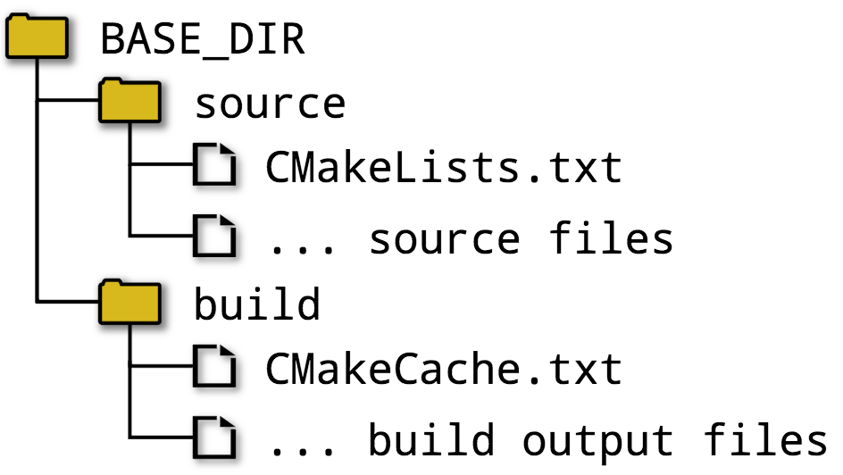

有些开发者采用的变体方法是将构建目录设为源代码目录的子目录。这种方法保留了外部构建的大部分优点，但也存在一些内部构建的缺点。除非有充分的理由，否则建议将构建目录完全放在源代码树之外。

A variation on this used by some developers is to make the build directory a subdirectory of the source directory. This offers most of the advantages of an out-of-source build, but it does still carry with it some of the disadvantages of an in-source arrangement. Unless there is a good reason to structure things that way, keeping the build directory completely outside of the source tree instead is recommended.

## 2.3 生成项目文件

## 2.3. Generating Project Files

Once the choice of directory structure has been made, the developer runs CMake, which reads in the `CMakeLists.txt` file and creates project files in the build directory. The developer selects the type of project file to be created by choosing a particular project file *generator*. A range of different generators are supported, with the more commonly used ones listed in the table below.

[output not shown]

有些生成器生成的项目支持多种配置（例如 Debug、Release 等）。这使得开发者无需重新运行 CMake 即可在不同的构建配置之间进行选择，这更适合那些为 Xcode 和 Visual Studio 等 IDE 环境创建项目的生成器。对于不支持多种配置的生成器，开发者必须重新运行 CMake 才能在 Debug、Release 等构建配置之间切换。这些生成器操作更简单，并且通常在与特定编译器关联性不强的 IDE 环境（例如 Qt Creator、KDevelop 等）中也能得到良好的支持。

Some of the generators produce projects which support multiple configurations (e.g. Debug, Release, etc.). These allow the developer to choose between different build configurations without having to re-run CMake, which is more suitable for generators creating projects for use in IDE environments like Xcode and Visual Studio. For generators which do not support multiple configurations, the developer has to re-run CMake to switch the build between Debug, Release, etc. These are simpler and often have good support in IDE environments not so closely associated with a particular compiler (Qt Creator, KDevelop, etc.).

运行 CMake 最基本的方法是通过`cmake`命令行工具。最简单的调用方式是切换到构建目录，并向`cmake`传递生成器类型和源代码树位置等选项。例如：

The most basic way to run CMake is via the `cmake` command line utility. The simplest way to invoke it is to change to the build directory and pass options to `cmake` for the generator type and location of the source tree. For example:

[output not shown]

如果省略`-G`选项，CMake 将根据宿主平台选择默认生成器类型。如果使用 CMake 3.15 或更高版本，可以通过将 环境变量`CMAKE_GENERATOR`设置为所需的默认值来覆盖此默认值。对于所有生成器类型，CMake 都会执行一系列测试来确定如何设置项目文件。这包括验证编译器是否正常工作、确定支持的编译器特性集以及其他各种任务。在 CMake 完成之前，会记录各种信息，成功时会记录类似以下的行：

If the `-G` option is omitted, CMake will choose a default generator type based on the host platform. If using CMake 3.15 or later, this default can be overridden by setting the `CMAKE_GENERATOR` environment variable to the desired default instead. For all generator types, CMake will carry out a series of tests to determine how to set up the project files. This includes things like verifying that the compilers work, determining the set of supported compiler features and various other tasks. A variety of information will be logged before CMake finishes with lines like the following upon success:

```
配置完成
生成完成
-- 构建文件已写入：/some/path/build
```

以上内容表明，项目文件的创建实际上包含两个步骤：配置和生成。在*配置*阶段，CMake 读取 `CMakeLists.txt`文件并构建整个项目的内部表示。完成此操作后，*生成*阶段会创建项目文件。对于 CMake 的基本用法而言，配置和生成之间的区别并不重要，但在后续章节中，配置和生成的分离将变得至关重要。 第 10 章*“生成器表达式”*将对此进行更详细的介绍。

The above highlights that project file creation actually involves two steps; configuring and generating. During the *configuring* phase, CMake reads in the `CMakeLists.txt` file and builds up an internal representation of the entire project. After this is done, the *generation* phase creates the project files. The distinction between configuring and generating doesn’t matter so much for basic CMake usage, but in later chapters the separation of configuration and generation becomes important. This is covered in more detail in Chapter 10, *Generator Expressions*.

CMake 运行完成后，会在构建目录中保存一个`CMakeCache.txt`文件。CMake 使用此文件保存详细信息，以便在再次运行时可以重用第一次计算的信息，从而加快项目生成速度。正如后续章节所述，它还允许在两次运行之间保存开发人员选项。除了运行`cmake`命令行工具之外，还有一个图形用户界面应用程序`cmake-gui`，但该应用程序的介绍将在第 5 章*“变量”*中更详细地阐述其用途。

When CMake has completed its run, it will have saved a `CMakeCache.txt` file in the build directory. CMake uses this file to save details so that if it is run again, it can re-use information computed the first time and speed up the project generation. As covered in later chapters, it also allows developer options to be saved between runs. A GUI application, `cmake-gui`, is available as an alternative to running the `cmake` command line tool, but the introduction of the GUI application is deferred to Chapter 5, *Variables* where its usefulness is more clearly evident.

## 2.4 运行构建工具

## 2.4. Running The Build Tool

此时，项目文件已准备就绪，开发者可以按照他们习惯的方式使用所选的构建工具。构建目录将包含必要的项目文件，这些文件可以加载到 IDE 中，也可以被命令行工具读取等等。或者，`cmake`可以代表开发者调用构建工具，如下所示：

At this point, with project files now available, the developer can use their selected build tool in the way to which they are accustomed. The build directory will contain the necessary project files which can be loaded into an IDE, read by command line tools, etc. Alternatively, `cmake` can invoke the build tool on the developer’s behalf like so:

```
cmake --build /pathTo/build --config Debug --target MyApp
```

This works even for project types the developer may be more accustomed to using through an IDE like Xcode or Visual Studio. The `--build` option points to the build directory used by the CMake project generation step. For multi configuration generators, the `--config` option specifies which configuration to build, whereas single configuration generators will ignore the `--config` option and rely instead on information provided when the CMake project generation step was performed. Specifying the build configuration is covered in depth in Chapter 14, *Build Type*. The `--target` option can be used to tell the build tool what to build, or if omitted, the default target will be built. With CMake 3.15 or later, multiple targets can be listed after the `--target` option, separated by spaces.

虽然开发人员通常会在日常开发中直接调用他们选择的构建工具，但在驱动自动化构建的脚本中，像上面那样通过`cmake`命令调用它会更加有用。使用这种方法，一个简单的脚本化构建可能如下所示：

While developers will typically invoke their selected build tool directly in day-to-day development, invoking it via the `cmake` command as shown above can be more useful in scripts driving an automated build. Using this approach, a simple scripted build might look something like this:

[output not shown]

如果开发者想要尝试不同的生成器，只需更改CMake 选项`-G`的参数，系统就会自动调用正确的构建工具。构建工具甚至不需要位于用户的`PATH 环境`变量中，`cmake --build`也能正常工作（尽管在首次调用`cmake`时，初始配置步骤可能需要将其添加到 PATH 环境变量中）。

If the developer wishes to experiment with different generators, all that needs to be done is change the argument given to the `-G` CMake option and the correct build tool will be automatically invoked. The build tool doesn’t even have to be on the user’s `PATH` for `cmake --build` to work (although it may need to be for the initial configuration step when `cmake` is first invoked).

## 2.5. 推荐做法

## 2.5. Recommended Practices

即使是 CMake 新手，也建议养成将构建目录与源代码树完全分离的习惯。想要快速体验这种做法的优势，可以尝试为同一个源代码目录设置两个或多个不同的构建。例如，一个构建可以配置为调试模式，另一个配置为发布模式。另一种方法是为不同的构建目录使用不同的项目生成器，例如 Unix Makefile 和 Xcode。这有助于发现对特定构建工具的任何意外依赖，或者检查不同生成器类型之间是否存在不同的编译器设置。

Even when first starting out using CMake, it is advisable to make a habit of keeping the build directory completely separate from the source tree. A good way to get early experience of the benefits of such an arrangement is to set up two or more different builds for the same source directory. One build could be configured with Debug settings, the other for a Release build. Another option is to use different project generators for the different build directories, such as Unix Makefiles and Xcode. This can help to catch any unintended dependencies on a particular build tool or to check for differing compiler settings between generator types.

在项目初期，开发者很容易倾向于只使用一种特定的项目生成器，尤其是在他们不习惯编写跨平台软件的情况下。然而，项目往往会超出最初的预期范围，因此支持其他平台和生成器类型也相当常见。定期使用开发者常用的生成器以外的其他生成器进行构建检查，可以避免在不必要的地方编写特定于生成器的代码，从而节省大量未来的工作时间。这样做的好处还在于，它能让项目更好地适应未来新增的任何生成器类型。一个好的策略是确保项目在每个目标平台上都使用默认生成器类型进行构建，并同时支持另一种生成器类型。Ninja 生成器是后者的绝佳选择，因为它拥有所有生成器中最广泛的平台支持，并且构建效率非常高。如果项目是通过脚本实现的，则应使用 `cmake --build`来调用构建工具，而不是直接调用构建工具本身。这样，脚本就可以轻松地在不同的生成器类型之间切换，而无需进行任何修改。

It can be tempting to focus on using one particular type of project generator in the early stages of a project, especially if the developer is not accustomed to writing cross-platform software. Projects do, however, have a habit of growing beyond their initial scope and it is relatively common to need to support additional platforms and generator types. Periodically checking the build with a different project generator than the one a developer usually uses can save considerable future pain by discouraging generator-specific code where it isn’t required. This also has the benefit of making the project well placed to take advantage of any new generator type in the future. A good strategy is to ensure the project builds with the default generator type on each platform of interest, plus one other type. The Ninja generator is an excellent choice for the latter, since it has the broadest platform support of all the generators and it also creates very efficient builds. If the project is being scripted, invoke the build tool via `cmake --build` instead of invoking the build tool directly. This allows the script to easily switch between generator types without having to be modified.

# 3. 一个极简项目

# 3. A Minimal Project

`所有 CMake 项目都以一个名为CMakeLists.txt`的文件开始，该文件应位于源代码树的根目录。您可以将其视为 CMake 项目文件，它定义了构建过程的方方面面，包括源文件和目标文件，以及测试、打包和其他自定义任务。它可以非常简单，只有几行代码，也可以非常复杂，并从其他目录中引入更多文件。CMakeLists.txt `只是`一个普通的文本文件，通常像项目中的其他源文件一样直接编辑。

All CMake projects start with a file called `CMakeLists.txt` and it is expected to be placed at the top of the source tree. Think of it as the CMake project file, defining everything about the build from sources and targets through to testing, packaging and other custom tasks. It can be as simple as a few lines or it can be quite complex and pull in more files from other directories. `CMakeLists.txt` is just an ordinary text file and is usually edited directly, just like any other source file in the project.

继续沿用源代码的类比，CMake 定义了自己的语言，其中包含许多程序员熟悉的元素，例如变量、函数、宏、条件逻辑、循环、代码注释等等。这些概念和特性将在接下来的几章中详细介绍，但现在，我们的目标仅仅是实现一个简单的构建，以此作为起点。以下是一个简洁且格式良好的`CMakeLists.txt`文件，它可以生成一个基本的可执行文件。

Continuing the analogy with sources, CMake defines its own language which has many things a programmer would be familiar with, such as variables, functions, macros, conditional logic, looping, code comments and so on. These various concepts and features are covered in the next few chapters, but for now, the goal is just to get a simple build working as a starting point. The following is a minimal, well-formed `CMakeLists.txt` file producing a basic executable.

```
cmake_minimum_required(VERSION 3.2)
project(MyApp)
add_executable(MyExe main.cpp)
```

上述示例中的每一行都执行一个内置的 CMake*命令*。在 CMake 中，命令类似于其他语言的函数调用，不同之处在于，虽然它们支持参数，但不会直接返回值（不过，后面的章节会介绍如何以其他方式将值传递回调用者）。参数之间用空格分隔，并且可以跨越多行：

Each line in the above example executes a built-in CMake *command*. In CMake, commands are similar to other languages’ function calls, except that while they support arguments, they do not return values directly (but a later chapter shows how to pass values back to the caller in other ways). Arguments are separated from each other by spaces and may be split across multiple lines:

```
add_executable(MyExe
    main.cpp
    src1.cpp
    src2.cpp
)
```

命令名称不区分大小写，因此以下所有命令都是等效的：

Command names are also case insensitive, so the following are all equivalent:

```
add_executable(MyExe main.cpp)
ADD_EXECUTABLE(MyExe main.cpp)
Add_Executable(MyExe main.cpp)
```

典型风格各不相同，但如今更常见的约定是命令名称全部使用小写字母（这也是 CMake 文档中内置命令所遵循的约定）。

Typical style varies, but the more common convention these days is to use all lowercase for command names (this is also the convention followed by the CMake documentation for built-in commands).

## 3.1. 管理 CMake 版本

## 3.1. Managing CMake Versions

CMake 会持续更新和扩展，以支持新的工具、平台和功能。CMake 的开发者非常注重保持每个新版本之间的向后兼容性，因此当用户更新到更高版本的 CMake 时，项目应该能够像以前一样继续构建。有时，CMake 的某些行为需要更改，或者新版本中可能会引入更严格的检查和警告。CMake 并没有要求所有项目立即进行相应的调整，而是提供了*策略*机制，允许项目指定“行为方式与 CMake 版本 XYZ 相同”。这使得 CMake 能够在内部修复错误并引入新功能的同时，仍然保持与特定历史版本相同的预期行为。

CMake is continually updated and extended to add support for new tools, platforms and features. The developers behind CMake are very careful to maintain backwards compatibility with each new release, so when users update to a newer version of CMake, projects should continue to build as they did before. Sometimes, a particular CMake behavior needs to change or more stringent checks and warnings may be introduced in newer versions. Rather than requiring all projects to immediately deal with this, CMake provides *policy* mechanisms which allow the project to say “Behave like CMake version X.Y.Z”. This allows CMake to fix bugs internally and introduce new features, but still maintain the expected behavior of any particular past release.

项目指定其预期 CMake 版本行为的主要方式是使用`cmake_minimum_required()命令。这应该是``CMakeLists.txt`文件的第一行，以便在执行任何其他操作之前检查并确定项目的依赖项。此命令执行两项操作：

The primary way a project specifies details about its expected CMake version behavior is with the `cmake_minimum_required()` command. This should be the first line of the `CMakeLists.txt` file so that the project’s requirements are checked and established before anything else. This command does two things:

- 它指定了项目所需的最低 CMake 版本。如果 使用低于指定版本的 CMake 处理`CMakeLists.txt文件，则会立即停止并报错。这确保在继续操作之前，必须具备特定的最低 CMake 功能集。`
- It specifies the minimum version of CMake the project needs. If the `CMakeLists.txt` file is processed with a CMake version older than the one specified, it will halt immediately with an error. This ensures that a particular minimum set of CMake functionality is available before proceeding.
- 它强制执行策略设置，使 CMake 的行为与指定的版本相匹配。
- It enforces policy settings to match CMake behavior to the specified version.

使用此命令至关重要，如果 `CMakeLists.txt`文件在任何其他命令之前没有调用`cmake_minimum_required()，` CMake 将发出警告。它需要知道如何为所有后续处理设置策略行为。对于大多数项目，只需将`cmake_minimum_required()` 视为指定所需的最低 CMake 版本即可，正如其名称所示。它还意味着 CMake 的行为应与该特定版本保持一致，这可以被视为一个有用的附加好处。第 12 章*“策略”*更详细地讨论了策略设置，并解释了如何根据需要定制此行为。

Using this command is so important that CMake will issue a warning if the `CMakeLists.txt` file does not call `cmake_minimum_required()` before any other command. It needs to know how to set up the policy behavior for all subsequent processing. For most projects, it is enough to treat `cmake_minimum_required()` as simply specifying the minimum required CMake version, as its name suggests. The fact that it also implies CMake should behave the same as that particular version can be considered a useful side benefit. Chapter 12, *Policies* discusses policy settings in more detail and explains how to tailor this behavior as needed.

`cmake_minimum_required()`命令的典型形式很简单：

The typical form of the `cmake_minimum_required()` command is straightforward:

```
cmake_minimum_required(VERSION major.minor[.patch[.tweak]])
```

VERSION`关键字`必须始终存在，并且提供的版本信息至少应包含`主版本`号.次版本号部分。在大多数项目中，无需指定 `补丁`和`调整`部分，因为新功能通常只出现在次版本更新中（这是 CMake 从 3.0 版本开始的官方行为）。只有当需要修复特定错误时，项目才需要指定`补丁`部分。此外，由于 3.x 系列 CMake 版本均未使用`调整`编号，因此项目也无需指定调整编号。

The `VERSION` keyword must always be present and the version details provided must have at least the `major.minor` part. In most projects, specifying the `patch` and `tweak` parts is not necessary, since new features typically only appear in minor version updates (this is the official CMake behavior from version 3.0 onward). Only if a specific bug fix is needed should a project specify a `patch` part. Furthermore, since no CMake release in the 3.x series has used a `tweak` number, projects should not need to specify one either.

开发者应仔细考虑项目所需的最低 CMake 版本。对于任何新项目而言，3.2 版本或许是可以考虑的最低版本，因为它为现代 CMake 技术提供了相当完整的功能集。2.8.12 版本的功能覆盖范围有所缩减，缺少一些实用功能，但对于较旧的项目来说可能仍然适用。更早的版本则缺少许多重要功能，导致许多现代 CMake 技术无法使用。如果项目涉及 iOS 等快速发展的平台，则可能需要使用较新的 CMake 版本才能支持最新的操作系统版本等。

Developers should think carefully about what minimum CMake version their project should require. Version 3.2 is perhaps the oldest any new project should consider, since it provides a reasonably complete feature set for modern CMake techniques. Version 2.8.12 has a reduced feature coverage, lacking a number of useful features but it may be workable for older projects. Versions before that lack substantial features that would make using many modern CMake techniques impossible. If working with fast-moving platforms such as iOS, quite recent versions of CMake may be needed in order to support the latest OS releases, etc.

一般来说，应选择不会给项目构建者带来重大问题的最新 CMake 版本。最大的困难通常出现在需要支持旧平台的项目上，因为这些平台的系统自带 CMake 版本可能非常旧。对于这种情况，如果可能，开发者应考虑安装更新的版本，而不是局限于非常旧的 CMake 版本。另一方面，如果项目本身是其他项目的依赖项，那么选择更新的 CMake 版本可能会成为其他项目采用的障碍。在这种情况下，或许可以改为要求使用仍然提供所需最低 CMake 功能的最旧版本，但尽可能利用更高版本中的功能（第 12 章*“策略”*介绍了实现此目的的技术）。这将避免其他项目被迫使用超出其目标环境通常允许或提供的版本。依赖项目可以根据需要要求使用更新的版本，但不能要求使用更旧的版本。使用最老的可用版本的主要缺点是可能会导致更多的弃用警告，因为较新的 CMake 版本会警告旧的行为，以鼓励项目自行更新。

As a general rule of thumb, choose the most recent CMake version that won’t present significant problems for those building the project. The greatest difficulty is typically experienced by projects that need to support older platforms where the system-provided version of CMake may be quite old. For such cases, if at all possible, developers should consider installing a more recent release rather than restricting themselves to very old CMake versions. On the other hand, if the project will itself be a dependency for other projects, then choosing a more recent CMake version may present a hurdle for adoption. In such cases, it may be beneficial to instead require the oldest CMake version that still provides the minimum CMake features needed, but make use of features from later CMake versions if available (Chapter 12, *Policies* presents techniques for achieving this). This will prevent other projects from being forced to require a more recent version than their target environment typically allows or provides. Dependent projects can always require a more recent version if they so wish, but they cannot require an older one. The main disadvantage of using the oldest workable version is that it may result in more deprecation warnings, since newer CMake versions will warn about older behaviors to encourage projects to update themselves.

## 3.2. project() 命令

## 3.2. The project() Command

每个 CMake 项目都应该包含一个`project()`命令，并且该命令应该出现在`cmake_minimum_required()`函数之后。该命令及其最常用的选项格式如下：

Every CMake project should contain a `project()` command and it should appear after `cmake_minimum_required()` has been called. The command with its most common options has the following form:

```
project(projectName
        [VERSION major[.minor[.patch[.tweak]]]]
        [LANGUAGES languageName ...]
)
```

项目`名称`是必需的，只能包含字母、数字、下划线 (_) 和连字符 (-)，但实际上通常只使用字母，偶尔也使用下划线。由于不允许使用空格，项目名称无需用引号括起来。在某些项目生成器（例如 Xcode 和 Visual Studio）中，此名称用于项目的顶层名称，它也用于项目的其他各个部分，例如用作打包和文档元数据的默认值、提供项目特定的变量等等。项目名称是 `project()`命令唯一必需的参数。

The `projectName` is required and may only contain letters, numbers, underscores (_) and hyphens (-), although typically only letters and perhaps underscores are used in practice. Since spaces are not permitted, the project name does not have to be surrounded by quotes. This name is used for the top level of a project with some project generators (eg Xcode and Visual Studio) and it is also used in various other parts of the project, such as to act as defaults for packaging and documentation metadata, to provide project-specific variables and so on. The name is the only mandatory argument for the `project()` command.

可选的`VERSION`详细信息仅在 CMake 3.0 及更高版本中受支持。与`projectName`类似，CMake 使用版本详细信息来填充一些变量并作为默认包元数据，除此之外，版本详细信息没有其他意义。尽管如此，养成在此处定义项目版本的好习惯，以便项目的其他部分可以引用它。第 20 章*“指定版本详细信息”*`对此进行了深入讲解，并解释了如何在CMakeLists.txt`文件中引用此版本信息 。

The optional `VERSION` details are only supported in CMake 3.0 and later. Like the `projectName`, the version details are used by CMake to populate some variables and as default package metadata, but other than that, the version details don’t have any other significance. Nonetheless, a good habit to establish is to define the project’s version here so that other parts of the project can refer to it. Chapter 20, *Specifying Version Details* covers this in depth and explains how to refer to this version information later in the `CMakeLists.txt` file.

可选的`LANGUAGES`参数定义了项目中要启用的编程语言。支持的值包括`C`、`CXX`、`Fortran`、 `ASM`、`CUDA`等。如果指定多种语言，请用空格分隔。在某些特殊情况下，项目可能需要指定不使用任何语言，这可以通过`LANGUAGES NONE`来实现。后续章节介绍的技术会利用这种形式。如果未 提供`LANGUAGES选项，CMake 将默认使用``C`和`CXX。CMake` 3.0 之前的版本不支持`LANGUAGES`关键字，但仍然可以在项目名称后使用旧式命令指定语言，如下所示：

The optional `LANGUAGES` argument defines the programming languages that should be enabled for the project. Supported values include `C`, `CXX`, `Fortran`, `ASM`, `CUDA` and others. If specifying multiple languages, separate each with a space. In some special situations, projects may want to indicate that no languages are used, which can be done using `LANGUAGES NONE`. Techniques introduced in later chapters take advantage of this particular form. If no `LANGUAGES` option is provided, CMake will default to `C` and `CXX`. CMake versions prior to 3.0 do not support the `LANGUAGES` keyword, but languages can still be specified after the project name using the older form of the command like so:

```
project(MyProj C CXX)
```

鼓励新项目指定 CMake 版本至少为 3.0，并使用带有`LANGUAGES`关键字的新格式。

New projects are encouraged to specify a minimum CMake version of at least 3.0 and use the new form with the `LANGUAGES` keyword instead.

project `()`命令的功能远不止填充几个变量。它的重要职责之一是检查每种已启用语言的编译器，确保它们能够成功编译和链接。这样，编译器和链接器配置方面的问题就能被及早发现。一旦这些检查通过，CMake 就会设置一些变量和属性来控制已启用语言的构建。 第 22 章*“工具链和交叉编译”*对此进行了更详细的讨论，包括影响工具链选择和配置的各种方法。 第 7 章*“使用子目录”*`也讨论了影响project()`命令使用的其他注意事项和要求。

The `project()` command does much more than just populate a few variables. One of its important responsibilities is to check the compilers for each enabled language and ensure they are able to compile and link successfully. Problems with the compiler and linker setup are then caught very early. Once these checks have passed, CMake sets up a number of variables and properties which control the build for the enabled languages. Chapter 22, *Toolchains And Cross Compiling* discusses this area in much greater detail, including the various ways to influence toolchain selection and configuration. Chapter 7, *Using Subdirectories* also discusses additional considerations and requirements that affect the use of the `project()` command.

当 CMake 执行的编译器和链接器检查成功时，其结果会被缓存，这样在后续的 CMake 运行中就无需重复执行。这些缓存信息存储在构建目录下的 `CMakeCache.txt`文件中。关于这些检查的更多详细信息可以在构建目录下的子目录中找到，但通常只有在使用新的或不常见的编译器，或者为交叉编译设置工具链文件时，开发人员才需要查看这些子目录。

When the compiler and linker checks performed by CMake are successful, their results are cached so that they do not have to be repeated in subsequent CMake runs. These cached details are stored in the build directory in the `CMakeCache.txt` file. Additional details about the checks can be found in subdirectories within the build area, but developers would typically only need to look there if working with a new or unusual compiler or when setting up toolchain files for cross-compiling.

## 3.3 构建基本可执行文件

## 3.3. Building A Basic Executable

为了完善我们的最小示例， `add_executable()`命令指示 CMake 从一组源文件创建一个可执行文件。该命令的基本形式为：

To complete our minimal example, the `add_executable()` command tells CMake to create an executable from a set of source files. The basic form of this command is:

```
add_executable(targetName source1 [source2 ...])
```

`这将创建一个可执行文件，该文件可在 CMake 项目中以targetName 的形式`引用 。此名称可以包含字母、数字、下划线和连字符。构建项目时，将在构建目录中创建一个可执行文件，其名称与平台相关，默认名称基于目标名称。请看以下简单的示例命令：

This creates an executable which can be referred to within the CMake project as `targetName`. This name may contain letters, numbers, underscores and hyphens. When the project is built, an executable will be created in the build directory with a platform-dependent name, the default name being based on the target name. Consider the following simple example command:

```
add_executable(MyApp main.cpp)
```

默认情况下，Windows 系统上的可执行文件名称为`MyApp.exe`，而 macOS、Linux 等类 Unix 平台上的可执行文件名称为 `MyApp。可执行文件名称可以通过目标属性进行自定义，这是 CMake 的一个特性`，在第 9 章*“属性”*`中有所介绍。也可以在同一个CMakeLists.txt`文件中定义多个可执行文件， 只需多次调用`add_executable()`并使用不同的目标名称即可。如果在多个 `add_executable()`命令中使用相同的目标名称，CMake 将报错并突出显示错误信息。

By default, the name of the executable would be `MyApp.exe` on Windows and `MyApp` on Unix-based platforms like macOS, Linux, etc. The executable name can be customized with target properties, a CMake feature introduced in Chapter 9, *Properties*. Multiple executables can also be defined within the one `CMakeLists.txt` file by calling `add_executable()` multiple times with different target names. If the same target name is used in more than one `add_executable()` command, CMake will fail and highlight the error.

## 3.4 评论

## 3.4. Commenting

在结束本章之前，有必要演示一下如何在`CMakeLists.txt`文件中添加注释。本书中会大量使用注释，我们鼓励开发者养成为项目添加注释的习惯，就像为普通源代码添加注释一样。CMake 遵循与 Unix shell 脚本类似的注释约定。任何以 # 字符开头的行都被视为注释。除了带引号的字符串之外，`CMakeLists.txt`文件中每行 # 字符之后的所有内容也都被视为注释。以下是一些注释示例，并总结了本章介绍的概念：

Before leaving this chapter, it will be useful to demonstrate how to add comments to a `CMakeLists.txt` file. Comments are used extensively throughout this book and developers are encouraged to also get into the habit of commenting their projects just as they would for ordinary source code. CMake follows similar commenting conventions as Unix shell scripts. Any line beginning with a # character is treated as a comment. Except within a quoted string, anything after a # on a line within a `CMakeLists.txt` file is also treated as a comment. The following shows a few comment examples and brings together the concepts introduced in this chapter:

```
cmake_minimum_required(VERSION 3.2)

# We don't use the C++ compiler, so don't let project()
# test for it in case the platform doesn't have one
project(MyApp VERSION 4.7.2 LANGUAGES C)

# Primary tool for this project
add_executable(MainTool
    main.c
    debug.c   # Optimized away for release builds
)

# Helpful diagnostic tool for development and testing
add_executable(TestTool testTool.c)
```

## 3.5. 推荐做法

## 3.5. Recommended Practices

确保每个 CMake 项目的根目录下的`CMakeLists.txt`文件的第一行都包含 `cmake_minimum_required()`命令。在确定所需的最低版本号时，请记住，版本越高，项目能够使用的 CMake 功能就越多。这也意味着项目更有可能更好地适应新的平台或操作系统版本，因为这些版本不可避免地会给构建系统带来新的挑战。相反，如果创建的项目旨在作为操作系统的一部分进行构建和分发（这在 Linux 系统中很常见），则最低 CMake 版本很可能取决于该发行版提供的 CMake 版本。

Ensure every CMake project has a `cmake_minimum_required()` command as the first line of its top level `CMakeLists.txt` file. When deciding the minimum required version number to specify, keep in mind that the later the version, the more CMake features the project will be able to use. It will also mean the project is likely to be better placed to adapt to new platform or operating system releases, which inevitably introduce new things for build systems to deal with. Conversely, if creating a project intended to be built and distributed as part of the operating system itself (common for Linux), the minimum CMake version is likely to be dictated by the version of CMake provided by that same distribution.

如果项目可能需要 CMake 3.0 或更高版本，最好尽早考虑项目版本号，并尽快将版本号集成到 `project()`命令中。在项目后期，要克服现有流程的惯性并改变版本号的处理方式可能非常困难。 在制定版本控制策略时，可以考虑[语义化版本控制等常用实践。](http://semver.org/)

If the project can require CMake 3.0 or later, it is also good to force thinking about project version numbers early and start incorporating version numbering into the `project()` command as soon as possible. It can be very hard to overcome the inertia of existing processes and change how version numbers are handled later in the life of a project. Consider popular practices such as [Semantic Versioning](http://semver.org) when deciding on a versioning strategy.

# 4. 制定简单的目标

# 4. Building Simple Targets

如前一章所示，在 CMake 中定义一个简单的可执行文件相对容易。前面给出的简单示例只需要为可执行文件定义一个目标名称，并列出要编译的源文件即可：

As shown in the previous chapter, it is relatively straightforward to define a simple executable in CMake. The simple example given previously required defining a target name for the executable and listing the source files to be compiled:

```
add_executable(MyApp main.cpp)
```

这假设开发者希望构建一个基本的控制台可执行文件，但 CMake 也允许开发者定义其他类型的可执行文件，例如 Apple 平台上的应用程序包和 Windows GUI 应用程序。本章将讨论可以传递给`add_executable() 函数`的其他选项，以指定这些细节。

This assumes the developer wants a basic console executable to be built, but CMake also allows the developer to define other types of executables, such as app bundles on Apple platforms and Windows GUI applications. This chapter discusses additional options which can be given to `add_executable()` to specify these details.

除了可执行文件之外，开发人员也经常需要构建和链接库。CMake 支持多种不同类型的库，包括静态库、共享库、模块和框架。CMake 还提供了非常强大的功能来管理目标之间的依赖关系以及库的链接方式。本章主要内容将围绕库以及如何在 CMake 中使用库展开。本书后续章节将广泛运用此处介绍的概念。此外，本章还会介绍一些变量和属性的基本用法，以帮助读者了解这些 CMake 功能与库和目标之间的关系。

In addition to executables, developers also frequently need to build and link libraries. CMake supports a few different kinds of libraries, including static, shared, modules and frameworks. CMake also offers very powerful features for managing dependencies between targets and how libraries are linked. This whole area of libraries and how to work with them in CMake forms the bulk of this chapter. The concepts covered here are used extensively throughout the remainder of this book. Some very basic use of variables and properties are also given to provide a flavor for how these CMake features relate to libraries and targets in general.

## 4.1. 可执行文件

## 4.1. Executables

更完整的基本`add_executable()`命令如下所示：

The more complete form of the basic `add_executable()` command is as follows:

```
add_executable(targetName [WIN32] [MACOSX_BUNDLE]
               [EXCLUDE_FROM_ALL]
               source1 [source2 ...]
)
```

与之前所示的表单相比，唯一的区别在于新增了可选关键字。

The only differences to the form shown previously are the new optional keywords.

**`WIN32`**

**`WIN32`**

在 Windows 平台上构建可执行文件时，此选项指示 CMake 将可执行文件构建为 Windows GUI 应用程序。实际上，这意味着它将使用`WinMain()`入口点而不是`main()`，并且会使用`/SUBSYSTEM:WINDOWS`选项进行链接。在所有其他平台上，`WIN32`选项将被忽略。

When building the executable on a Windows platform, this option instructs CMake to build the executable as a Windows GUI application. In practice, this means it will be created with a `WinMain()` entry point instead of just `main()` and it will be linked with the `/SUBSYSTEM:WINDOWS` option. On all other platforms, the `WIN32` option is ignored.

**`MACOSX_BUNDLE`**

**`MACOSX_BUNDLE`**

如果启用此选项，CMake 会在 Apple 平台上构建应用时生成应用包。与选项名称暗示的不同，它不仅适用于 macOS，也适用于其他 Apple 平台，例如 iOS。此选项的具体效果在不同平台上略有差异。例如，在 macOS 上，应用包的目录结构非常特定，而在 iOS 上，目录结构则较为扁平。CMake 还会为应用包生成一个基本的`Info.plist文件。这些以及其他细节将在`23.2 节“应用包”中详细介绍。在非 Apple 平台上，`MACOSX_BUNDLE`关键字将被忽略。

When present, this option directs CMake to build an app bundle when building on an Apple platform. Contrary to what the option name suggests, it applies not just to macOS, but also to other Apple platforms like iOS as well. The exact effects of this option vary somewhat between platforms. For example, on macOS, the app bundle layout has a very specific directory structure, whereas on iOS, the directory structure is flattened. CMake will also generate a basic `Info.plist` file for bundles. These and other details are covered in more detail in Section 23.2, “Application Bundles”. On non-Apple platforms, the `MACOSX_BUNDLE` keyword is ignored.

**`排除所有`**

**`EXCLUDE_FROM_ALL`**

有时，一个项目会定义多个目标，但默认情况下只会构建其中的一部分。如果在构建时未指定目标，则会构建默认的`ALL`目标（根据所使用的 CMake 生成器，名称可能略有不同，例如Xcode 中的`ALL_BUILD ）。如果使用``EXCLUDE_FROM_ALL`选项定义了可执行文件，则该文件将不会包含在默认的`ALL目标中。只有当构建命令显式请求该可执行文件，或者它是包含在默认``ALL`构建中的其他目标的依赖项时，才会构建该可执行文件。将目标从`ALL`中排除的一个常见情况是，当可执行文件是一个仅偶尔需要的开发工具时。

Sometimes, a project defines a number of targets, but by default only some of them should be built. When no target is specified at build time, the default `ALL` target is built (depending on the CMake generator being used, the name may be slightly different, such as `ALL_BUILD` for Xcode). If an executable is defined with the `EXCLUDE_FROM_ALL` option, it will not be included in that default `ALL` target. The executable will then only be built if it is explicitly requested by the build command or if it is a dependency for another target that is part of the default `ALL` build. A common situation where it can be useful to exclude a target from `ALL` is where the executable is a developer tool that is only needed occasionally.

除了上述形式之外，`add_executable()` 命令还有其他形式，它们会生成对现有可执行文件或目标的引用，而不是定义一个要构建的新文件。这些别名可执行文件将在第 17 章*“目标类型”*中详细介绍。

In addition to the above, there are other forms of the `add_executable()` command which produce a kind of reference to an existing executable or target rather than defining a new one to be built. These alias executables are covered in detail in Chapter 17, *Target Types*.

## 4.2. 定义库

## 4.2. Defining Libraries

创建简单的可执行文件是任何构建系统的基本需求。对于许多大型项目而言，创建和使用库的能力对于保持项目的可管理性也至关重要。CMake 支持构建各种不同类型的库，能够处理许多平台差异，同时仍然支持每个平台的原生特性。库目标使用 `add_library()`命令定义，该命令有多种形式。其中最基本的如下：

Creating simple executables is a fundamental need of any build system. For many larger projects, the ability to create and work with libraries is also essential to keep the project manageable. CMake supports building a variety of different kinds of libraries, taking care of many of the platform differences, but still supporting the native idiosyncrasies of each. Library targets are defined using the `add_library()` command, of which there are a number of forms. The most basic of these is the following:

```
add_library(targetName [STATIC | SHARED | MODULE]
            [EXCLUDE_FROM_ALL]
            source1 [source2 ...]
)
```

This form is analogous to how `add_executable()` is used to define a simple executable. The `targetName` is used within the `CMakeLists.txt` file to refer to the library, with the name of the built library on the file system being derived from this name by default. The `EXCLUDE_FROM_ALL` keyword has exactly the same effect as it does for `add_executable()`, namely to prevent the library from being included in the default `ALL` target. The type of library to be built is specified by one of the remaining three keywords `STATIC`, `SHARED` or `MODULE`.

**`静止的`**

**`STATIC`**

指定静态库或归档文件。在 Windows 上，默认库名称为`targetName.lib`，而在类 Unix 平台上，通常为`libtargetName.a`。

Specifies a static library or archive. On Windows, the default library name would be `targetName.lib`, while on Unix-like platforms, it would typically be `libtargetName.a`.

**`共享`**

**`SHARED`**

指定共享库或动态链接库。在 Windows 系统中，默认库名称为`targetName.dll`；在 Apple 平台上，库名称为 `libtargetName.dylib`；在其他类 Unix 平台上，库名称通常为 `libtargetName.so`。在 Apple 平台上，共享库也可以标记为框架，该主题将在第 23.3 节“框架”中介绍。

Specifies a shared or dynamically linked library. On Windows, the default library name would be `targetName.dll`, on Apple platforms it would be `libtargetName.dylib` and on other Unix-like platforms it would typically be `libtargetName.so`. On Apple platforms, shared libraries can also be marked as frameworks, a topic covered in Section 23.3, “Frameworks”.

**`模块`**

**`MODULE`**

指定一个类似于共享库的库，但它旨在运行时动态加载，而不是直接链接到库或可执行文件。这些通常是插件或可选组件，用户可以选择加载或不加载。在 Windows 平台上，不会为 DLL 创建导入库。

Specifies a library that is somewhat like a shared library, but is intended to be loaded dynamically at run-time rather than being linked directly to a library or executable. These are typically plugins or optional components the user may choose to be loaded or not. On Windows platforms, no import library is created for the DLL.

可以省略定义要构建的库类型的关键字。除非项目明确要求特定类型的库，否则建议不要指定，而是让开发者在构建项目时自行选择。在这种情况下，库要么是 `静态库（STATIC）` ，要么是`共享库（SHARED） ，具体选择取决于名为``BUILD_SHARED_LIBS`的 CMake 变量的值。如果`BUILD_SHARED_LIBS`设置为 `true ，则目标库将是共享库；否则，目标库将是静态库。`第 5 章*“变量”*将详细介绍如何使用变量，但现在，设置此变量的一种方法是，在`cmake命令行中添加``-D`选项， 如下所示：

It is possible to omit the keyword defining what type of library to build. Unless the project specifically requires a particular type of library, the preferred practice is to not specify it and leave the choice up to the developer when building the project. In such cases, the library will be either `STATIC` or `SHARED`, with the choice determined by the value of a CMake variable called `BUILD_SHARED_LIBS`. If `BUILD_SHARED_LIBS` has been set to `true`, the library target will be a shared library, otherwise it will be static. Working with variables is covered in detail in Chapter 5, *Variables*, but for now, one way to set this variable is by including a `-D` option on the `cmake` command line like so:

```
cmake -DBUILD_SHARED_LIBS=YES /path/to/source
```

也可以在`CMakeLists.txt文件中进行设置，方法是在任何``add_library()`命令之前添加以下内容，但这将要求开发人员在想要更改时对其进行修改（即灵活性较低）：

It could be set in the `CMakeLists.txt` file instead with the following placed before any `add_library()` commands, but that would then require developers to modify it if they wanted to change it (i.e. it would be less flexible):

```
set(BUILD_SHARED_LIBS YES)
```

与可执行文件类似，库目标也可以定义为引用现有的二进制文件或目标，而不是由项目自行构建。此外，还支持另一种伪库类型，用于收集目标文件而无需创建静态库。这些内容将在第 17 章*“目标类型”*中详细讨论。

Just as for executables, library targets can also be defined to refer to some existing binary or target rather than being built by the project. Another type of pseudo-library is also supported for collecting together object files without going as far as creating a static library. These are all discussed in detail in Chapter 17, *Target Types*.

## 4.3. 连接目标

## 4.3. Linking Targets

在考虑构成项目的目标时，开发人员通常习惯于这样一种思维模式：库 A 需要库 B，因此 A 与 B 相关联。这是看待库管理的传统方式，其中库之间依赖关系的概念非常简单。然而，实际上，库之间可能存在几种不同类型的依赖关系：

When considering the targets that make up a project, developers are typically used to thinking in terms of library A needing library B, so A is linked to B. This is the traditional way of looking at library handling, where the idea of one library needing another is very simplistic. In reality, however, there are a few different types of dependency relationships that can exist between libraries:

**`私人的`**

**`PRIVATE`**

私有依赖项指定库 A 在其内部实现中使用了库 B。任何其他链接到库 A 的库都不需要了解库 B，因为它只是库 A 的内部实现细节。

Private dependencies specify that library A uses library B in its own internal implementation. Anything else that links to library A doesn’t need to know about B because it is an internal implementation detail of A.

**`民众`**

**`PUBLIC`**

公共依赖关系表明，库 A 不仅在内部使用库 B，而且在其接口中也使用了 B。这意味着 A 不能脱离 B 而独立使用，因此任何使用 A 的代码都将直接依赖于 B。例如，库 A 中定义的一个函数可能至少有一个参数的类型是在库 B 中定义和实现的，因此，代码无法在不提供类型来自 B 的参数的情况下从 A 调用该函数。

Public dependencies specify that not only does library A use library B internally, it also uses B in its interface. This means that A cannot be used without B, so anything that uses A will also have a direct dependency on B. An example of this would be a function defined in library A which has at least one parameter of a type defined and implemented in library B, so code cannot call the function from A without providing a parameter whose type comes from B.

**`界面`**

**`INTERFACE`**

接口依赖关系规定，要使用库 A，也必须使用库 B 的部分内容。这与公共依赖关系不同，因为库 A 内部并不依赖 B，它只是在其接口中使用 B。当使用 `add_library() 的``INTERFACE`形式定义库目标时，这种依赖关系非常有用，例如，当使用目标来表示仅包含头文件的库的依赖关系时（参见第 17.2.4 节，“接口库”）。

Interface dependencies specify that in order to use library A, parts of library B must also be used. This differs from a public dependency in that library A doesn’t require B internally, it only uses B in its interface. An example of where this is useful is when working with library targets defined using the `INTERFACE` form of `add_library()`, such as when using a target to represent a header-only library’s dependencies (see Section 17.2.4, “Interface Libraries”).

`CMake 通过其 target_link_libraries()`命令来捕捉这种更丰富的依赖关系 ，而不仅仅是简单的链接概念。该命令的一般形式为：

CMake captures this richer set of dependency relationships with its `target_link_libraries()` command, not just the simplistic idea of needing to link. The general form of the command is:

```
target_link_libraries(targetName
     <PRIVATE|PUBLIC|INTERFACE> item1 [item2 ...]
    [<PRIVATE|PUBLIC|INTERFACE> item3 [item4 ...]]
    ...
)
```

这使得项目能够精确定义一个库如何依赖于其他库。CMake 会负责管理以这种方式链接的整个库链中的依赖关系。例如，考虑以下情况：

This allows projects to precisely define how one library depends on others. CMake then takes care of managing the dependencies throughout the chain of libraries linked in this fashion. For example, consider the following:

```
add_library(Collector src1.cpp)
add_library(Algo src2.cpp)
add_library(Engine src3.cpp)
add_library(Ui src4.cpp)
add_executable(MyApp main.cpp)

target_link_libraries(Collector
    PUBLIC  Ui
    PRIVATE Algo Engine
)
target_link_libraries(MyApp PRIVATE Collector)
```

在这个例子中，`Ui`库以 `PUBLIC`方式链接到`Collector`库，因此即使`MyApp`只直接链接到`Collector`，由于这种`PUBLIC关系，``MyApp` 也会链接到`Ui`。另一方面，`Algo` 和`Engine`库以 `PRIVATE方式链接到``Collector`，因此`MyApp`不会直接链接到它们。 第 17.2 节“库”讨论了静态库的其他行为，这些行为可能会导致进一步的链接以满足依赖关系，包括循环依赖。

In this example, the `Ui` library is linked to the `Collector` library as `PUBLIC`, so even though `MyApp` only directly links to `Collector`, `MyApp` will also be linked to `Ui` because of that `PUBLIC` relationship. The `Algo` and `Engine` libraries, on the other hand, are linked to `Collector` as `PRIVATE`, so `MyApp` will not be directly linked to them. Section 17.2, “Libraries” discusses additional behaviors for static libraries which may result in further linking to satisfy dependency relationships, including cyclic dependencies.

后续章节介绍了一些其他的`target_…()命令，这些命令进一步增强了目标之间传递的依赖关系信息。当目标通过``target_link_libraries()`连接时，这些命令允许编译器/链接器标志和头文件搜索路径从一个目标传递到另一个目标。这些特性从 CMake 2.8.11 到 3.2 逐步添加，使得`CMakeLists.txt`文件更加简洁健壮。

Later chapters present a few other `target_…()` commands which further enhance the dependency information carried between targets. These allow compiler/linker flags and header search paths to also carry through from one target to another when they are connected by `target_link_libraries()`. These features were added progressively from CMake 2.8.11 through to 3.2 and lead to considerably simpler and more robust `CMakeLists.txt` files.

后续章节还会讨论更复杂的源目录层次结构的使用。在这种情况下，如果使用 CMake 3.12 或更早版本，则与`target_link_libraries()` 一起使用的`targetName必须由调用 target_link_libraries``(``)`的同一目录中的 add_executable()或`add_library()`命令定义 （此限制在 CMake 3.13 中已移除）。

Later chapters also discuss the use of more complex source directory hierarchies. In such cases, if using CMake 3.12 or earlier, the `targetName` used with `target_link_libraries()` must have been defined by an `add_executable()` or `add_library()` command in the same directory from which `target_link_libraries()` is being called (this restriction was removed in CMake 3.13).

## 4.4. 关联非目标

## 4.4. Linking Non-targets

在前一节中，所有链接的项都是现有的 CMake 目标，但`target_link_libraries()`命令比这更灵活。除了 CMake 目标之外，`target_link_libraries()`命令还可以指定以下内容作为链接项：

In the preceding section, all the items being linked to were existing CMake targets, but the `target_link_libraries()` command is more flexible than that. In addition to CMake targets, the following things can also be specified as items in a `target_link_libraries()` command:

**库文件的完整路径**

**Full path to a library file**

CMake 会将库文件添加到链接器命令中。如果库文件发生更改，CMake 会检测到该更改并重新链接目标。请注意，从 CMake 3.3 版本开始，链接器命令始终使用指定的完整路径，但在 3.3 版本之前，在某些情况下，CMake 可能会要求链接器搜索库文件（例如，将 `/usr/lib/` libfoo.so 替换为`-lfoo ）。3.3 版本之前的行为背后的原因和细节较为复杂，且主要属于历史遗留问题，但感兴趣的读者可以在 CMake 文档的``CMP0060`策略下找到完整的信息。

CMake will add the library file to the linker command. If the library file changes, CMake will detect that change and re-link the target. Note that from CMake version 3.3, the linker command always uses the full path specified, but prior to version 3.3, there were some situations where CMake may ask the linker to search for the library instead (e.g. replace `/usr/lib/libfoo.so` with `-lfoo`). The reasoning and details of the pre-3.3 behavior are non-trivial and are largely historical, but for the interested reader, the full set of information is available in the CMake documentation under the `CMP0060` policy.

**普通库名称**

**Plain library name**

如果只指定库名称而没有路径，链接器命令会查找该库（例如，`foo`会变成`-lfoo`或 `foo.lib`，具体取决于平台）。这对于系统提供的库来说很常见。

If just the name of the library is given with no path, the linker command will search for that library (e.g. `foo` becomes `-lfoo` or `foo.lib`, depending on the platform). This would be common for libraries provided by the system.

**链接标志**

**Link flag**

特殊情况下，除`-l`或 `-framework`之外，以连字符开头的项将被视为标志，添加到链接器命令中。CMake 文档警告说，这些标志只能用于`私有项，因为如果定义为``公共`或 `接口项`，它们会被传递到其他目标，这可能并不总是安全的。

As a special case, items starting with a hyphen other than `-l` or `-framework` will be treated as flags to be added to the linker command. The CMake documentation warns that these should only be used for `PRIVATE` items, since they would be carried through to other targets if defined as `PUBLIC` or `INTERFACE` and this may not always be safe.

除了上述内容之外，出于历史原因，任何条目都可以以关键字 `debug`、`optimized`或`general开头。这些关键字的作用是根据构建是否配置为调试构建（参见`第 14 章*“构建类型*”）进一步细化其后条目的包含时机 。如果条目以关键字`debug`开头，则仅在构建为调试构建时才会添加该条目。如果条目以 关键字`optimized`开头，则仅在构建不是调试构建时才会添加该条目。关键字`general`指定该条目应添加到所有构建配置中，这本身就是未使用任何关键字时的默认行为。对于新项目，应避免使用 `debug`、`optimized`和`general`关键字，因为使用当前的 CMake 功能，可以以更清晰、更灵活、更健壮的方式实现相同的功能。

In addition to the above, for historical reasons, any item may be preceded by one of the keywords `debug`, `optimized` or `general`. The effect of these keywords is to further refine when the item following it should be included based on whether or not the build is configured as a debug build (see Chapter 14, *Build Type*). If an item is preceded by the `debug` keyword, then it will only be added if the build is a debug build. If an item is preceded by the `optimized` keyword, it will only be added if the build is not a debug build. The `general` keyword specifies that the item should be added for all build configurations, which is the default behavior anyway if no keyword is used. The `debug`, `optimized` and `general` keywords should be avoided for new projects as there are clearer, more flexible and more robust ways to achieve the same thing with today’s CMake features.

## 4.5. 旧式 CMake

## 4.5. Old-style CMake

target_link_libraries `()`命令还有其他几种形式，其中一些早在 CMake 2.8.11 版本之前就已存在。本文讨论这些形式是为了便于理解较早的 CMake 项目，但通常不建议在新项目中使用它们。建议使用前面展示的包含`PRIVATE`、`PUBLIC`和`INTERFACE`部分的完整形式，因为它能更准确地表达依赖关系的性质。

The `target_link_libraries()` command also has a few other forms, some of which have been part of CMake from well before version 2.8.11. These forms are discussed here for the benefit of understanding older CMake projects, but their use is generally discouraged for new projects. The full form shown previously with `PRIVATE`, `PUBLIC` and `INTERFACE` sections should be preferred, as it expresses the nature of dependencies with more accuracy.

```
target_link_libraries(targetName item [item...])
```

上述形式通常等同于将项目定义为`PUBLIC`，但在某些情况下，它们也可能被视为`PRIVATE`。特别是，如果一个项目定义了一个库依赖链，其中混合使用了新旧两种形式的命令，则通常会将旧式形式视为`PRIVATE`。

The above form is generally equivalent to the items being defined as `PUBLIC`, but in certain situations, they may instead be treated as `PRIVATE`. In particular, if a project defines a chain of library dependencies with a mix of both old and new forms of the command, the old-style form will generally be treated as `PRIVATE`.

另一种受支持但已弃用的形式如下：

Another supported but deprecated form is the following:

```
target_link_libraries(targetName
    LINK_INTERFACE_LIBRARIES item [item...]
)
```

`这是上文所述新版INTERFACE`关键字的前身，但 CMake 文档不建议使用它。它的行为可能会影响不同的目标属性，而策略设置控制着这些行为。这可能会给开发人员带来困惑，而使用新版`INTERFACE`关键字可以避免这种情况。

This is a pre-cursor to the `INTERFACE` keyword of the newer form covered above, but its use is discouraged by the CMake documentation. Its behavior can affect different target properties, with the policy settings controlling that behavior. This is a potential source of confusion for developers which can be avoided by using the newer `INTERFACE` form instead.

```
target_link_libraries(targetName
    <LINK_PRIVATE|LINK_PUBLIC> lib [lib...]
   [<LINK_PRIVATE|LINK_PUBLIC> lib [lib...]]
)
```

`与之前的旧式形式类似，这种形式是新式PRIVATE`和`PUBLIC`关键字形式的前身 。同样，旧式形式在影响目标属性方面存在混淆，因此 对于新项目，应优先选择`PRIVATE` / `PUBLIC关键字形式。`

Similar to the previous old-style form, this one is a pre-cursor to the `PRIVATE` and `PUBLIC` keyword versions of the newer form. Again, the old-style form has the same confusion over which target properties it affects and the `PRIVATE`/`PUBLIC` keyword form should be preferred for new projects.

## 4.6 推荐做法

## 4.6. Recommended Practices

目标名称不必与项目名称相关。常见的做法是，教程和示例中使用一个变量来存储项目名称，并将该变量复用于可执行目标的名称，如下所示：

Target names need not be related to the project name. It is common to see tutorials and examples use a variable for the project name and reuse that variable for the name of an executable target like so:

```
# Poor practice, but very common
set(projectName MyExample)
project(${projectName})
add_executable(${projectName} ...)
```

这种方法只适用于最基本的项目，而且会养成一些坏习惯。即使项目名称和可执行文件名称最初相同，也应该将它们视为两个独立的名称。直接设置项目名称，而不是通过变量；根据目标的功能而不是它所属的项目来选择目标名称；并假设项目最终需要定义多个目标。这有助于养成良好的习惯，这在处理更复杂的多目标项目时至关重要。

This only works for the most basic of projects and encourages a number of bad habits. Consider the project name and executable name as being separate, even if initially they start out the same. Set the project name directly rather than via a variable, choose a target name according to what the target does rather than the project it is part of and assume the project will eventually need to define more than one target. This reinforces better habits which will be important when working on more complex multi-target projects.

为库目标命名时，请避免以`“lib”`开头或结尾。在许多平台上（几乎所有平台，Windows 除外），构建实际库名称时会自动添加前缀`“lib”`，以使其符合平台的命名规范。如果目标名称已经以`“lib”`开头，则生成的库文件名将采用`“liblibsomething…”`的形式，这常常被误认为是错误。

When naming targets for libraries, resist the temptation to start or end the name with `lib`. On many platforms (i.e. just about all except Windows), a leading `lib` will be prefixed automatically when constructing the actual library name to make it conform to the platform’s usual convention. If the target name already begins with `lib`, the resultant library file names end up with the form `liblibsomething….`, which people often assume to be a mistake.

除非有充分的理由，否则应尽量避免在确定需要之前为库指定`STATIC` 或`SHARED关键字。这样可以更灵活地选择静态库或动态库，作为项目整体策略的一部分。可以使用``BUILD_SHARED_LIBS`变量在一个地方更改默认值，而无需修改每次调用 `add_library()`函数。

Unless there are strong reasons to do so, try to avoid specifying the `STATIC` or `SHARED` keyword for a library until it is known to be needed. This allows greater flexibility in choosing between static or dynamic libraries as an overall project-wide strategy. The `BUILD_SHARED_LIBS` variable can be used to change the default in one place instead of having to modify every call to `add_library()`.

调用 `target_link_libraries()` 命令时，务必始终指定`PRIVATE`、`PUBLIC`和/或`INTERFACE`关键字，而不是沿用旧式 CMake 语法（该语法假定所有内容均为`PUBLIC`）。随着项目复杂性的增加，这三个关键字对目标间依赖关系的处理方式影响更大。从项目伊始就使用它们，还能迫使开发人员思考目标之间的依赖关系，从而有助于更早地发现项目中的结构性问题。

Aim to always specify `PRIVATE`, `PUBLIC` and/or `INTERFACE` keywords when calling the `target_link_libraries()` command rather than following the old-style CMake syntax which assumed everything was `PUBLIC`. As a project grows in complexity, these three keywords have a stronger impact on how inter-target dependencies are handled. Using them from the beginning of a project also forces developers to think about the dependencies between targets, which can help to highlight structural problems within the project much earlier.

# 5. 变量

# 5. Variables

前几章介绍了如何定义基本目标并生成构建输出。这些功能本身已经非常实用，但 CMake 还提供了许多其他特性，带来了极大的灵活性和便利性。本章将介绍 CMake 最基础的部分之一：变量的使用。

The preceding chapters showed how to define basic targets and produce build outputs. On its own, this is already useful, but CMake comes with a whole host of other features which bring great flexibility and convenience. This chapter covers one of the most fundamental parts of CMake, namely the use of variables.

## 5.1. 变量基础知识

## 5.1. Variable Basics

与任何计算机语言一样，变量是 CMake 中实现任务的基石。定义变量最基本的方法是使用`set()命令。普通变量可以在``CMakeLists.txt`文件中按如下方式定义：

Like any computing language, variables are a cornerstone of getting things done in CMake. The most basic way of defining a variable is with the `set()` command. A normal variable can be defined in a `CMakeLists.txt` file as follows:

```
set(varName value... [PARENT_SCOPE])
```

变量名`varName`可以包含字母、数字和下划线，字母区分大小写。变量名也可以包含`./-+`等字符，但这些字符在实际应用中很少见。其他字符也可以通过间接方式使用，但同样，这些字符在正常使用中也不常见。

The name of the variable, `varName`, can contain letters, numbers and underscores, with letters being case-sensitive. The name may also contain the characters `./-+` but these are rarely seen in practice. Other characters are also possible via indirect means, but again, these are not typically seen in normal use.

在 CMake 中，变量具有特定的作用域，这与其他语言中变量的作用域限定于特定函数、文件等类似。变量在其作用域之外无法被读取或修改。与其他语言相比，CMake 中的变量作用域更加灵活，但目前在本章的简单示例中，请将变量的作用域视为全局作用域。 第 7 章“*使用子目录”*和第 8 章*“函数和宏”*将介绍局部作用域出现的情况，并展示如何使用`PARENT_SCOPE`关键字将变量的可见性提升到其所属的作用域。

In CMake, a variable has a particular scope, much like how variables in other languages have scope limited to a particular function, file, etc. A variable cannot be read or modified outside of its scope. Compared to other languages, variable scope is a little more flexible in CMake, but for now, in the simple examples in this chapter, consider the scope of a variable as being global. Chapter 7, *Using Subdirectories* and Chapter 8, *Functions And Macros* introduce the situations where local scopes arise and show how the `PARENT_SCOPE` keyword is used to promote the visibility of a variable into the enclosing scope.

CMake 将所有变量视为字符串。在不同的上下文中，变量可能被解释为不同的类型，但最终它们都只是字符串。设置变量值时，除非值中包含空格，否则 CMake 不要求对这些值进行转义。如果提供了多个值，这些值将用分号分隔连接起来——CMake 就是这样表示列表的。以下示例应该有助于演示这种行为。

CMake treats all variables as strings. In various contexts, variables may be interpreted as a different type, but ultimately, they are just strings. When setting a variable’s value, CMake doesn’t require those values to be quoted unless the value contains spaces. If multiple values are given, the values will be joined together with a semicolon separating each value - the resultant string is how CMake represents lists. The following should help to demonstrate the behavior.

```
set(myVar a b c)    # myVar = "a;b;c"
set(myVar a;b;c)    # myVar = "a;b;c"
set(myVar "a b c")  # myVar = "a b c"
set(myVar a b;c)    # myVar = "a;b;c"
set(myVar a "b c")  # myVar = "a;b c"
```

变量的值可以通过`${myVar}`获取，它可以在任何需要字符串或变量的地方使用。CMake 的一个特别灵活之处在于，它还可以递归地使用此形式，或者指定要设置的另一个变量的名称。此外，CMake 不要求变量在使用前必须定义。使用未定义的变量会导致它被替换为空字符串，类似于 Unix shell 脚本的行为。默认情况下，使用未定义的变量不会发出警告，但 可以使用 --warn-uninitialized 选项`来``启用`此类警告。然而，请注意，这种用法非常常见，并不一定意味着存在问题，因此该选项的实用性可能有限。

The value of a variable is obtained with `${myVar}`, which can be used anywhere a string or variable is expected. CMake is particularly flexible in that it is also possible to use this form recursively or to specify the name of another variable to set. In addition, CMake doesn’t require variables to be defined before using them. Use of an undefined variable simply results in an empty string being substituted, similar to the way Unix shell scripts behave. By default, no warning is issued for use of an undefined variable, but the `--warn-uninitialized` option can be given to the `cmake` command to enable such warnings. Be aware, however, that such use is very common and is not necessarily a symptom of a problem, so the option’s usefulness may be limited.

```
set(foo ab)               # foo   = "ab"
set(bar ${foo}cd)         # bar   = "abcd"
set(baz ${foo} cd)        # baz   = "ab;cd"
set(myVar ba)             # myVar = "ba"
set(big "${${myVar}r}ef") # big   = "${bar}ef" = "abcdef"
set(${foo} xyz)           # ab    = "xyz"
set(bar ${notSetVar})     # bar   = ""
```

字符串不限于单行，可以包含嵌入式换行符。字符串也可以包含引号，引号需要用反斜杠转义。

Strings are not restricted to being a single line, they can contain embedded newline characters. They can also contain quotes, which require escaping with backslashes.

```
set(myVar "goes here")
set(multiLine "First line ${myVar}
Second line with a \"quoted\" word")
```

如果使用 CMake 3.0 或更高版本，除了使用引号之外，还可以使用受 Lua 启发的方括号语法，其中内容的开头用`[=[`标记 ，结尾用`]=]`标记。方括号内可以出现任意数量的`=字符（包括零个），但开头和结尾的``=`字符数量必须相同。如果左方括号后紧跟换行符，则第一个换行符将被忽略，但后续的换行符不会被忽略。此外，不会对方括号内的内容进行任何进一步的转换（例如，不会进行变量替换或转义）。

If using CMake 3.0 or later, an alternative to quotes is to use the lua-inspired bracket syntax where the start of the content is marked by `[=[` and the end with `]=]`. Any number of `=` characters can appear between the square brackets, including none at all, but the same number of `=` characters must be used at the start and the end. If the opening brackets are immediately followed by a newline character, that first newline is ignored, but subsequent newlines are not. Furthermore, no further transformation of the bracketed content is performed (i.e. no variable substitution or escaping).

```
# Simple multi-line content with bracket syntax,
# no = needed between the square bracket markers
set(multiLine [[
First line
Second line
]])

# Bracket syntax prevents unwanted substitution
set(shellScript [=[
#!/bin/bash

[[ -n "${USER}" ]] && echo "Have USER"
]=])

# Equivalent code without bracket syntax
set(shellScript
"#!/bin/bash

[[ -n \"\${USER}\" ]] && echo \"Have USER\"
")
```

如上例所示，方括号语法特别适合定义类似 Unix shell 脚本的内容。这类内容本身使用`${…}语法，并且经常包含引号，但使用方括号语法意味着这些内容无需转义，这与定义 CMake 内容时传统的引号方式截然不同。此外，方括号语法允许在``[`和`]标记之间使用任意数量的``=` 字符，这也意味着嵌入的方括号不会被误解为标记。第 19 章*“处理文件”*包含了更多示例，重点介绍了方括号语法在某些情况下可能更胜一筹的情况。

As the above example shows, bracket syntax is particularly well suited to defining content like Unix shell scripts. Such content uses the `${…}` syntax for its own purpose and frequently contains quotes, but using bracket syntax means these things do not have to be escaped, unlike the traditional quoting style of defining CMake content. The flexibility to use any number of `=` characters between the `[` and `]` markers also means embedded square brackets do not get misinterpreted as markers. Chapter 19, *Working With Files* includes further examples which highlight situations where bracket syntax can be a better alternative.

可以通过调用`unset()`函数或调用 `set()` 函数并传入一个空值来取消设置变量。以下两种方法等效，如果`myVar`不存在，也不会报错或发出警告：

A variable can be unset either by calling `unset()` or by calling `set()` with no value for the named variable. The following are equivalent, with no error or warning if `myVar` does not already exist:

```
set(myVar)
unset(myVar)
```

除了项目自身定义的变量之外，CMake 的许多命令的行为还会受到命令调用时特定变量值的影响。这是 CMake 常用的一种模式，用于定制命令行为或修改默认值，从而避免为每个命令、目标定义等重复设置默认值。每个命令的 CMake 参考文档通常会列出所有可能影响该命令行为的变量。本书后续章节也会重点介绍一些有用的变量以及它们如何影响构建过程或提供构建相关信息。

In addition to variables defined by the project for its own use, the behavior of many of CMake’s commands can be influenced by the value of specific variables at the time the command is called. This is a common pattern used by CMake to tailor command behavior or to modify defaults so they don’t have to be repeated for every command, target definition, etc. The CMake reference documentation for each command typically lists any variables which can affect that command’s behavior. Later chapters of this book also highlight a number of useful variables and the way they affect or give information about the build.

## 5.2 环境变量

## 5.2. Environment Variables

CMake 还允许使用一种修改后的 CMake 变量表示法来获取和设置环境变量的值。环境变量的值使用特殊形式`$ENV{varName}`获取，它可以在任何可以使用常规`${varName}`的地方使用。设置环境变量的方式与设置 CMake 变量类似，只是要设置的变量名是`ENV{varName}`而不是`varName`。例如：

CMake also allows the value of environment variables to be retrieved and set using a modified form of the CMake variable notation. The value of an environment variable is obtained using the special form `$ENV{varName}` and this can be used anywhere a regular `${varName}` form can be used. Setting an environment variable can be done in a similar way to a CMake variable, except with `ENV{varName}` instead of just `varName` as the variable to set. For example:

```
set(ENV{PATH} "$ENV{PATH}:/opt/myDir")
```

但请注意，像这样设置环境变量只会影响当前正在运行的 CMake 实例。CMake 运行结束后，对环境变量的更改就会丢失。尤其是在构建时，对环境变量的更改将不可见。因此，像这样在`CMakeLists.txt`文件中设置环境变量很少有实际意义。

Note, however, that setting an environment variable like this only affects the currently running CMake instance. As soon as the CMake run is finished, the change to the environment variable is lost. In particular, the change to the environment variable will not be visible at build time. Therefore, setting environment variables within the `CMakeLists.txt` file like this is rarely useful.

## 5.3. 缓存变量

## 5.3. Cache Variables

除了上文讨论的普通变量之外，CMake 还支持*缓存变量。与生命周期仅限于*`CMakeLists.txt`文件 处理期间的普通变量不同，缓存变量存储在构建目录下的名为`CMakeCache.txt`的特殊文件中，并且在 CMake 运行之间保持不变。缓存变量一旦设置，就会一直保持设置状态，直到被显式地从缓存中移除。缓存变量的值获取方式与普通变量完全相同（即使用 `${myVar}`格式），但用于设置缓存变量的`set()命令有所不同：`

In addition to normal variables discussed above, CMake also supports *cache* variables. Unlike normal variables which have a lifetime limited to the processing of the `CMakeLists.txt` file, cache variables are stored in the special file called `CMakeCache.txt` in the build directory and they persist between CMake runs. Once set, cache variables remain set until something explicitly removes them from the cache. The value of a cache variable is retrieved in exactly the same way as a normal variable (i.e. with the `${myVar}` form), but the `set()` command is different when used to set a cache variable:

```
set(varName value... CACHE type "docstring" [FORCE])
```

当使用`CACHE关键字时，``set() 命令将作用于名为``varName`的缓存变量，而不是普通变量。缓存变量比普通变量包含更多信息，例如类型和文档字符串。设置缓存变量时必须提供类型和文档字符串，但`文档字符串` 可以为空。文档字符串不会影响 CMake 对变量的处理方式，它仅供 GUI 工具用于提供帮助详情、工具提示等信息。

When the `CACHE` keyword is present, the `set()` command will apply to a cache variable named `varName` instead of a normal variable. Cache variables have more information attached to them than a normal variable, including a nominal type and a documentation string. Both must be provided when setting a cache variable, although the `docstring` can be empty. The documentation string does not affect how CMake treats the variable, it is used only by GUI tools to provide things like help details, tooltips, etc.

CMake 在处理过程中始终会将该变量视为字符串。该`类型`主要用于改善 GUI 工具的用户体验，但也有一些值得注意的例外情况，将在下一节中讨论。该`类型`必须是以下类型之一：

CMake will always treat the variable as a string during processing. The `type` is used mostly to improve the user experience in GUI tools, with some notable exceptions discussed in the next section. The `type` must be one of the following:

**`布尔值`**

**`BOOL`**

缓存变量是一个布尔值，`表示开`/`关`。GUI 工具使用复选框或类似控件来表示该变量。该变量保存的底层字符串值将符合 CMake 将布尔值表示为字符串的方式之一（例如`ON` / `OFF`、`TRUE` / `FALSE`、`1` / `0`等 - 有关完整详细信息，请参阅6.1.1 节“基本表达式” ）。

The cache variable is a boolean `on`/`off` value. GUI tools use a checkbox or similar to represent the variable. The underlying string value held by the variable will conform to one of the ways CMake represents booleans as strings (`ON`/`OFF`, `TRUE`/`FALSE`, `1`/`0`, etc. - see Section 6.1.1, “Basic Expressions” for full details).

**`文件路径`**

**`FILEPATH`**

缓存变量表示磁盘上文件的路径。图形用户界面工具会向用户显示一个文件对话框，供用户修改该变量的值。

The cache variable represents a path to a file on disk. GUI tools present a file dialog to the user for modifying the variable’s value.

**`小路`**

**`PATH`**

`与FILEPATH`类似，但 GUI 工具会显示一个对话框，用于选择目录而不是文件。

Like `FILEPATH`, but GUI tools present a dialog that selects a directory rather than a file.

**`细绳`**

**`STRING`**

该变量被视为任意字符串。默认情况下，GUI 工具使用单行文本编辑控件来操作变量的值。项目可以使用缓存变量属性，为 GUI 工具提供一组预定义的值，以便将其显示为组合框或类似控件（参见 第 9.6 节“缓存变量属性”）。

The variable is treated as an arbitrary string. By default, GUI tools use a single-line text edit widget for manipulating the value of the variable. Projects may use cache variable properties to provide a pre-defined set of values for GUI tools to present as a combobox or similar instead (see Section 9.6, “Cache Variable Properties”).

**`内部的`**

**`INTERNAL`**

该变量不打算向用户公开。内部缓存变量有时用于项目持久记录内部信息，例如缓存高强度查询或计算的结果。图形用户界面工具不会显示`内部`变量。 `内部变量`也意味着`强制执行`（详见下文）。

The variable is not intended to be made available to the user. Internal cache variables are sometimes used to persistently record internal information by the project, such as caching the result of an intensive query or computation. GUI tools do not show `INTERNAL` variables. `INTERNAL` also implies `FORCE` (see further below).

图形用户界面工具通常将`文档字符串`用作缓存变量的工具提示，或在选中该变量时显示一行简短的描述。`文档字符串` 应简洁明了，并仅包含纯文本（即不包含 HTML 标记等）。

GUI tools typically use the `docstring` as a tooltip for the cache variable or as a short one line description when the variable is selected. The `docstring` should be short and consist of plain text (i.e. no HTML markup, etc.).

设置布尔缓存变量是一个非常常见的需求，因此 CMake 提供了一个单独的命令来支持它。开发者可以使用 `option()代替略显冗长的``set()`命令：

Setting a boolean cache variable is such a common need that CMake provides a separate command for it. Rather than the somewhat verbose `set()` command, developers can use `option()` instead:

```
option(optVar helpString [initialValue])
```

如果省略`initialValue` ，则使用默认值`OFF 。如果提供了 initialValue，则``其值必须符合``set()`命令接受的布尔值之一。作为参考，上述内容可以理解为大致等价于：

If `initialValue` is omitted, the default value `OFF` will be used. If provided, the `initialValue` must conform to one of the boolean values accepted by the `set()` command. For reference, the above can be thought of as more or less equivalent to:

```
set(optVar initialValue CACHE BOOL helpString)
```

与`set()`命令相比，`option()`命令能更清晰地表达布尔缓存变量的行为，因此通常是首选命令。但请注意，在某些情况下，这两个命令的效果可能有所不同（参见下一节）。

Compared to `set()`, the `option()` command more clearly expresses the behavior for boolean cache variables, so it would generally be the preferred command to use. Be aware, however, that the effect of the two commands can be different in certain situations (see the next section).

普通变量和缓存变量的一个重要区别在于，`set()` 命令只有在指定了`FORCE关键字的情况下才会覆盖缓存变量的值，而对于普通变量，``set()`命令总是会覆盖已存在的值。set `()`命令在定义缓存变量时更像是“如果未设置则设置”的机制，`option()`命令也是如此（option() 命令没有`FORCE` 关键字）。主要原因是缓存变量主要面向开发者，旨在提供自定义选项。开发者无需像在`CMakeLists.txt`文件中那样将值硬编码到普通变量中，而是可以使用缓存变量来覆盖其值，而无需编辑 `CMakeLists.txt`文件。此外，开发者还可以通过交互式 GUI 工具或脚本修改缓存变量，而无需更改项目本身的任何内容。

An important difference between normal and cache variables is that the `set()` command will only overwrite a cache variable if the `FORCE` keyword is present, unlike normal variables where the `set()` command will always overwrite a pre-existing value. The `set()` command acts more like set-if-not-set when used to define cache variables, as does the `option()` command (which has no `FORCE` capability). The main reason for this is that cache variables are primarily intended as a customization point for developers. Rather than hard-coding the value in the `CMakeLists.txt` file as a normal variable, a cache variable can be used so that the developer can override the value without having to edit the `CMakeLists.txt` file. The variable can be modified by interactive GUI tools or by scripts without having to change anything in the project itself.

## 5.4. 变量可能出现的意外行为

## 5.4. Potentially Surprising Behavior Of Variables

一个常被误解的点是，普通变量和缓存变量是两回事。普通变量和缓存变量可以同名，但值不同。在这种情况下，CMake 在使用`${myVar}`时会获取普通变量的值，而不是缓存变量的值。换句话说，普通变量的优先级高于缓存变量。但也有例外：在设置缓存变量的值时，如果存在以下情况（具体情况取决于下文讨论的策略设置），则当前作用域中所有同名的普通变量都会被移除：

A point that is often not well understood is that normal and cache variables are two separate things. It is possible to have a normal variable and a cache variable with the same name, but holding different values. In such cases, CMake will retrieve the normal variable’s value rather than the cache variable when using `${myVar}`. Put another way, normal variables take precedence over cache variables. The exception to this is that when setting a cache variable’s value, any normal variable of the same name is removed from the current scope in the following situations (subject to policy settings discussed further below):

- 在调用`set()`或`option()`之前，缓存变量并不存在。
- The cache variable did not exist before the call to `set()` or `option()`.
- 缓存变量在调用`set()`或`option()`之前就已经存在，但它没有定义类型（ 有关这种情况如何发生，请参阅第 5.5.1 节“在命令行上设置缓存值” ）。
- The cache variable existed before the call to `set()` or `option()`, but it did not have a defined type (see Section 5.5.1, “Setting Cache Values On The Command Line” for how this can occur).
- 在调用`set()时使用了``FORCE`或`INTERNAL`选项。
- The `FORCE` or `INTERNAL` option was used in the call to `set()`.

在上述前两种情况下，这意味着 CMake 的首次运行和后续运行可能会出现不同的行为。在首次运行中，缓存变量可能不存在或未定义类型，但在后续运行中则会存在。因此，在首次运行中，一个普通的变量会被隐藏，但在后续运行中则不会。以下示例有助于说明这个问题：

In the first two cases above, this means it is possible to get different behavior between the first and subsequent CMake runs. In the first run, the cache variable won’t exist or won’t have a defined type, but in subsequent runs it will. Therefore, in the first run, a normal variable would be hidden, but in subsequent runs, it would not. An example should help illustrate the problem:

```
set(myVar foo)                  # Local myVar
set(result ${myVar})            # result = foo
set(myVar bar CACHE STRING "")  # Cache myVar

set(result ${myVar})   # First run:       result = bar
                       # Subsequent runs: result = foo

set(myVar fred)
set(result ${myVar})   # result = fred
```

第 7 章*“使用子目录”*和第 8 章*“函数和宏”*`进一步讨论了变量的作用域如何影响${myVar}` 返回的值。

Chapter 7, *Using Subdirectories* and Chapter 8, *Functions And Macros* contain further discussions of how a variable’s scope can influence the value that `${myVar}` would return.

`在 CMake 3.13 中， option() 命令`的行为发生了改变：如果已存在同名的普通变量，则该命令不会执行任何操作。这种新行为通常符合开发者的直觉预期。CMake 3.21 中对 `set()`命令也进行了类似的更改，但请注意这两个命令的新行为存在以下差异：

In CMake 3.13, the behavior of `option()` was changed such that if a normal variable already exists with the same name, the command does nothing. This newer behavior is typically what developers intuitively expect. A similar change was made for the `set()` command in CMake 3.21, but note the following differences in the new behavior for both commands:

- 对于`set()`，如果缓存变量之前不存在，则仍然会设置该变量；但对于`option()，`则不会。
- For `set()`, the cache variable is still set if it didn’t exist previously, but for `option()` it is not.
- 如果将`INTERNAL`或`FORCE与``set()`一起使用，则缓存变量将始终被设置或更新。
- If `INTERNAL` or `FORCE` is used with `set()`, the cache variable will always be set or updated.

开发人员应注意这些不一致之处以及提供新行为的不同 CMake 版本。策略`CMP0077`和`CMP0126`控制实际行为（ 有关如何操作这些策略，请参阅第 12 章*“策略” ）。*

Developers should be mindful of these inconsistencies and the different CMake versions that provide the new behaviors. Policies `CMP0077` and `CMP0126` control the actual behavior (see Chapter 12, *Policies* for an understanding of how these can be manipulated).

缓存变量和非缓存变量之间的交互也可能导致其他一些意想不到的行为。请考虑以下三个命令：

The interaction between cache and non-cache variables can also lead to other potentially unexpected behavior. Consider the following three commands:

```
unset(foo)
set(foo)
set(foo "")
```

人们可能会认为，无论在哪种情况下， `${foo}`的求值结果总是空字符串，但只有最后一种情况才能保证这一点。unset `(foo)`和`set(foo)`都会从当前作用域中移除一个非缓存变量。如果存在一个名为`foo的`*缓存*变量，则该缓存变量的值保持不变，`${foo}`的值将等于该缓存变量的值。从这个意义上讲，`unset(foo)`和`set(foo)`实际上都会取消对`foo`缓存变量的屏蔽（如果存在的话）。另一方面，`set(foo "")` 并不会移除一个非缓存变量，而是显式地将其设置为空值，因此无论是否存在名为`foo的缓存变量，``${foo} 的`求值结果始终为空字符串。因此，将变量设置为空字符串而不是移除它，可能是实现开发者意图的更稳健的方法。

One might be tempted to think that the evaluation of `${foo}` would always give an empty string after any of these three cases, but only the last is guaranteed to do so. Both `unset(foo)` and `set(foo)` remove a non-cache variable from the current scope. If there is also a *cache* variable called `foo`, that cache variable is left alone and `${foo}` would provide the value of that cache variable. In this sense, `unset(foo)` and `set(foo)` both effectively unmask the `foo` cache variable, if one exists. On the other hand, `set(foo "")` doesn’t remove a non-cache variable, it explicitly sets it to an empty value, so `${foo}` will always then evaluate to an empty string regardless of whether there is also a cache variable called `foo`. Therefore, setting a variable to an empty string rather than removing it is likely to be the more robust way of achieving the developer’s intention.

对于极少数情况下项目可能需要获取缓存变量的值并忽略同名的非缓存变量的情况，CMake 3.13 添加了`$CACHE{someVar}`形式的文档。项目通常不应使用此形式，除非用于临时调试，因为它违背了长期以来普通变量会覆盖缓存中设置的值的惯例。

For those rare situations where a project may need to get the value of a cache variable and ignore any non-cache variable of the same name, CMake 3.13 added documentation for the `$CACHE{someVar}` form. Projects should not generally make use of this other than for temporary debugging, since it breaks with the long-established expectation that normal variables will override values set in the cache.

## 5.5 操作缓存变量

## 5.5. Manipulating Cache Variables

通过使用`set()`和`option() 函数`，项目可以为开发者构建一系列有用的自定义选项。开发者可以启用或禁用构建的不同部分，设置外部包的路径，修改编译器和链接器的标志等等。后续章节将介绍缓存变量的这些用法以及其他用途，但首先，需要了解如何操作这些变量。开发者主要可以通过两种方式进行操作：通过`cmake`命令行或使用图形用户界面 (GUI) 工具。

Using `set()` and `option()`, a project can build up a useful set of customization points for its developers. Different parts of the build can be turned on or off, paths to external packages can be set, flags for compilers and linkers can be modified and so on. Later chapters cover these and other uses of cache variables, but first, the ways to manipulate such variables need to be understood. There are two primary ways developers can do this, either from the `cmake` command line or using a GUI tool.

### 5.5.1. 通过命令行设置缓存值

### 5.5.1. Setting Cache Values On The Command Line

`CMake 允许通过传递给cmake 的` 命令行选项直接操作缓存变量。其中最主要的选项是`-D`，它用于定义缓存变量的值。

CMake allows cache variables to be manipulated directly via command line options passed to `cmake`. The primary workhorse is the `-D` option, which is used to define the value of a cache variable.

```
cmake -D myVar:type=someValue ...
```

`someValue`会替换`myVar`缓存变量的任何先前值。其行为本质上与使用 带有`CACHE`和`FORCE选项的``set()`命令赋值变量相同。命令行选项只需提供一次，因为它会存储在缓存中以供后续运行使用，因此无需每次运行`cmake时都提供。可以使用多个``-D选项在``cmake`命令行中一次设置多个变量。

`someValue` will replace any previous value of the `myVar` cache variable. The behavior is essentially as though the variable was being assigned using the `set()` command with the `CACHE` and `FORCE` options. The command line option only needs to be given once, since it is stored in the cache for subsequent runs and therefore does not need to be provided every time `cmake` is run. Multiple `-D` options can be provided to set more than one variable at a time on the `cmake` command line.

以这种方式定义缓存变量时，无需在 `CMakeLists.txt`文件中设置它们（即不需要相应的`set()`命令）。通过命令行定义的缓存变量的文档`字符串`为空。 也可以省略`类型`，在这种情况下，变量的类型将为 undefined，或者更准确地说，它会被赋予一个类似于 `INTERNAL 的`特殊类型，但 CMake 会将其解释为 undefined。以下示例展示了通过命令行设置缓存变量的各种方法。

When defining cache variables this way, they do not have to be set within the `CMakeLists.txt` file (i.e. no corresponding `set()` command is required). Cache variables defined on the command line have an empty `docstring`. The `type` can also be omitted, in which case the variable will have an undefined type, or more accurately, it is given a special type that is similar to `INTERNAL` but which CMake interprets to mean undefined. The following shows various examples of setting cache variables via the command line.

```
cmake -D foo:BOOL=ON ...
cmake -D "bar:STRING=This contains spaces" ...
cmake -D hideMe=mysteryValue ...
cmake -D helpers:FILEPATH=subdir/helpers.txt ...
cmake -D helpDir:PATH=/opt/helpThings ...
```

`注意，如果使用-D`选项设置缓存变量的值包含空格，则应该用引号将整个值括起来。

Note how the entire value given with the `-D` option should be quoted if setting a cache variable with a value containing spaces.

`对于最初在cmake`命令行中声明但未指定类型的变量，存在一种特殊情况。如果项目的`CMakeLists.txt`文件尝试设置同一个缓存变量，并指定类型为`FILEPATH`或`PATH`，那么如果该缓存变量的值是相对路径，CMake 会将其视为相对于调用`cmake 的`目录，并自动将其转换为绝对路径。这种做法并不十分稳健，因为`cmake`可以从任何目录（而不仅仅是构建目录）调用。因此，建议开发者在`cmake`命令行中为表示某种路径的变量指定类型时，始终包含类型信息。无论如何，在命令行中始终指定变量类型都是一个好习惯，这样可以确保 GUI 应用程序以最合适的形式显示变量。此外，这还可以避免前面 5.4 节“变量的潜在意外行为”中提到的情况。

There is a special case for handling values initially declared without a type on the `cmake` command line. If the project’s `CMakeLists.txt` file then tries to set the same cache variable and specifies a type of `FILEPATH` or `PATH`, then if the value of that cache variable is a relative path, CMake will treat it as being relative to the directory from which `cmake` was invoked and automatically convert it to an absolute path. This is not particularly robust, since `cmake` could be invoked from any directory, not just the build directory. Therefore, developers are advised to always include a type if specifying a variable on the `cmake` command line for a variable that represents some kind of path. It is a good habit to always specify the type of the variable on the command line in general anyway so that it is likely to be shown in GUI applications in the most appropriate form. It will also prevent one of the scenarios mentioned earlier in Section 5.4, “Potentially Surprising Behavior Of Variables”.

`也可以使用-U`选项从缓存中删除变量，如果需要删除多个变量，可以重复使用该选项。请注意，`-U`选项支持 * 和 ? 通配符，但需要谨慎操作，避免删除超出预期范围的变量，导致缓存无法构建。通常建议仅删除特定条目，除非完全确定所使用的通配符是安全的。

It is also possible to remove variables from the cache with the `-U` option, which can be repeated as necessary to remove more than one variable. Note that the `-U` option supports * and ? wildcards, but care needs to be taken to avoid deleting more than was intended and leaving the cache in an unbuildable state. In general, it is recommended to only remove specific entries without wildcards unless it is absolutely certain the wildcards used are safe.

```
cmake -U 'help*' -U foo ...
```

### 5.5.2. CMake GUI 工具

### 5.5.2. CMake GUI Tools

通过命令行设置缓存变量是自动化构建脚本以及任何其他通过`cmake`命令驱动 CMake 的操作的重要组成部分。然而，对于日常开发而言，CMake 提供的图形用户界面 (GUI) 工具通常能提供更好的用户体验。CMake 提供了两个功能齐全的 GUI 工具：`cmake-gui` 和`ccmake`，它们允许开发人员以交互方式操作缓存变量。cmake `-gui`是一个功能完善的 GUI 应用程序，支持所有主流桌面平台；而`ccmake`使用基于 curses 的界面，可以在纯文本环境（例如通过`SSH`连接）中使用。cmake `-gui`包含在所有平台的官方 CMake 发布包中，而`ccmake`则包含在除 Windows 以外的所有平台上。如果在 Linux 上使用系统提供的软件包而不是官方发布包，请注意，许多发行版会将`cmake-gui`单独打包。

cmake `-gui`用户界面如下图所示。顶部区域用于定义项目的源代码目录和构建目录。中间区域用于查看和编辑缓存变量。底部是`“配置”`和`“生成”`按钮，按钮下方是显示这些操作输出的日志区域。

The `cmake-gui` user interface is shown in the figure below. The top section allows the project’s source and build directories to be defined. The middle section is where the cache variables can be viewed and edited. At the bottom are the `Configure` and `Generate` buttons, followed by a log area that shows the output from those operations.

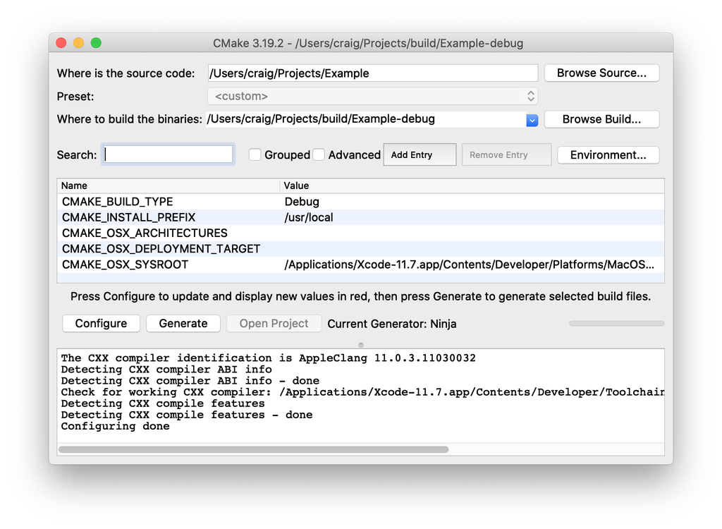

源目录必须设置为 项目源代码树根目录下包含`CMakeLists.txt文件的目录。构建目录是 CMake 生成所有构建输出的位置（推荐的目录布局已在`第 2 章*“设置项目*”中讨论）。对于新项目，两者都必须设置；但对于现有项目，设置构建目录也会更新源目录，因为源文件的位置存储在构建目录的缓存中。

The source directory must be set to the directory containing the `CMakeLists.txt` file at the top of the project’s source tree. The build directory is where CMake will generate all build output (recommended directory layouts were discussed in Chapter 2, *Setting Up A Project*). For new projects, both must be set, but for existing projects, setting the build directory will also update the source directory, since the source location is stored in the build directory’s cache.

CMake 的两阶段设置过程在2.3 节“生成项目文件”中介绍过。在第一阶段， CMake 会读取`CMakeLists.txt`文件，并在内存中构建项目的表示形式。这称为*配置*阶段。如果配置阶段成功，则可以执行 *生成阶段，在构建目录中创建构建工具的项目文件。从命令行运行*`cmake`时，这两个阶段都会自动执行；但在 GUI 应用程序中，则需要分别通过`“配置”`和 `“生成”`按钮来触发。每次启动配置步骤时，UI 中间显示的缓存变量都会更新。任何新添加的变量或与上次运行相比值发生变化的变量都会以红色突出显示（首次加载项目时，所有变量都会突出显示）。最佳实践是重复运行配置阶段，直到没有变化为止，因为这可以确保更复杂项目的稳健性，因为启用某些选项可能会添加更多选项，从而需要再次运行配置。一旦所有缓存变量不再以红色突出显示，即可运行生成阶段。上一个屏幕截图中的示例显示了配置阶段运行后典型的日志输出，并且没有对任何缓存变量进行任何更改。

CMake’s two-stage setup process was introduced in Section 2.3, “Generating Project Files”. In the first stage, the `CMakeLists.txt` file is read and a representation of the project is built up in memory. This is called the *configure* stage. If the configure stage is successful, the *generate* stage can then be executed to create the build tool’s project files in the build directory. When running `cmake` from the command line, both stages are executed automatically, but in the GUI application, they are triggered separately with the `Configure` and `Generate` buttons. Each time the configure step is initiated, the cache variables shown in the middle of the UI are updated. Any variables which were newly added or which changed value from the previous run will be highlighted in red (when a project is first loaded, all variables are shown highlighted). Good practice is to re-run the configure stage until there are no changes, since this ensures robust behavior for more complex projects where enabling some options may add further options which could require another configure pass. Once all cache variables are shown without red highlighting, the generate stage can be run. The example in the previous screenshot shows typical log output after the configure stage has been run and no changes were made to any of the cache variables.

将鼠标悬停在任何缓存变量上都会显示一个工具提示，其中包含 该变量的`文档字符串。也可以使用``“添加条目”`按钮添加新的缓存变量，这相当于使用空`文档字符串执行``set()`命令。可以使用`“删除条目”`按钮删除缓存变量，但 CMake 很可能会在下次运行时重新创建该变量。

Hovering the mouse over any cache variable will show a tooltip containing the `docstring` for that variable. New cache variables can also be added with the `Add Entry` button, which is equivalent to issuing a `set()` command with an empty `docstring`. Cache variables can be removed with the `Remove Entry` button, although CMake will most likely recreate that variable on the next run.

点击变量即可在针对该变量类型定制的控件中编辑其值。布尔值显示为复选框，文件和路径显示为浏览文件系统按钮，字符串通常显示为文本行编辑框。特殊情况下，可以为`STRING`类型的缓存变量指定一组值，以便在 CMake GUI 的组合框中显示，而不是显示简单的文本输入控件。这可以通过设置缓存变量的`STRINGS`属性来实现（详见9.6 节“缓存变量属性”，此处仅作简要说明）：

Clicking on a variable allows its value to be edited in a widget tailored to the variable type. Booleans are shown as a checkbox, files and paths have a browse filesystem button and strings are usually presented as a text line edit. As a special case, cache variables of type `STRING` can be given a set of values to show in a combobox in CMake GUI instead of showing a simple text entry widget. This is achieved by setting a cache variable’s `STRINGS` property (covered in detail in Section 9.6, “Cache Variable Properties”, but shown here for convenience):

```
set(trafficLight Green CACHE STRING "Status of something")
set_property(CACHE trafficLight PROPERTY
    STRINGS Red Orange Green
)
```

在上述示例中，`trafficLight`缓存变量的初始值为 `Green`。当用户尝试在`cmake-gui中修改``trafficLight`时，系统会提供一个包含`Red`、`Orange`和 `Green`三个值的组合框，而不是原本允许用户输入任意文本的简单行编辑框。请注意，设置变量的`STRINGS属性并不会阻止该变量被赋予其他值，它只会影响``cmake-gui在编辑时使用的控件。用户仍然可以通过``CMakeLists.txt文件中的``set()`命令 或其他方式（例如手动编辑 `CMakeCache.txt`文件）为该变量赋予其他值。

In the above, the `trafficLight` cache variable will initially have the value `Green`. When the user attempts to modify `trafficLight` in `cmake-gui`, they will be given a combobox containing the three values `Red`, `Orange` and `Green` instead of a simple line edit widget which would otherwise have allowed them to enter any arbitrary text. Note that setting the `STRINGS` property on the variable doesn’t prevent that variable from having other values assigned to it, it only affects the widget used by `cmake-gui` when editing it. The variable can still be given other values via `set()` commands in the `CMakeLists.txt` file or by other means such as manually editing the `CMakeCache.txt` file.

缓存变量还可以有一个属性，用于标记它们是高级变量还是非高级变量。这只会影响变量在`cmake-gui`中的显示方式，不会以任何方式影响 CMake 在处理过程中如何使用这些变量。默认情况下， `cmake-gui`只显示非高级变量，通常只显示开发人员想要查看或修改的主要变量。启用`“高级”选项后，将显示除标记为``“INTERNAL”的`变量之外的所有缓存变量 （查看`“INTERNAL”`变量的唯一方法是使用文本编辑器编辑 `CMakeCache.txt文件，因为它们不应该由开发人员直接操作）。可以使用``CMakeLists.txt`文件中的`mark_as_advanced()`命令将变量标记为高级变量：

Cache variables can also have a property marking them as advanced or not. This too only affects the way the variable is displayed in `cmake-gui`, it does not in any way affect how CMake uses the variable during processing. By default, `cmake-gui` only shows non-advanced variables, which typically presents just the main variables a developer would be interested in viewing or modifying. Enabling the `Advanced` option shows all cache variables except those marked `INTERNAL` (the only way to see `INTERNAL` variables is to edit the `CMakeCache.txt` file with a text editor, since they are not intended to be manipulated directly by developers). Variables can be marked as advanced with the `mark_as_advanced()` command within the `CMakeLists.txt` file:

```
mark_as_advanced([CLEAR|FORCE] var1 [var2...])
```

`CLEAR`关键字确保变量不被标记为高级变量，而 `FORCE`关键字确保变量被标记为高级变量。如果没有这两个关键字，则只有当变量尚未设置高级/非高级状态时，才会将其标记为高级变量。

The `CLEAR` keyword ensures the variables are not marked as advanced, while the `FORCE` keyword ensures the variables are marked advanced. Without either keyword, the variables will only be marked as advanced if they don’t already have an advanced/non-advanced state set.

选择`“分组”`选项可以更轻松地查看高级变量，它会根据变量名称开头到第一个下划线的部分将变量分组。另一种筛选变量列表的方法是，在`搜索`区域输入文本，这样只会显示名称或值中包含指定文本的变量。

Selecting the `Grouped` option can make viewing advanced variables easier by grouping variables together based on the start of the variable name up to the first underscore. Another way to filter the list of variables shown is to enter text in the `Search` area, which results in only showing variables with the specified text in their name or value.

当首次在新项目上运行配置阶段时，开发人员会看到一个类似于下图所示的对话框：

When the configure stage is run for the first time on a new project, the developer is presented with a dialog similar to that shown in the next screenshot:

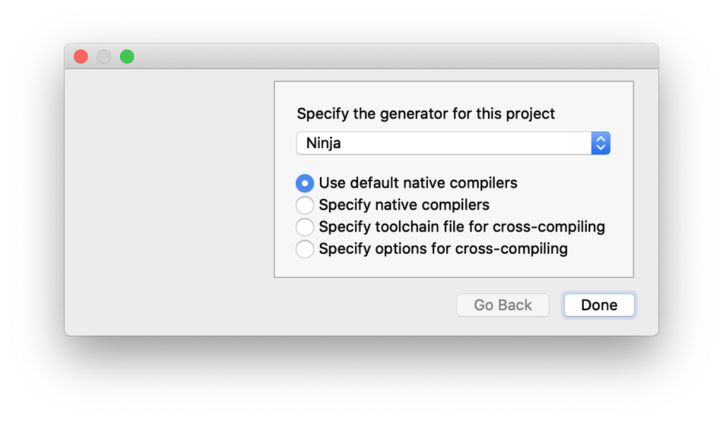

此对话框用于指定 CMake 生成器和工具链。生成器的选择通常取决于开发者的个人偏好，下拉框中会提供可用选项。根据项目的具体情况，生成器的选择可能比下拉框选项更受限，例如，如果项目依赖于特定生成器的功能。一个常见的例子是，由于 Apple 平台的独特功能（例如代码签名和对 iOS/tvOS/watchOS 的支持），某些项目需要使用 Xcode 生成器。一旦为项目选择了生成器，除非清除缓存并重新开始，否则无法更改。如有需要，可以通过 `“文件”`菜单执行此操作。

This dialog is where the CMake generator and toolchain are specified. The choice of generator is usually up to the developer’s personal preference, with available options provided in the combobox. Depending on the project, the choice of generator may be more restricted than what the combobox options allow, such as if the project relies on generator-specific functionality. A common example of this is a project that requires the Xcode generator due to the Apple platform’s unique features, such as code signing and iOS/tvOS/watchOS support. Once a generator has been selected for a project, it cannot be changed without deleting the cache and starting again, which can be done from the `File` menu if required.

对于所提供的工具链选项，每个选项都需要开发者提供的信息逐渐增加。使用默认的本地编译器是普通桌面开发的常用选择，选择此选项无需提供任何其他详细信息。如果需要更多控制，开发者可以覆盖本地编译器，编译器路径将在后续对话框中提供。如果存在单独的工具链文件，则可以使用它来自定义编译器、目标环境、编译器标志以及其他各种设置。工具链文件通常用于交叉编译，这将在 第 22 章*“工具链和交叉编译”*中详细介绍。最后，为了获得最终的控制权，开发者可以指定交叉编译的全部选项，但这在常规使用中并不推荐。工具链文件可以提供相同的信息，而且它的优势在于可以根据需要重复使用。

For the toolchain options presented, each one requires progressively more information from the developer. Using the default native compilers is the usual choice for ordinary desktop development and selecting that option requires no further details. If more control is required, developers can instead override the native compilers, with the paths to the compilers being given in a follow-up dialog. If a separate toolchain file is available, that can be used to customize not just the compilers but also the target environment, compiler flags and various other things. Using a toolchain file is typical when cross-compiling, which is covered in detail in Chapter 22, *Toolchains And Cross Compiling*. Lastly, for ultimate control, developers can specify the full set of options for cross-compiling, but this is not recommended for normal use. A toolchain file can provide the same information but has the advantage that it can be re-used as needed.

`ccmake`工具提供的功能与`cmake-gui`应用程序基本相同 ，但它是通过基于文本的界面实现的：

The `ccmake` tool offers most of the same functionality as the `cmake-gui` application, but it does so through a text-based interface:

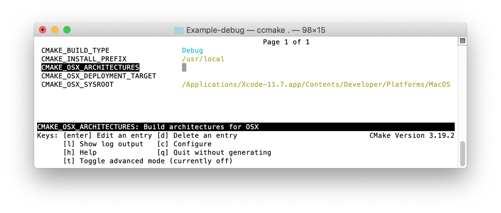

`与cmake-gui`选择源目录和构建目录不同 ， `ccmake` 命令行必须像`cmake`命令一样指定源目录或构建目录。

Rather than selecting the source and build directories like with `cmake-gui`, the source or build directory has to be specified on the `ccmake` command line, just like for the `cmake` command.

`ccmake`界面的一个小缺点是无法筛选显示的变量。编辑变量的方法也不如`cmake-gui`丰富。尽管如此，当完整的`cmake-gui`应用程序不实用或不可用时（例如在不支持 UI 转发的终端连接上），`ccmake`工具仍然是一个有用的替代方案 。

A minor drawback of the `ccmake` interface is that there is no ability to filter the variables shown. The methods for editing a variable are also not as rich as with `cmake-gui`. Nevertheless, the `ccmake` tool is a useful alternative when the full `cmake-gui` application is not practical or not available, such as over a terminal connection that cannot support UI forwarding.

## 5.6 打印变量值

## 5.6. Printing Variable Values

随着项目变得越来越复杂，或者在调查意外行为时，在 CMake 运行期间打印诊断信息和变量值会非常有用。这通常使用 `message()命令来实现，该命令在`第 13 章*“调试和诊断”*中有详细介绍。现在，只需知道`message()` 命令最简单的用法就是将其参数打印到 CMake 的输出中。如果提供了多个参数，它不会在参数之间添加分隔符，并且会自动在消息末尾添加换行符。也可以使用常见的`\n符号显式地添加换行符。可以使用常用的``${myVar}`符号将变量值包含在消息中 。

As projects get more complicated or when investigating unexpected behavior, it can be useful to print out diagnostic messages and variable values during a CMake run. This is generally achieved using the `message()` command, which is covered in detail in Chapter 13, *Debugging And Diagnostics*. For now, it is enough to know that in its simplest form, all the `message()` command does is print its arguments to CMake’s output. It adds no separator between arguments if more than one argument is given and a newline is automatically appended to the end of the message. Newlines can also be explicitly included using the common `\n` notation. A variable’s value can be included in the message by using the usual `${myVar}` notation.

```
set(myVar HiThere)
message("The value of myVar = ${myVar}\nAnd this "
        "appears on the next line")
```

这将产生以下输出：

This will give the following output:

```
myVar 的值为 HiThere
而这出现在下一行。
```

## 5.7 字符串处理

## 5.7. String Handling

随着项目复杂性的增加，很多情况下也需要实现更复杂的变量管理逻辑。CMake 提供了一个核心工具——string `()`命令，它提供了一系列实用的字符串处理功能。该命令使项目能够执行查找和替换、正则表达式匹配、大小写转换、去除空格以及其他常见任务。下面介绍一些常用功能，但 CMake 参考文档才是所有可用操作及其行为的权威来源。

As project complexity grows, in many cases so too does the need to implement more involved logic for how variables are managed. A core tool CMake provides for this is the `string()` command, which provides a wide range of useful string handling functionality. This command enables projects to perform find and replace operations, regular expression matching, upper/lower case transformations, strip whitespace and other common tasks. Some of the more frequently used functionality is presented below, but the CMake reference documentation should be considered the canonical source of all available operations and their behavior.

`string() 函数`的第一个参数定义了要执行的操作，后续参数则取决于所请求的操作。这些参数通常至少需要一个输入字符串，并且由于 CMake 命令无法返回值，因此还需要一个用于存储操作结果的输出变量。在下文中，该输出变量通常命名为`outVar`。

The first argument to `string()` defines the operation to be performed and subsequent arguments depend on the operation being requested. These arguments will generally require at least one input string and since CMake commands cannot return a value, an output variable for the result of the operation. In the material below, this output variable will generally be named `outVar`.

```
string(FIND inputString subString outVar [REVERSE])
```

`FIND 函数`在`inputString`中查找`子字符串，并将找到的``子字符串`的索引存储在`outVar`中（第一个字符的索引为 0）。除非指定了`REVERSE 函数`，否则 FIND 函数会查找第一个匹配项；如果指定了 REVERSE 函数，则会查找最后一个匹配项。如果`子字符串`不存在于 `inputString`中，则`outVar 的`值将被赋值为 -1。

`FIND` searches for `subString` in `inputString` and stores the index of the found `subString` in `outVar` (the first character is index 0). The first occurrence is found unless `REVERSE` is specified, in which case the last occurrence will be found instead. If `subString` does not appear in `inputString`, then `outVar` will be given the value -1.

```
string(FIND abcdefabcdef def fwdIndex)
string(FIND abcdefabcdef def revIndex REVERSE)

message("fwdIndex = ${fwdIndex}\n"
        "revIndex = ${revIndex}")
```

这将产生以下输出结果：

This results in the following output:

```
fwdIndex = 3
revIndex = 9
```

替换简单子字符串遵循类似的模式：

Replacing a simple substring follows a similar pattern:

```
string(REPLACE matchString replaceWith outVar input...)
```

REPLACE`操作会将``输入`字符串中 所有出现的`matchString`替换为`replaceWith`，并将结果存储在`outVar中。当``输入`多个字符串时，它们会先连接在一起，中间没有任何分隔符，然后再进行替换搜索。这有时会导致意外匹配，因此在大多数情况下，开发人员通常只会提供一个`输入`字符串。

The `REPLACE` operation will replace every occurrence of `matchString` in the `input` strings with `replaceWith` and store the result in `outVar`. When multiple `input` strings are given, they are joined together without any separator between each string before searching for substitutions. This can sometimes lead to unexpected matches and typically developers would provide just the one `input` string in most situations.

`REGEX`操作 也很好地支持正则表达式，并根据第二个参数提供几种不同的变体：

Regular expressions are also well supported by the `REGEX` operation, with a few different variants available as determined by the second argument:

```
string(REGEX MATCH    regex outVar input...)
string(REGEX MATCHALL regex outVar input...)
string(REGEX REPLACE  regex replaceWith outVar input...)
```

要匹配的正则表达式`regex`可以使用典型的基本正则表达式语法（完整规范请参见 CMake 参考文档），但某些常用功能（例如否定）不受支持。`输入``字符串`在替换之前会进行连接。MATCH `操作`仅查找第一个匹配项并将其存储在`outVar`中。MATCHALL 查找所有匹配项并将它们作为列表存储在`outVar`中。REPLACE 将返回整个`输入`字符串，其中每个匹配项都由 `replaceWith替换。在``replaceWith``中`可以使用常用的 \1、\2 等符号引用匹配项，但请注意，除非使用方括号表示法，否则反斜杠本身必须转义。以下示例及其输出演示了上述要点：

The regular expression to match, `regex`, can make use of typical basic regular expression syntax (see the CMake reference documentation for the full specification), although some common features such as negation are not supported. The `input` strings are concatenated before substitution. The `MATCH` operation finds just the first match and stores it in `outVar`. `MATCHALL` finds all matches and stores them in `outVar` as a list. `REPLACE` will return the entire `input` string with each match replaced by `replaceWith`. Matches can be referred to in `replaceWith` using the usual notation \1, \2, etc., but note that the backslashes themselves must be escaped unless bracket notation is used. The following example and its output demonstrate the above points:

```
string(REGEX MATCH "[ace]"
    matchOne abcdefabcdef
)
string(REGEX MATCHALL "[ace]"
    matchAll abcdefabcdef
)
string(REGEX REPLACE "([de])" "X\\1Y"
    replVar1 abc def abcdef
)
string(REGEX REPLACE "([de])" [[X\1Y]]
    replVar2 abcdefabcdef
)

message("matchOne = ${matchOne}\n"
        "matchAll = ${matchAll}\n"
        "replVar1 = ${replVar1}\n"
        "replVar2 = ${replVar2}")
```

```
匹配一个 = a
matchAll = a;c;e;a;c;e
replVar1 = abcXdYXeYfabcXdYXeYf
replVar2 = abcXdYXeYfabcXdYXeYf
```

提取子字符串也是可行的：

Extracting a substring is also possible:

```
string(SUBSTRING input index length outVar)
```

索引是一个整数`，`用于定义要从 `输入`中提取的子字符串的起始位置。最多将提取`length个字符；如果``length为 -1，则返回的子字符串将包含``输入`字符串末尾之前的所有字符。请注意，在 CMake 3.1 及更早版本中，如果`length` 指向字符串末尾之外， 则会报告错误。

The `index` is an integer defining the start of the substring to extract from `input`. Up to `length` characters will be extracted, or if `length` is -1, the returned substring will contain all characters up to the end of the `input` string. Note that in CMake 3.1 and earlier, an error was reported if `length` pointed past the end of the string.

字符串长度很容易获取，字符串也很容易转换为大写或小写。去除字符串开头和结尾的空格也很简单。这些操作的语法都相同：

String length can be trivially obtained and strings can easily be converted to upper or lower case. It is also straightforward to strip whitespace from the start and end of a string. The syntax for these operations all share the same form:

```
string(LENGTH  input outVar)
string(TOLOWER input outVar)
string(TOUPPER input outVar)
string(STRIP   input outVar)
```

由于历史原因， `LENGTH`命令统计的是字节数而不是字符数。对于包含多字节字符的字符串，这意味着报告的长度将与字符数不同。

In the case of `LENGTH`, for historical reasons the command counts bytes rather than characters. For strings containing multi-byte characters, this means the reported length will be different to the number of characters.

CMake 还提供了其他操作，例如字符串比较、哈希、时间戳、JSON 处理等等，但它们在日常 CMake 项目中并不常用。感兴趣的读者可以查阅 CMake 参考文档中关于 `string()`命令的详细信息。

CMake provides other operations, such as string comparison, hashing, timestamps, JSON handling and more, but their use is less common in everyday CMake projects. The interested reader should consult the CMake reference documentation for the `string()` command for full details.

## 5.8. 列表

## 5.8. Lists

CMake 中大量使用列表。本质上，列表就是一个字符串，其中列表项用分号分隔（但有一个例外，将在 下文5.8.1 节“方括号不平衡的问题”中讨论）。这使得操作单个列表项不太方便。CMake 提供了 `list()`命令来简化此类操作。与`string()`命令类似，`list()`的第一个参数是要执行的操作。第二个参数始终是要操作的列表，并且它必须是一个变量（即不允许传递原始列表，例如`a;b;c ）。`

Lists are used heavily in CMake. Ultimately, lists are just a single string with list items separated by semicolons (with one exception, which is covered in Section 5.8.1, “Problems With Unbalanced Square Brackets” further below). This can make it less convenient to manipulate individual list items. CMake provides the `list()` command to facilitate such tasks. Like for the `string()` command, `list()` expects the operation to perform as its first argument. The second argument is always the list to operate on and it must be a variable (i.e. passing a raw list like `a;b;c` is not permitted).

列表最基本的操作是统计元素数量和从列表中检索一个或多个元素：

The most basic list operations are counting the number of items and retrieving one or more items from the list:

```
list(LENGTH listVar outVar)
list(GET    listVar index [index...] outVar)
```

用法示例：

Example usage:

```
set(myList a b c)        # Creates the list "a;b;c"

list(LENGTH myList len)
message("length  = ${len}")

list(GET myList 2 1 letters)
message("letters = ${letters}")
```

上述示例的输出结果为：

The output of the above example would be:

```
长度 = 3
字母 = c;b
```

插入、追加和添加前缀也是常见的操作：

Inserting, appending and prepending items is also a common task:

```
list(INSERT  listVar index item [item...])
list(APPEND  listVar item [item...])

# Requires CMake 3.15 or later
list(PREPEND listVar item [item...])
```

`与LENGTH`和`GET`操作不同，`INSERT`、`APPEND`和`PREPEND`直接作用于`listVar`并就地修改它，如下例所示：

Unlike the `LENGTH` and `GET` cases, `INSERT`, `APPEND` and `PREPEND` act directly on the `listVar` and modify it in-place, as demonstrated by the following example:

```
set(myList a b c)

list(INSERT myList 2 X Y Z)
message("myList (first)  = ${myList}")

list(APPEND myList d e f)
message("myList (second) = ${myList}")

list(PREPEND myList P Q R)
message("myList (third)  = ${myList}")
```

输出结果如下：

Which gives the following output:

```
myList（第一个）= a;b;X;Y;Z;c
myList（第二个）= a;b;X;Y;Z;c;d;e;f
myList（第三部分）= P;Q;R;a;b;X;Y;Z;c;d;e;f
```

在列表中查找特定项目遵循预期模式：

Finding a particular item in the list follows the expected pattern:

```
list(FIND myList value outVar)
```

用法示例：

Example usage:

```
set(myList a b c d e)
list(FIND myList d index)
message("index = ${index}")
```

最终输出结果：

Resultant output:

```
索引 = 3
```

提供了三种删除项目的操作，所有这些操作都会直接修改列表：

Three operations are provided for removing items, all of which modify the list directly:

```
list(REMOVE_ITEM       myList value [value...])
list(REMOVE_AT         myList index [index...])
list(REMOVE_DUPLICATES myList)
```

REMOVE_ITEM操作可用于从列表中删除一个或多个元素的所有实例。如果该元素不在列表中，则不会报错。 而`REMOVE_AT则指定要删除的一个或多个索引``，`如果任何指定的索引超出列表末尾，CMake 将停止并报错。REMOVE_DUPLICATES `操作`可确保列表仅包含唯一元素。

The `REMOVE_ITEM` operation can be used to remove all instances of one or more items from a list. If the item is not in the list, it is not an error. `REMOVE_AT` on the other hand, specifies one or more indices to remove and CMake will halt with an error if any of the specified indices are past the end of the list. `REMOVE_DUPLICATES` will ensure the list contains only unique items.

CMake 3.15 增加了对从列表头部或尾部弹出元素以及（可选）存储弹出元素的支持：

CMake 3.15 added support for popping items from the front or back of a list and optionally storing the popped items:

```
# Requires CMake 3.15 or later
list(POP_FRONT myList [outVar1 [outVar2...]])
list(POP_BACK myList [outVar1 [outVar2...]])
```

如果没有指定`outVar`，则会从数组的开头或结尾弹出一个元素并将其丢弃。如果指定了一个或多个`outVar`，则弹出的元素将存储在这些变量中，弹出的元素数量等于提供的变量名数量。

When no `outVar` is given, a single item is popped from the front or back and discarded. If one or more `outVar` names are given, popped items will be stored in those variables, with the number of items popped equal to the number of variable names provided.

`列表项还可以使用REVERSE`或`SORT`操作 重新排序：

List items can also be reordered with `REVERSE` or `SORT` operations:

```
list(REVERSE myList)
list(SORT myList
    [COMPARE method]
    [CASE case]
    [ORDER order]
)
```

`list(SORT)`的所有可选关键字仅在 CMake 3.13 或更高版本中可用。如果存在`COMPARE选项，则该``方法`必须是以下方法之一：

All of the optional keywords for `list(SORT)` are only available with CMake 3.13 or later. If the `COMPARE` option is present, the `method` must be one of the following:

**`细绳`**

**`STRING`**

按字母顺序排序。这是未指定`COMPARE`选项时的默认行为。

Sort alphabetically. This is the default behavior when the `COMPARE` option is not given.

**`文件基本名称`**

**`FILE_BASENAME`**

排序时假设每个项目都是一个路径，并且项目应该仅根据路径的基本名称部分进行排序。

Sort by assuming that each item is a path and that items should be ordered according to the basename part of the path only.

**`自然的`**

**`NATURAL`**

`与STRING 类型`类似，不同之处在于，字符串中连续的数字会按数值排序。这对于对包含嵌入式版本号的字符串进行排序非常有用。排序规则与 C 函数`strverscmp()` （GNU 扩展）相同。此排序方法仅适用于 CMake 3.18 或更高版本。

Similar to `STRING`, except contiguous digits within an item are sorted numerically. This is most useful for sorting strings that contain embedded version numbers. The sorting rules are the same as for the `strverscmp()` C function (a GNU extension). This sorting method is only available with CMake 3.18 or later.

CASE`关键字`要求`区分大小写`为`SENSITIVE`或`INSENSITIVE`，而`ORDER`关键字要求`排序方式`为`ASCENDING`或`DESCENDING`。

The `CASE` keyword requires `SENSITIVE` or `INSENSITIVE` for the `case`, while the `ORDER` keyword requires either `ASCENDING` or `DESCENDING` for the `order`.

对于所有需要索引的列表操作，负索引表示从列表末尾开始计数。这样使用时，列表中的最后一个元素索引为 -1，倒数第二个元素索引为 -2，依此类推。

For all list operations taking an index, a negative index indicates that counting starts from the end of the list. When used this way, the last item in the list has index -1, the second last -2, and so on.

以上描述了大部分可用的`list()`子命令。除非另有说明，否则所提到的子命令至少从 CMake 3.0 开始就已受支持，因此项目通常可以预期它们可用。有关受支持子命令的完整列表，请参阅 CMake 文档。

The above describes most of the available `list()` sub-commands. Those mentioned are all supported since at least CMake 3.0 unless otherwise noted, so projects should generally be able to expect them to be available. For the full list of supported sub-commands, the reader should consult the CMake documentation.

### 5.8.1. 不平衡方括号的问题

### 5.8.1. Problems With Unbalanced Square Brackets

CMake 通常不会将分号作为列表分隔符，但有一个例外。由于历史原因，如果列表项包含左方括号`[`，则必须同时包含一个匹配的右方括号`]`。CMake 会将这两个方括号之间的任何分号视为列表项的一部分，而不是列表分隔符。如果尝试使用不匹配的方括号来构建列表，则该列表将无法按预期解析。以下示例演示了这种行为：

There is one exception to the way CMake usually treats semicolons as list separators. For historical reasons, if a list item contains an opening square bracket `[`, it must also have a matching closing square bracket `]`. CMake will consider any semicolon between these square brackets to be part of the list item instead of as a list separator. If one tries to construct a list with unbalanced square brackets, the list won’t be interpreted as expected. The following demonstrates the behavior:

```
set(noBrackets   "a_a" "b_b")
set(withBrackets "a[a" "b]b")

list(LENGTH noBrackets   lenNo)
list(LENGTH withBrackets lenWith)

list(GET noBrackets   0 firstNo)
list(GET withBrackets 0 firstWith)

message("No brackets:   "
        "Length=${lenNo} --> First_element=${firstNo}"
)
message("With brackets: "
        "Length=${lenWith} --> First_element=${firstWith}"
)
```

上述操作的输出结果为：

The output from the above would be:

```
无括号：长度=2 --> 第一个元素=a_a
带括号：长度=1 --> 第一个元素=a[a;b]b
```

第 8.8.3 节“论证扩展的特殊情况”讨论了这一特殊性的更多方面。

Discussion in Section 8.8.3, “Special Cases For Argument Expansion” covers further aspects of this peculiarity.

## 5.9 数学

## 5.9. Math

另一种常见的变量操作形式是数学运算。CMake 提供了`math()`命令来执行基本的数学计算：

One other common form of variable manipulation is math computation. CMake provides the `math()` command for performing basic mathematical evaluation:

```
math(EXPR outVar mathExpr [OUTPUT_FORMAT format])
```

第一个参数必须是关键字`EXPR`，而`mathExpr`定义了要计算的表达式，结果将存储在`outVar`中。该表达式可以使用以下任何运算符，它们的含义与 C 代码中的运算符相同：`+ - * / % | & ^ ~ << >>` 。括号也受支持，并具有其通常的数学含义。可以使用常见的`${myVar}表示法在``mathExpr`中引用变量 。

The first argument must be the keyword `EXPR`, while `mathExpr` defines the expression to be evaluated and the result will be stored in `outVar`. The expression may use any of the following operators which all have the same meaning as they would in C code: `+ - * / % | & ^ ~ << >>`. Parentheses are also supported and have their usual mathematical meaning. Variables can be referenced in the `mathExpr` with the usual `${myVar}` notation.

如果使用 CMake 3.13 或更高版本，可以使用`OUTPUT_FORMAT`关键字来控制结果在`outVar`中的存储方式。`格式`可以是`DECIMAL（`默认行为）或 `HEXADECIMAL`。

If using CMake 3.13 or later, the `OUTPUT_FORMAT` keyword can be given to control how the result is stored in `outVar`. The `format` should be either `DECIMAL`, which is the default behavior, or `HEXADECIMAL`.

```
set(x 3)
set(y 7)
math(EXPR zDec "(${x}+${y}) * 2")
message("decimal = ${zDec}")

# Requires CMake 3.13 or later for HEXADECIMAL
math(EXPR zHex "(${x}+${y}) * 2" OUTPUT_FORMAT HEXADECIMAL)
message("hexadecimal = ${zHex}")
```

上述操作会产生以下输出：

The above produces the following output:

```
十进制 = 20
十六进制 = 0x14
```

## 5.10. 推荐做法

## 5.10. Recommended Practices

在开发环境允许的情况下，CMake GUI 工具是快速便捷地了解项目构建选项并根据需要在开发过程中进行修改的有效方法。花些时间熟悉它，将有助于日后处理更复杂的项目。此外，它还为开发人员提供了一个良好的基础，方便他们尝试编译器设置等内容，因为这些设置都可以在 GUI 环境中轻松找到和修改。

Where the development environment allows it, the CMake GUI tool is a useful way to quickly and easily understand the build options for a project and to modify them as needed during development. A little bit of time spent getting familiar with it will simplify working with more complex projects later. It also gives developers a good base to work from should they need to experiment with things like compiler settings, since these are easily found and modified within the GUI environment.

建议使用缓存变量来控制是否启用构建的可选部分，而不是将逻辑编码到 CMake 之外的构建脚本中。这样，在 CMake GUI 和其他能够理解如何使用 CMake 缓存的工具中启用和禁用这些可选部分就变得非常简单（越来越多的 IDE 环境正在具备这种能力）。

Prefer to provide cache variables for controlling whether to enable optional parts of the build instead of encoding the logic in build scripts outside of CMake. This makes it trivial to turn them on and off in the CMake GUI and other tools which understand how to work with the CMake cache (a growing number of IDE environments are acquiring this capability).

`除了常见的PATH 环境变量`或类似的操作系统级变量之外，尽量避免依赖已定义的环境变量。构建过程应该可预测、可靠且易于配置，但如果依赖环境变量的设置才能正常工作，那么对于新手开发者来说，在配置构建环境时可能会遇到诸多困难，令人沮丧。此外，CMake 运行时的环境可能与构建本身运行时的环境有所不同。因此，尽可能优先通过缓存变量直接向 CMake 传递信息。

Try to avoid relying on environment variables being defined, apart from perhaps the ubiquitous `PATH` or similar operating system level variables. The build should be predictable, reliable and easy to set up, but if it relies on environment variables being set for things to work correctly, this can be a point of frustration for new developers as they wrestle to get their build environment set up. Furthermore, the environment at the time CMake is run can change compared to when the build itself is invoked. Therefore, prefer to pass information directly to CMake through cache variables instead wherever possible.

尽早建立变量命名规范。对于缓存变量，可以考虑将相关变量分组到一个共同的前缀下，并在前缀后加下划线，这样可以充分利用 CMake GUI 的自动分组机制，即基于相同的前缀对变量进行分组。此外，还要考虑到项目将来可能会成为某个更大项目的子项目，因此使用以项目名称开头或与项目密切相关的名称可能更为合适。

Try to establish a variable naming convention early. For cache variables, consider grouping related variables under a common prefix followed by an underscore to take advantage of how CMake GUI groups variables based on the same prefix automatically. Also consider that the project may one day become a sub-part of some larger project, so a name beginning with the project name or something closely associated with the project may be desirable.

尽量避免在项目中定义与缓存变量同名的非缓存变量。对于 CMake 新手来说，这两种变量之间的交互可能会造成意想不到的后果。后续章节还会重点介绍其他一些常见的错误以及常规变量与缓存变量同名的误用。

Try to avoid defining non-cache variables in the project which have the same name as cache variables. The interaction between the two types of variables can be unexpected for developers new to CMake. Later chapters also highlight other common errors and misuses of regular variables that share the same name as cache variables.

CMake 提供了大量预定义变量，这些变量提供有关系统的详细信息或影响 CMake 的某些行为。其中一些变量在项目中被频繁使用，例如仅在为特定平台（`WIN32`、`APPLE`、`UNIX`等）构建时定义的变量。因此，建议开发人员定期快速浏览 CMake 文档中列出的预定义变量页面，以便熟悉可用的变量。

CMake provides a large number of pre-defined variables that provide details about the system or influence certain aspects of CMake’s behavior. Some of these variables are heavily used by projects, such as those that are only defined when building for a particular platform (`WIN32`, `APPLE`, `UNIX`, etc.). It is therefore recommended for developers to occasionally make a quick scan through the CMake documentation page listing the pre-defined variables to help become familiar with what is available.

# 6. 流量控制

# 6. Flow Control

大多数 CMake 项目都存在一个共同的需求：仅在特定情况下执行某些步骤。例如，项目可能希望仅在特定编译器或针对特定平台构建时才使用某些编译器标志。在其他情况下，项目可能需要遍历一组值，或者重复执行某些步骤，直到满足特定条件。CMake 对这些流程控制示例提供了良好的支持，大多数软件开发人员应该都很熟悉这些功能。常用的`if()命令提供了预期的 if-then-else 行为，而``foreach()`和 `while()`命令则提供了循环功能。这三个命令都提供了大多数编程语言中实现的传统行为，但它们也具有 CMake 特有的附加功能。

A common need for most CMake projects is to apply some steps only in certain circumstances. Projects may want to use certain compiler flags only with a particular compiler or when building for a particular platform, for example. In other cases, the project may need to iterate over a set of values or to keep repeating some set of steps until a certain condition is met. These examples of flow control are well supported by CMake in ways which should be familiar to most software developers. The ubiquitous `if()` command provides the expected if-then-else behavior and looping is provided through the `foreach()` and `while()` commands. All three commands provide the traditional behavior as implemented by most programming languages, but they also have added features specific to CMake.

## 6.1. if() 命令

## 6.1. The if() Command

`现代的if()`命令形式如下（ 可以提供多个`elseif()子句）：`

The modern form of the `if()` command is as follows (multiple `elseif()` clauses can be provided):

```
if(expression1)
    # commands ...
elseif(expression2)
    # commands ...
else()
    # commands ...
endif()
```

CMake 的早期版本要求将`expression1`作为参数重复传递给`else()`和`endif()`子句，但自 CMake 2.8.0 起，此要求已不再适用。虽然现在仍然会遇到一些项目和示例代码使用这种旧形式，但建议新项目不要这样做，因为它可能会使代码难以阅读。新项目应该将`else()`和 `endif()`的参数留空，如上所示。

Very early versions of CMake required `expression1` to be repeated as an argument to the `else()` and `endif()` clauses, but this has not been required since CMake 2.8.0. While it is still not unusual to encounter projects and example code using that older form, it is discouraged for new projects since it can be somewhat confusing to read. New projects should leave the `else()` and `endif()` arguments empty, as shown above.

`if()`和`elseif()`命令中的表达式可以采用多种不同的形式。CMake 不仅提供传统的布尔逻辑，还提供各种其他条件，例如文件系统测试、版本比较和对象存在性测试。

The expressions in `if()` and `elseif()` commands can take a variety of different forms. CMake offers the traditional boolean logic as well as various other conditions such as file system tests, version comparison and testing for the existence of things.

### 6.1.1. 基本表达式

### 6.1.1. Basic Expressions

所有表达式中最基本的是单个常量值：

The most basic of all expressions is a single constant value:

```
if(value)
```

CMake判断真假的逻辑比大多数编程语言要复杂一些。对于单个未加引号的`值`，规则如下：

CMake’s logic for what it considers true and false is a little more involved than most programming languages. For a single unquoted `value`, the rules are as follows:

- 如果`value`是一个带引号或不带引号的常量，且其值为`ON`、`YES`、`TRUE`或 `Y`，则将其视为真。此测试不区分大小写。
- If `value` is a quoted or unquoted constant with value `ON`, `YES`, `TRUE` or `Y`, it is treated as true. The test is case-insensitive.
- 如果`value`是一个带引号或不带引号的常量，其值为`OFF`、`NO`、`FALSE`、 `N`、`IGNORE`、`NOTFOUND 、空字符串或以``-NOTFOUND`结尾的字符串 ，则将其视为 false。同样，此测试不区分大小写。
- If `value` is a quoted or unquoted constant with value `OFF`, `NO`, `FALSE`, `N`, `IGNORE`, `NOTFOUND`, an empty string or a string that ends in `-NOTFOUND`, it is treated as false. Again, the test is case-insensitive.
- 如果`value`是一个（可能是浮点数的）数字，它将 按照通常的`C规则转换为``布尔值`，尽管在这种情况下不常用 0 或 1 以外的值。
- If `value` is a (possibly floating-point) number, it will be converted to a `bool` following usual `C` rules, although values other than 0 or 1 are not often used in this context.
- 如果以上情况均不适用，则该变量将被视为变量名（或字符串），并按如下所述进行进一步评估。
- If none of the above cases apply, it will be treated as a variable name (or possibly as a string) and evaluated further as described below.

在以下示例中，为了便于说明，仅显示了命令的`if(…)`部分，省略了相应的主体和`endif()部分：`

In the following examples, only the `if(…)` part of the command is shown for illustration purposes, the corresponding body and `endif()` is omitted:

```
# Examples of quoted and unquoted constants
if(YES)
if("True")
if(0)
if(TRUE)

# These are also treated as unquoted constants because the
# variable evaluation occurs before if() sees the values
set(A YES)
set(B 0)
if(${A})  # Evaluates to true
if(${B})  # Evaluates to false

# Does not match any of the true or false constants, so
# proceed to testing as a variable name in the fall-through
# case below
if(someLetters)

# Quoted value that doesn't match any of the true or false
# constants, so again fall through to testing as a variable
# name or string
if("someLetters")
```

CMake 文档将 fall through 情况描述为以下形式：

The CMake documentation refers to the fall through case as the following form:

```
if(<variable|string>)
```

实际上，这意味着 if 表达式要么是：

What this means in practice is the if-expression is either:

- 未加引号的（可能未定义的）变量名。
- An unquoted name of a (possibly undefined) variable.
- 带引号的字符串。
- A quoted string.

当使用未加引号的变量名时，变量的值会与假常量进行比较。如果没有任何常量与该值匹配，则表达式的结果为真。未定义的变量将被求值为空字符串，这与某个假常量匹配，因此结果为假。

When an unquoted variable name is used, the variable’s value is compared against the false constants. If none of those match the value, the result of the expression is true. An undefined variable will evaluate to an empty string, which matches one of the false constants and will therefore yield a result of false.

```
# Common pattern, often used with variables defined
# by commands such as option(enableSomething "...")
if(enableSomething)
    # ...
endif()
```

但是，当 if 表达式是带引号的字符串时，其行为就更加复杂了：

When the if-expression is a quoted string, however, the behavior is more involved:

- 在 CMake 3.1 或更高版本中，无论字符串的值如何，不与任何已定义的真常量匹配的带引号的字符串始终评估为 false（但可以通过策略设置`CMP0054`覆盖此行为，请参阅第 12 章“*策略”*）。
- A quoted string that doesn’t match any of the defined true constants always evaluates to false in CMake 3.1 or later, regardless of the string’s value (but this can be overridden with policy setting `CMP0054`, see Chapter 12, *Policies*).
- 在 CMake 3.1 之前，如果字符串的值与现有变量的名称匹配，则带引号的字符串实际上会被该变量名（不带引号）替换，然后重复测试。
- Before CMake 3.1, if the value of the string matched the name of an existing variable, then the quoted string is effectively replaced by that variable name (unquoted) and the test is then repeated.

以上两点都可能让开发者感到意外，但至少 CMake 3.1 的行为始终是可预测的。3.1 之前的版本偶尔会导致意外的字符串替换，尤其是在字符串值恰好与变量名匹配时，而该变量名可能定义在项目的其他位置。由于带引号的值容易造成混淆，因此通常建议避免在`if(something)`形式中使用带引号的参数。通常有更好的比较表达式可以更健壮地处理字符串，这些表达式将在下文6.1.3 节“比较测试”中介绍。

Both of the above can be a surprise to developers, but at least the CMake 3.1 behavior is always predictable. The pre-3.1 behavior would occasionally lead to unexpected string substitutions when the string value happened to match a variable name, possibly one defined somewhere quite far from that part of the project. The potential confusion around quoted values means it is generally advisable to avoid using quoted arguments with the `if(something)` form. There are usually better comparison expressions that handle strings more robustly, which are covered in Section 6.1.3, “Comparison Tests” further below.

### 6.1.2. 逻辑运算符

### 6.1.2. Logic Operators

CMake 支持常用的`AND`、`OR`和`NOT`逻辑运算符，以及用于控制优先级顺序的括号。

CMake supports the usual `AND`, `OR` and `NOT` logical operators, as well as parentheses to control order of precedence.

```
# Logical operators
if(NOT expression)
if(expression1 AND expression2)
if(expression1 OR expression2)

# Example with parentheses
if(NOT (expression1 AND (expression2 OR expression3)))
```

按照惯例，先对括号内的表达式求值，从最内层的括号开始。

Following usual conventions, expressions inside parentheses are evaluated first, beginning with the innermost parentheses.

### 6.1.3. 对比测试

### 6.1.3. Comparison Tests

CMake 将比较测试分为三个不同的类别：*数值型*、 *字符串型*和*版本号型*，但它们的语法形式都遵循相同的模式：

CMake separates comparison tests into three distinct categories: *numeric*, *string* and *version numbers*, but the syntax forms all follow the same pattern:

```
if(value1 OPERATOR value2)
```

两个操作数`value1`和`value2`可以是变量名，也可以是（可能带引号的）值。如果一个值与已定义变量的名称相同，它将被视为变量。否则，它将被视为字符串或直接值。不过，带引号的值的行为与基本一元表达式类似，存在歧义。在 CMake 3.1 之前的版本中，如果带引号的字符串的值与变量名匹配，则会被替换为该变量的值。CMake 3.1 及更高版本则直接使用带引号的值而不进行替换，这符合开发者的直觉预期。

The two operands, `value1` and `value2`, can be either variable names or (possibly quoted) values. If a value is the same as the name of a defined variable, it will be treated as a variable. Otherwise, it is treated as a string or value directly. Once again though, quoted values have ambiguous behavior similar to that in basic unary expressions. Prior to CMake 3.1, a quoted string with a value that matched a variable name would be replaced by the value of that variable. The behavior of CMake 3.1 and later uses the quoted value without substitution, which is what developers intuitively expect.

这三个比较类别都支持相同的操作集，但 每个类别的`运算`符名称不同。下表总结了支持的运算符：

All three comparison categories support the same set of operations, but the `OPERATOR` names are different for each category. The following table summarizes the supported operators:

[output not shown]

<sup>1</sup>仅适用于 CMake 3.7 及更高版本。

<sup>1</sup> Only available with CMake 3.7 and later.

数值比较的工作方式与预期一致，即将左侧值与右侧值进行比较。但需要注意的是，如果任一操作数不是数字，CMake 通常不会报错；而且当值包含数字以外的其他字符时，其行为与官方文档并不完全一致。根据数字和非数字字符的组合情况，表达式的结果可能是真，也可能是假。

Numeric comparison works as one would expect, comparing the value of the left against the right. Note, however, that CMake does not typically raise an error if either operand is not a number and its behavior does not fully conform to the official documentation when values contain more than just digits. Depending on the mix of digits and non-digits, the result of the expression may be true or false.

```
# Valid numeric expressions, all evaluating as true
if(2 GREATER 1)
if("23" EQUAL 23)
set(val 42)
if(${val} EQUAL 42)
if("${val}" EQUAL 42)

# Invalid expression that evaluates as true with at
# least some CMake versions. Do not rely on this behavior.
if("23a" EQUAL 23)
```

版本号比较类似于增强版的数值比较。版本号的格式为 `major[.minor[.patch[.tweak]]]`，其中每个部分都必须是非负整数。比较两个版本号时，首先比较`主版本号。只有当``主`版本号相等时，才会比较`次`版本号（如果存在），依此类推。缺失的部分视为零。在以下所有示例中，表达式的计算结果均为真：

Version number comparisons are somewhat like an enhanced form of numerical comparisons. Version numbers are assumed to be in the form `major[.minor[.patch[.tweak]]]` where each component is expected to be a non-negative integer. When comparing two version numbers, the `major` part is compared first. Only if the `major` components are equal will the `minor` parts be compared (if present) and so on. A missing component is treated as zero. In all of the following examples, the expression evaluates to true:

```
if(1.2   VERSION_EQUAL   1.2.0)
if(1.2   VERSION_LESS    1.2.3)
if(1.2.3 VERSION_GREATER 1.2  )
if(2.0.1 VERSION_GREATER 1.9.7)
if(1.8.2 VERSION_LESS    2    )
```

版本号比较与数值比较一样，都存在同样的鲁棒性问题。每个版本组成部分都应为整数，但如果此限制不成立，则比较结果实际上是未定义的。

The version number comparisons have the same robustness caveats as numeric comparisons. Each version component is expected to be an integer, but the comparison result is essentially undefined if this restriction does not hold.

对于字符串，值按字典顺序进行比较。不会对字符串的内容做任何假设，但要注意前面提到的变量/字符串替换的可能性。字符串比较是发生此类意外替换的最常见情况之一。

For strings, values are compared lexicographically. No assumptions are made about the contents of the strings, but be mindful of the potential for the variable/string substitution situation described earlier. String comparisons are one of the most common situations where such unexpected substitutions occur.

CMake 还支持使用正则表达式测试字符串：

CMake also supports testing a string against a regular expression:

```
if(value MATCHES regex)
```

该`值`同样遵循上述变量或字符串规则，并与`正则`表达式进行比较。如果`值`匹配，则表达式的计算结果为真。虽然 CMake 文档没有定义`if()`命令支持的正则表达式语法，但它在其他地方为其他命令定义了正则表达式语法（例如，请参阅`string()`命令文档）。本质上，CMake 仅支持基本的正则表达式语法。

The `value` again follows the variable-or-string rules defined above and is compared against the `regex` regular expression. If the `value` matches, the expression evaluates to true. While the CMake documentation doesn’t define the supported regular expression syntax for `if()` commands, it does define it elsewhere for other commands (e.g. see the `string()` command documentation). Essentially, CMake supports basic regular expression syntax only.

可以使用括号来捕获匹配值的一部分。该命令将设置名称格式为`CMAKE_MATCH_<n>`的变量，其中`<n>`是要匹配的组。整个匹配的字符串存储在组 0 中。

Parentheses can be used to capture parts of the matched value. The command will set variables with names of the form `CMAKE_MATCH_<n>` where `<n>` is the group to match. The entire matched string is stored in group 0.

```
if("Hi from ${who}" MATCHES "Hi from (Fred|Barney).*")
    message("${CMAKE_MATCH_1} says hello")
endif()
```

### 6.1.4. 文件系统测试

### 6.1.4. File System Tests

CMake 还包含一组可用于查询文件系统的测试：

CMake also includes a set of tests which can be used to query the file system:

```
if(EXISTS pathToFileOrDir)
if(IS_DIRECTORY pathToDir)
if(IS_SYMLINK fileName)
if(IS_ABSOLUTE path)
if(file1 IS_NEWER_THAN file2)
```

与其他大多数`if`表达式不同，上述运算符均不会执行任何变量/字符串替换（无论是否加引号），除非使用`${}`。

Unlike most other `if` expressions, none of the above operators perform any variable/string substitution without `${}`, regardless of any quoting.

`除了IS_NEWER_THAN`之外，上述每个运算符的功能都应该很容易理解 。遗憾的是，`IS_NEWER_THAN`这个名称并不能准确反映该运算符的实际功能。它不仅会在`file1`的时间戳比`file2的时间戳更新时返回 true，还会在两个文件具有`*相同*时间戳时返回 true 。这在时间戳精度仅为一秒的文件系统（例如 macOS 10.12 及更早版本中的 HFS+ 文件系统）上尤为重要。在这些系统中，即使文件是由不同的命令创建的，也经常会遇到文件具有相同时间戳的情况。另一个不太直观的行为是，如果*其中一个*文件缺失，它也会返回 true。此外，如果其中一个文件没有指定绝对路径，则其行为未定义。因此，通常需要使用`IS_NEWER_THAN 的`否定形式才能获得所需的结果。

Each of the above operators should be self-explanatory, except for `IS_NEWER_THAN`. Unfortunately, `IS_NEWER_THAN` is an inaccurate name for what that operator does. It also returns true if both files have the *same* timestamp, not just if the timestamp of `file1` is newer than that of `file2`. This becomes especially important on file systems that only have timestamps with a resolution of one second, such as the HFS+ file system on macOS 10.12 and earlier. On such systems, it is very common to encounter scenarios where files have the same timestamp, even when those files are created by separate commands. Another less intuitive behavior is that it also returns true if *either* file is missing. Furthermore, if either file is not specified as an absolute path, the behavior is undefined. It will often therefore be necessary to use `IS_NEWER_THAN` in a negated way to obtain the desired condition.

考虑这样一种场景：`secondFile由``firstFile`生成。如果`firstFile`更新或`secondFile`缺失，则需要重新创建`secondFile 。如果``firstFile`不存在，则应抛出致命错误。这种逻辑需要表达如下：

Consider a scenario where `secondFile` is generated from `firstFile`. If `firstFile` is updated or `secondFile` is missing, then `secondFile` needs to be recreated. If `firstFile` does not exist, it should be a fatal error. Such logic would need to be expressed like so:

```
set(firstFile  "/full/path/to/somewhere")
set(secondFile "/full/path/to/another/file")

if(NOT EXISTS ${firstFile})
    message(FATAL_ERROR "${firstFile} is missing")
elseif(NOT EXISTS ${secondFile} OR
       NOT ${secondFile} IS_NEWER_THAN ${firstFile})
    # ... commands to recreate secondFile
endif()
```

人们可能会天真地认为，这个条件可以这样表达：

One might naively think that the condition could be expressed like this instead:

```
# WARNING: Very likely to be wrong
if(${firstFile} IS_NEWER_THAN ${secondFile})
    # ... commands to recreate secondFile
endif()
```

虽然这些语句可能表达了预期的条件，但实际效果并非如此，因为如果两个文件的时间戳相同，它也会返回 true。如果重新创建`secondFile 的`操作很快，而文件系统的时间戳分辨率只有秒级，那么每次运行 CMake 时，`secondFile`都很可能被重新创建。如果构建步骤依赖于`secondFile`，那么每次 CMake 运行后，这些步骤最终也都需要重新构建。

Although the words might express the desired condition, it doesn’t do what it appears to because it also returns true if the two files have the same timestamp. If the operation to recreate `secondFile` is fast and the file system only has second timestamp resolution, it is very likely that `secondFile` would be recreated every time CMake is run. If build steps depend on `secondFile`, the build would also end up rebuilding those things after every CMake run.

### 6.1.5. 存在性测试

### 6.1.5. Existence Tests

最后一类`if`表达式用于测试各种 CMake 实体是否存在。它们在规模更大、更复杂的项目中尤其有用，因为这些项目中的某些部分可能存在也可能不存在，或者是否已启用。

The last category of `if` expressions support testing whether or not various CMake entities exist. They can be particularly useful in larger, more complex projects where some parts might or might not be present or be enabled.

```
if(DEFINED name)
if(COMMAND name)
if(POLICY name)
if(TARGET name)
if(TEST name)   # Available from CMake 3.4 onward
```

如果在发出`if命令时存在指定``名称`的实体，则上述每个语句都将返回 true 。

Each of the above will return true if an entity of the specified `name` exists at the point where the `if` command is issued.

**`已定义`**

**`DEFINED`**

`如果指定名称`的变量存在，则返回 true。变量的值无关紧要，只检查其是否存在。该变量可以是常规的 CMake 变量，也可以是缓存变量。从 CMake 3.14 开始，可以使用 `CACHE{name}格式检查缓存变量是否存在。所有 CMake 版本也都支持使用``ENV{name}`格式检查环境变量是否存在，尽管官方文档仅在 CMake 3.13 及更高版本中明确支持此功能。

```
# Checks for a CMake variable (regular or cache)
if(DEFINED SOMEVAR)

# Checks for a CMake cache variable
if(DEFINED CACHE{SOMEVAR})

# Checks for an environment variable
if(DEFINED ENV{SOMEVAR})
```

Returns true if a variable of the specified `name` exists. The value of the variable is irrelevant, only its existence is tested. The variable can be a regular CMake variable or it can be a cache variable. From CMake 3.14, it is possible to check for a cache variable only using the `CACHE{name}` form. All CMake versions also support testing for the existence of an environment variable using the `ENV{name}` form, even though this was only officially documented as supported from CMake 3.13.

```
# Checks for a CMake variable (regular or cache)
if(DEFINED SOMEVAR)

# Checks for a CMake cache variable
if(DEFINED CACHE{SOMEVAR})

# Checks for an environment variable
if(DEFINED ENV{SOMEVAR})
```

**`命令`**

**`COMMAND`**

测试是否存在具有指定名称的 CMake 命令、函数或宏。这在尝试使用之前检查其是否已定义非常有用。对于 CMake 提供的命令，建议优先测试 CMake 版本；但对于项目提供的函数和宏（参见 第 8 章*“函数和宏”*），此检查可能较为合适。

Tests whether a CMake command, function or macro with the specified name exists. This can be useful for checking whether something is defined before trying to use it. For CMake-provided commands, prefer to test the CMake version instead, but for project-supplied functions and macros (see Chapter 8, *Functions And Macros*), this can be an appropriate check.

**`政策`**

**`POLICY`**

测试 CMake 是否识别特定策略。策略名称通常采用`CMPxxxx 的`形式，其中`xxxx`是一个四位数字。有关此主题的详细信息，请参阅第 12 章*“策略” 。*

Tests whether a particular policy is known to CMake. Policy names are usually of the form `CMPxxxx`, where `xxxx` is a four digit number. See Chapter 12, *Policies* for details on this topic.

**`目标`**

**`TARGET`**

`如果指定名称的 CMake 目标已通过add_executable()`、`add_library()`或 `add_custom_target()`命令定义，则返回 true 。目标可以定义在任何目录中，只要在执行`if`测试时已知该目录即可。此测试在复杂的项目层级结构中特别有用，这些结构会引入其他外部项目，并且这些项目可能共享公共的依赖子项目（例如，这种`if`测试可用于在尝试创建目标之前检查目标是否已定义）。

Returns true if a CMake target of the specified name has been defined by one of the commands `add_executable()`, `add_library()` or `add_custom_target()`. The target could have been defined in any directory, as long as it is known at the point where the `if` test is performed. This test is particularly useful in complex project hierarchies that pull in other external projects and where those projects may share common dependent subprojects (i.e. this sort of `if` test can be used to check if a target is already defined before trying to create it).

**`测试`**

**`TEST`**

如果之前已通过`add_test()`命令定义了具有指定名称的 CMake 测试（详见 第 25 章*“测试*”）。

Returns true if a CMake test with the specified name has been previously defined by the `add_test()` command (covered in detail in Chapter 25, *Testing*).

`最后，如果listVar`包含指定的 `值`，则以下形式返回 true ，其中`value`遵循通常的变量或字符串规则，但`listVar` 必须是列表变量的名称。

Lastly, the following form returns true if `listVar` contains the specified `value`, where `value` follows the usual variable-or-string rules but `listVar` must be the name of a list variable.

```
if(value IN_LIST listVar)  # Available since CMake 3.3
```

### 6.1.6. 常见示例

### 6.1.6. Common Examples

有些`if()`语句的用法非常常见，值得特别一提。这些用法大多依赖于预定义的 CMake 变量来实现逻辑，尤其是与编译器和目标平台相关的变量。然而，我们经常会看到基于错误变量的表达式。例如，假设一个项目有两个 C++ 源文件，一个用于使用 Visual Studio 编译器或与其兼容的编译器（例如 Intel）进行构建，另一个用于使用所有其他编译器进行构建。这种逻辑通常这样实现：

A few uses of `if()` are so common, they deserve special mention. Many of these rely on predefined CMake variables for their logic, especially variables relating to the compiler and target platform. Unfortunately, it is common to see such expressions based on the wrong variables. For example, consider a project which has two C++ source files, one for building with Visual Studio compilers or those compatible with them (e.g. Intel) and another for building with all other compilers. Such logic is frequently implemented like so:

```
if(WIN32)
    set(platformImpl source_win.cpp)
else()
    set(platformImpl source_generic.cpp)
endif()
```

虽然这种方法可能适用于大多数项目，但它实际上并没有表达正确的约束条件。例如，考虑一个在 Windows 系统上构建但使用 MinGW 编译器的项目。对于这种情况，`source_generic.cpp`可能是更合适的源文件。上述内容可以更准确地实现如下：

While this will likely work for the majority of projects, it doesn’t actually express the right constraint. Consider, for example, a project built on Windows but using the MinGW compiler. For such cases, `source_generic.cpp` may be the more appropriate source file. The above could be more accurately implemented as follows:

```
if(MSVC)
    set(platformImpl source_msvc.cpp)
else()
    set(platformImpl source_generic.cpp)
endif()
```

另一个例子涉及基于所使用的 CMake 生成器的条件行为。特别是，CMake 在使用 Xcode 生成器构建时提供了一些其他生成器不支持的额外功能。项目有时会假设为 macOS 构建就意味着会使用 Xcode 生成器，但这并非必然（而且通常并非如此）。以下这种逻辑有时会被使用：

Another example involves conditional behavior based on the CMake generator being used. In particular, CMake offers additional features when building with the Xcode generator which no other generators support. Projects sometimes make the assumption that building for macOS means the Xcode generator will be used, but this doesn’t have to be the case (and often isn’t). The following incorrect logic is sometimes used:

```
if(APPLE)
    # Some Xcode-specific settings here...
else()
    # Things for other platforms here...
endif()
```

再次强调，这看似正确，但如果开发者尝试在 macOS 上使用不同的生成器（例如 Ninja 或 Unix Makefile），逻辑就会失效。使用表达式`APPLE`测试平台并不能表达正确的条件，应该测试的是 CMake 生成器：

Again, this may seem to do the right thing, but if a developer tries to use a different generator (e.g. Ninja or Unix Makefiles) on macOS, the logic fails. Testing the platform with the expression `APPLE` doesn’t express the right condition, the CMake generator should be tested instead:

```
if(CMAKE_GENERATOR STREQUAL "Xcode")
    # Some Xcode-specific settings here...
else()
    # Things for other CMake generators here...
endif()
```

以上两个例子都测试了平台本身，而不是约束实际关联的实体。这可以理解，因为平台是最容易理解和测试的对象之一，但用平台代替更准确的约束可能会不必要地限制开发人员可用的生成器选择，或者导致完全错误的行为。

The above examples are both cases of testing the platform instead of the entity the constraint actually relates to. This is understandable, since the platform is one of the simplest things to understand and test, but using it instead of the more accurate constraint can unnecessarily limit the generator choices available to developers, or it may result in the wrong behavior entirely.

另一个常见的例子（这次使用得当）是根据是否设置了特定的 CMake 选项来有条件地包含目标。

Another common example, this time used appropriately, is the conditional inclusion of a target based on whether or not a particular CMake option has been set.

```
option(BUILD_MYLIB "Enable building the MyLib target")
if(BUILD_MYLIB)
    add_library(MyLib src1.cpp src2.cpp)
endif()
```

更复杂的项目通常会使用上述模式，根据 CMake 选项或缓存变量有条件地包含子目录或执行各种其他任务。这样，开发人员无需直接编辑`CMakeLists.txt`文件，即可启用/禁用该选项或将变量设置为非默认值。这对于由持续集成系统等驱动的脚本化构建尤其有用，因为这些系统可能需要启用或禁用构建的某些部分。

More complex projects often use the above pattern to conditionally include subdirectories or perform a variety of other tasks based on a CMake option or cache variable. Developers can then turn that option on/off or set the variable to non-default values without having to edit the `CMakeLists.txt` file directly. This is especially useful for scripted builds driven by continuous integration systems, etc. which may want to enable or disable certain parts of the build.

## 6.2 循环

## 6.2. Looping

许多 CMake 项目中常见的需求是对列表项或一系列值执行某些操作。或者，可能需要重复执行某些操作，直到满足特定条件。CMake 很好地满足了这些需求，它不仅提供了传统的行为，还添加了一些功能，使使用 CMake 特性更加便捷。

Another common need in many CMake projects is to perform some action on a list of items or for a range of values. Alternatively, some action may need to be performed repeatedly until a particular condition is met. These needs are well covered by CMake, offering the traditional behavior with some additions to make working with CMake features a little easier.

### 6.2.1. foreach()

### 6.2.1. foreach()

CMake 提供了`foreach()`命令，使项目能够遍历一组项或值。foreach `()`有几种不同的形式，其中最基本的是：

CMake provides the `foreach()` command to enable projects to iterate over a set of items or values. There are a few different forms of `foreach()`, the most basic of which is:

```
foreach(loopVar arg1 arg2 ...)
    # ...
endforeach()
```

在上述形式中，对于每个`argN`值，`loopVar`都会被设置为该参数，并执行循环体。不会进行变量/字符串检查，参数将按指定值直接使用。除了显式列出每个参数之外，还可以使用更通用的命令形式，通过一个或多个列表变量来指定参数：

In the above form, for each `argN` value, `loopVar` is set to that argument and the loop body is executed. No variable/string test is performed, the arguments are used exactly as the values are specified. Rather than listing out each item explicitly, the arguments can also be specified by one or more list variables using the more general form of the command:

```
foreach(loopVar IN [LISTS listVar1 ...] [ITEMS item1 ...])
    # ...
endforeach()
```

`在这种更通用的形式中，仍然可以使用 ITEMS`关键字指定单个参数 ，但可以使用`LISTS`关键字指定一个或多个列表变量。使用这种更通用的形式时，必须提供`ITEMS`或`LISTS`（或两者都提供）。如果两者都提供，则`ITEMS`必须出现在`LISTS`之后。listVarN`列表`变量可以包含空列表。以下示例将有助于阐明这种更通用形式的用法。

In this more general form, individual arguments can still be specified using the `ITEMS` keyword, but the `LISTS` keyword allows one or more list variables to be specified. Either `ITEMS` or `LISTS` (or both) must be provided when using this more general form. When both are provided, the `ITEMS` must appear after the `LISTS`. It is permitted for the `listVarN` list variables to hold an empty list. An example should help clarify this more general form’s usage.

```
set(list1 A B)
set(list2)
set(foo WillNotBeShown)
foreach(loopVar IN LISTS list1 list2 ITEMS foo bar)
    message("Iteration for: ${loopVar}")
endforeach()
```

上述操作的输出结果为：

The output from the above would be:

[output not shown]

CMake 3.17 增加了一种更专门的方法来一次遍历多个列表：

CMake 3.17 added a more specialized form for looping over multiple lists at once:

```
foreach(loopVar... IN ZIP_LISTS listVar...)
    # ...
endforeach()
```

如果只指定一个`loopVar` ，则该命令会在每次迭代中设置形如`loopVar_N的变量，其中``N`对应于`listVarN` 变量。编号从 0 开始。如果每个`listVar都对应一个``loopVar`，则该命令会将它们一一对应，而不是创建`loopVar_N`个变量。以下示例演示了这两种情况：

If only one `loopVar` is given, then the command will set variables of the form `loopVar_N` at each iteration, where `N` corresponds to the `listVarN` variable. Numbering starts from 0. If there is one `loopVar` for each `listVar`, then the command maps them one-to-one instead of creating `loopVar_N` variables. The following example demonstrates the two cases:

```
set(list0 A B)
set(list1 one two)

foreach(var0 var1 IN ZIP_LISTS list0 list1)
    message("Vars: ${var0} ${var1}")
endforeach()

foreach(var IN ZIP_LISTS list0 list1)
    message("Vars: ${var_0} ${var_1}")
endforeach()
```

两个`foreach()`循环都会输出相同的结果：

Both `foreach()` loops will print the same output:

[output not shown]

以这种方式“压缩”的列表长度不必相同。当迭代越过较短列表的末尾时，关联的迭代变量将变为未定义。对未定义变量取值将返回空字符串。以下示例演示了此行为：

The lists to be "zipped" in this way do not have to be the same length. The associated iteration variable will be undefined when iteration moves past the end of the shorter list. Taking the value of an undefined variable results in an empty string. The next example demonstrates the behavior:

```
set(long  A B C)
set(short justOne)

foreach(varLong varShort IN ZIP_LISTS long short)
    message("Vars: ${varLong} ${varShort}")
endforeach()
```

[output not shown]

foreach `()`命令也支持更接近 C 语言的对一系列数值进行迭代：

The `foreach()` command also supports the more C-like iteration over a range of numerical values:

```
foreach(loopVar RANGE start stop [step])
```

使用`foreach()`函数的`RANGE`子句时，循环会执行，循环变量`loopVar 的值会设置为``start`到`stop`（包含 start 和 stop） 范围内的每个值。如果提供了`step` 选项，则每次迭代后，该值都会加到前一个值上，当累加结果大于 `stop`时，循环停止。

When using the `RANGE` form of `foreach()`, the loop is executed with `loopVar` set to each value in the range `start` to `stop` (inclusive). If the `step` option is provided, then this value is added to the previous one after each iteration and the loop stops when the result of that is greater than `stop`.

RANGE函数也接受一个参数，如下所示`：`

The `RANGE` form also accepts just one argument like so:

```
foreach(loopVar RANGE value)
```

这等价于`foreach(loopVar RANGE 0 value)`，这意味着循环体将执行`value + 1`次。这不太理想，因为更直观的预期可能是循环体执行`value`次。因此，最好避免使用第二种`RANGE` 形式，而是显式地指定起始值`和`终止`值`。

This is equivalent to `foreach(loopVar RANGE 0 value)`, which means the loop body will execute `(value + 1)` times. This is unfortunate, since the more intuitive expectation is probably that the loop body executes `value` times. For this reason, it is likely to be clearer to avoid using this second `RANGE` form and explicitly specify both the `start` and `stop` values instead.

`与if()`和`endif()`命令的情况类似，在 CMake 的早期版本（即 2.8.0 之前）中，所有形式的`foreach()`命令都要求将`loopVar`作为参数传递给`endforeach()`。同样，这样做会降低代码的可读性，而且几乎没有任何好处，因此 不建议在新项目中使用`endforeach()`来指定`loopVar 。`

Similar to the situation for the `if()` and `endif()` commands, in very early versions of CMake (i.e. prior to 2.8.0), all forms of the `foreach()` command required that the `loopVar` also be specified as an argument to `endforeach()`. Again, this harms readability and offers little benefit, so specifying the `loopVar` with `endforeach()` is discouraged for new projects.

### 6.2.2. while()

### 6.2.2. while()

CMake提供的另一个循环命令是`while()`：

The other looping command offered by CMake is `while()`:

```
while(condition)
    # ...
endwhile()
```

测试条件，如果条件为真（遵循与 if() 语句中表达式相同的规则）`，``则`执行循环体。此过程重复进行，直到`条件`为假或循环提前退出（参见下一节）。此外，在 CMake 2.8.0 之前的版本中，需要在`endwhile()`命令 中重复此`条件`，但现在已不再需要，并且强烈建议新项目中不要这样做。

The `condition` is tested and if it evaluates to true (following the same rules as the expression in `if()` statements), then the loop body is executed. This is repeated until `condition` evaluates to false or the loop is exited early (see next section). Again, in CMake versions prior to 2.8.0, the `condition` had to be repeated in the `endwhile()` command, but this is no longer necessary and is actively discouraged for new projects.

### 6.2.3. 中断循环

### 6.2.3. Interrupting Loops

`while()`和`foreach()`循环都支持使用`break()`提前退出循环，或使用`continue()`跳到下一次迭代的开头 。这些命令的行为与 C 语言中同名的函数完全相同，并且都只作用于最内层的循环。以下示例说明了其行为。

Both `while()` and `foreach()` loops support the ability to exit the loop early with `break()` or to skip to the start of the next iteration with `continue()`. These commands behave just like their similarly named C language counterparts and both operate only on the inner-most enclosing loop. The following example illustrates the behavior.

```
foreach(outerVar IN ITEMS a b c)
    unset(s)

    foreach(innerVar IN ITEMS 1 2 3)
        # Stop inner loop once string s gets long
        list(APPEND s "${outerVar}${innerVar}")
        string(LENGTH "${s}" length)
        if(length GREATER 5)
            break()       ①
        endif()

        # Do no more processing if outerVar is "b"
        if(outerVar STREQUAL "b")
            continue()    ②
        endif()

        message("Processing ${outerVar}-${innerVar}")
    endforeach()

    message("Accumulated list: ${s}")
endforeach()
```

1. *①*提前结束`内部变量的`foreach 循环。
2. *①* Ends the `innerVar` foreach loop early.
3. *②*结束当前`innerVar` *迭代*，并继续处理下一个`innerVar` 项。
4. *②* Ends the current `innerVar` *iteration* and moves on to the next `innerVar` item.

上述示例的输出结果为：

The output from the above example would be:

```
处理 a-1
处理 a-2
累计列表：a1；a2；a3
累计列表：b1；b2；b3
处理 c-1
处理 c-2
累计列表：c1；c2；c3
```

## 6.3. 推荐做法

## 6.3. Recommended Practices

`尽量减少在if()`、`foreach()`和`while()`命令中字符串被意外解释为变量的可能性。避免使用带引号的一元表达式，最好使用字符串比较操作。强烈建议将 CMake 版本至少设置为 3.1，以禁用旧版本中允许将带引号的字符串值隐式转换为变量名的行为。

Minimize opportunities for strings to be unintentionally interpreted as variables in `if()`, `foreach()` and `while()` commands. Avoid unary expressions with quotes, prefer to use a string comparison operation instead. Strongly prefer to set a minimum CMake version of at least 3.1 to disable the old behavior that allowed implicit conversion of quoted string values to variable names.

`当需要在if(xxx MATCHES regex)` 命令和分组捕获变量 中使用正则表达式匹配时，通常建议尽快将 `CMAKE_MATCH_<n>的匹配结果存储在普通变量中。这些变量会被下一个执行任何正则表达式操作的命令覆盖。`

When regular expression matching in `if(xxx MATCHES regex)` commands and the group capture variables are needed, it is generally advisable to store the `CMAKE_MATCH_<n>` match results in ordinary variables as soon as possible. These variables will be overwritten by the next command that does any sort of regular expression operation.

尽量使用循环命令，避免编写含糊不清或容易误导的代码。如果使用`foreach()`的 RANGE 形式，务必同时指定起始值和结束值。如果要遍历项目，请考虑使用`IN LISTS`或 `IN ITEMS形式是否比简单的``foreach(loopVar item1 item2 …)`形式更能清晰地表达操作意图。

Prefer to use looping commands which avoid ambiguous or misleading code. If using the RANGE form of `foreach()`, always specify both the start and end values. If iterating over items, consider whether using the `IN LISTS` or `IN ITEMS` forms communicate more clearly what is being done rather than a bare `foreach(loopVar item1 item2 …)` form.

# 7. 使用子目录

# 7. Using Subdirectories

对于简单的项目，将所有内容放在一个目录中即可，但大多数实际项目往往会将文件分散到多个目录中。常见的情况是，不同类型的文件或各个模块会被分组到各自的目录中，或者属于逻辑功能分组的文件会被放在项目目录层级结构中的特定部分。虽然目录结构可能取决于开发人员对项目的理解，但项目的结构方式也会影响构建系统。

For simple projects, keeping everything in one directory is fine, but most real world projects tend to split their files across multiple directories. It is common to find different file types or individual modules grouped under their own directories, or for files belonging to logical functional groupings to be in their own part of the project’s directory hierarchy. While the directory structure may be driven by how developers think of the project, the way the project is structured also impacts the build system.

在任何多目录项目中，两个基本的 CMake 命令是 `add_subdirectory()`和`include()`。这些命令将另一个文件或目录中的内容引入到构建过程中，从而允许构建逻辑分布在整个目录层次结构中，而不是强制所有内容都定义在最顶层。这带来了诸多优势：

Two fundamental CMake commands in any multi-directory project are `add_subdirectory()` and `include()`. These commands bring content from another file or directory into the build, allowing the build logic to be distributed across the directory hierarchy rather than forcing everything to be defined at the top-most level. This offers a number of advantages:

- 构建逻辑是*本地化的*，这意味着构建的特性可以在与其最相关的目录中定义。
- Build logic is *localized*, meaning that characteristics of the build can be defined in the directory where they have the most relevance.
- 构建可以由子组件组成，这些子组件的定义独立于使用它们的顶层项目。如果项目使用了 Git 子模块或嵌入了第三方源代码树，这一点尤为重要。
- Builds can be composed of subcomponents which are defined independently from the top level project consuming them. This is especially important if a project makes use of things like git submodules or embeds third party source trees.
- 由于目录可以是自包含的，因此只需选择是否将某些内容添加到该目录中，就可以相对轻松地打开或关闭构建的某些部分。
- Because directories can be self-contained, it becomes relatively trivial to turn parts of the build on or off simply by choosing whether or not to add in that directory.

`add_subdirectory()`和`include()`具有截然不同的特性，因此了解两者的优点和缺点非常重要。

`add_subdirectory()` and `include()` have quite different characteristics, so it is important to understand the strengths and weaknesses of both.

## 7.1. add_subdirectory()

## 7.1. add_subdirectory()

`add_subdirectory()` 命令允许项目将另一个目录添加到构建过程中。该目录必须有自己的`CMakeLists.txt`文件，该文件将在调用`add_subdirectory()`时被处理，并在项目的构建树中为其创建一个对应的目录。

The `add_subdirectory()` command allows a project to bring another directory into the build. That directory must have its own `CMakeLists.txt` file which will be processed at the point where `add_subdirectory()` is called and a corresponding directory will be created for it in the project’s build tree.

```
add_subdirectory(sourceDir [binaryDir] [EXCLUDE_FROM_ALL])
```

sourceDir不一定是源代码树中的子目录，尽管通常情况下它是。可以添加任何目录，`sourceDir`可以指定为绝对路径或相对路径，其中相对路径是相对于当前*源代码目录*`的`。通常只有在添加位于主源代码树之外的目录时才需要使用绝对路径。

The `sourceDir` does not have to be a subdirectory within the source tree, although it usually is. Any directory can be added, with `sourceDir` being specified as either an absolute or relative path, the latter being relative to the current *source* directory. Absolute paths are typically only needed when adding directories that are outside the main source tree.

通常情况下，无需指定`binaryDir 。如果省略，CMake 会在构建树中创建一个与``sourceDir`同名的目录。如果 `sourceDir`包含任何路径组件，这些组件也会反映在 CMake 创建的`binaryDir中。或者，也可以显式地将``binaryDir`指定为绝对路径或相对路径，其中相对路径是相对于当前*二进制*目录（稍后会详细讨论）计算的。如果`sourceDir`是源代码树之外的路径，则 CMake 要求 必须指定`binaryDir，`因为此时无法自动构建相应的相对路径。

Normally, the `binaryDir` does not need to be specified. When omitted, CMake creates a directory in the build tree with the same name as the `sourceDir`. If `sourceDir` contains any path components, these will be mirrored in the `binaryDir` created by CMake. Alternatively, the `binaryDir` can be explicitly specified as either an absolute or relative path, with the latter being evaluated relative to the current *binary* directory (discussed in more detail shortly). If `sourceDir` is a path outside the source tree, CMake requires the `binaryDir` to be specified since a corresponding relative path can no longer be constructed automatically.

可选的`EXCLUDE_FROM_ALL`关键字用于控制是否默认将要添加的子目录中定义的目标包含在项目的 `ALL`目标中。但遗憾的是，对于某些 CMake 版本和项目生成器，它并非总是按预期工作，甚至可能导致构建失败。

The optional `EXCLUDE_FROM_ALL` keyword is intended to control whether targets defined in the subdirectory being added should be included in the project’s `ALL` target by default. Unfortunately, for some CMake versions and project generators, it doesn’t always act as expected and can even result in broken builds.

### 7.1.1. 源目录和二进制目录变量

### 7.1.1. Source And Binary Directory Variables

有时，开发人员需要知道与当前源代码目录对应的构建目录的位置，例如在运行时复制所需文件或执行自定义构建任务时。使用 `add_subdirectory() 函数`时，源代码树和构建树的目录结构都可以非常复杂。甚至可能存在多个构建树与同一个源代码树一起使用的情况。因此，开发人员需要 CMake 的帮助来确定所需的目录。为此，CMake 提供了一些变量来跟踪当前正在处理的`CMakeLists.txt`文件的源代码目录和二进制文件目录。以下只读变量会在 CMake 处理每个文件时自动更新。它们始终包含绝对路径。

Sometimes a developer needs to know the location of the build directory corresponding to the current source directory, such as when copying files needed at run time or to perform a custom build task. With `add_subdirectory()`, both the source and the build trees’ directory structures can be arbitrarily complex. There could even be multiple build trees being used with the same source tree. The developer therefore needs some assistance from CMake to determine the directories of interest. To that end, CMake provides a number of variables which keep track of the source and binary directories for the `CMakeLists.txt` file currently being processed. The following read-only variables are updated automatically as each file is processed by CMake. They always contain absolute paths.

**`CMAKE_SOURCE_DIR`**

**`CMAKE_SOURCE_DIR`**

*源代码*树的最顶层目录（即包含最顶层`CMakeLists.txt`文件的目录）。此变量的值始终保持不变。

The top-most directory of the *source* tree (i.e. where the top-most `CMakeLists.txt` file resides). This variable never changes its value.

**`CMAKE_BINARY_DIR`**

**`CMAKE_BINARY_DIR`**

*构建*树的最顶层目录。此变量的值永远不会改变。

The top-most directory of the *build* tree. This variable never changes its value.

**`CMAKE_CURRENT_SOURCE_DIR`**

**`CMAKE_CURRENT_SOURCE_DIR`**

`CMake 当前正在处理的CMakeLists.txt`文件的目录。每次通过`add_subdirectory()`调用处理新文件时，该目录都会更新；当该目录处理完成后，该目录会恢复原状。

The directory of the `CMakeLists.txt` file currently being processed by CMake. It is updated each time a new file is processed as a result of an `add_subdirectory()` call and is restored back again when processing of that directory is complete.

**`CMAKE_CURRENT_BINARY_DIR`**

**`CMAKE_CURRENT_BINARY_DIR`**

`与 CMake 当前正在处理的CMakeLists.txt`文件对应的构建目录 。每次调用`add_subdirectory()时都会更改此目录，并在``add_subdirectory()`返回时恢复原状 。

The build directory corresponding to the `CMakeLists.txt` file currently being processed by CMake. It changes for every call to `add_subdirectory()` and is restored again when `add_subdirectory()` returns.

举例说明有助于解释这种行为：

An example should help demonstrate the behavior:

顶层 CMakeLists.txt

```
cmake_minimum_required(VERSION 3.0)
project(MyApp)

message("top:   CMAKE_SOURCE_DIR         = ${CMAKE_SOURCE_DIR}")
message("top:   CMAKE_BINARY_DIR         = ${CMAKE_BINARY_DIR}")
message("top:   CMAKE_CURRENT_SOURCE_DIR = ${CMAKE_CURRENT_SOURCE_DIR}")
message("top:   CMAKE_CURRENT_BINARY_DIR = ${CMAKE_CURRENT_BINARY_DIR}")

add_subdirectory(mysub)

message("top:   CMAKE_CURRENT_SOURCE_DIR = ${CMAKE_CURRENT_SOURCE_DIR}")
message("top:   CMAKE_CURRENT_BINARY_DIR = ${CMAKE_CURRENT_BINARY_DIR}")
```

mysub/CMakeLists.txt

```
message("mysub: CMAKE_SOURCE_DIR         = ${CMAKE_SOURCE_DIR}")
message("mysub: CMAKE_BINARY_DIR         = ${CMAKE_BINARY_DIR}")
message("mysub: CMAKE_CURRENT_SOURCE_DIR = ${CMAKE_CURRENT_SOURCE_DIR}")
message("mysub: CMAKE_CURRENT_BINARY_DIR = ${CMAKE_CURRENT_BINARY_DIR}")
```

对于上述示例，如果顶层`CMakeLists.txt文件位于``/somewhere/src`目录下，而构建目录位于`/somewhere/build`目录下，则会生成以下输出：

For the above example, if the top level `CMakeLists.txt` file was in the directory `/somewhere/src` and the build directory was `/somewhere/build`, the following output would be generated:

```
top: CMAKE_SOURCE_DIR = /somewhere/src
top: CMAKE_BINARY_DIR = /somewhere/build
top: CMAKE_CURRENT_SOURCE_DIR = /somewhere/src
top: CMAKE_CURRENT_BINARY_DIR = /somewhere/build
mysub: CMAKE_SOURCE_DIR = /somewhere/src
mysub: CMAKE_BINARY_DIR = /somewhere/build
mysub: CMAKE_CURRENT_SOURCE_DIR = /somewhere/src/mysub
mysub: CMAKE_CURRENT_BINARY_DIR = /somewhere/build/mysub
top: CMAKE_CURRENT_SOURCE_DIR = /somewhere/src
top: CMAKE_CURRENT_BINARY_DIR = /somewhere/build
```

### 7.1.2 范围

### 7.1.2. Scope

在第五章*“变量”**中，我们简要提到了作用域*的概念。调用`add_subdirectory()`的一个后果是，CMake 会创建一个新的作用域来处理该目录下的`CMakeLists.txt`文件。这个新的作用域就像是调用作用域的子作用域，它会产生以下几个影响：

In Chapter 5, *Variables*, the concept of *scope* was mentioned briefly. One of the effects of calling `add_subdirectory()` is that CMake creates a new scope for processing that directory’s `CMakeLists.txt` file. That new scope acts like a child of the calling scope and there are a number of effects:

- 调用作用域中定义的所有变量对子作用域都是可见的，子作用域可以像读取其他任何变量一样读取它们的值。
- All variables defined in the calling scope will be visible to the child scope and the child scope can read their values like any other variable.
- 子作用域中创建的任何新变量对调用作用域都不可见。
- Any new variable created in the child scope will not be visible to the calling scope.
- 子作用域中对变量的任何更改都仅限于该子作用域。即使该变量存在于调用作用域中，调用作用域中的该变量也不会改变。在子作用域中修改的变量就像一个新变量，当处理离开子作用域时，该变量会被丢弃。
- Any change to a variable in the child scope is local to that child scope. Even if that variable existed in the calling scope, the calling scope’s variable is left unchanged. The variable modified in the child scope acts like a new variable that is discarded when processing leaves the child scope.

换句话说，当进入子作用域时，它会获得调用作用域中此时已定义的所有变量的副本。对子作用域中变量的任何更改都会作用于子作用域的副本，而不会改变调用者变量的原始状态。以下示例可以更好地说明这种行为：

Put another way, upon entry into the child scope, it receives a copy of all of the variables defined in the calling scope at that point in time. Any changes to variables in the child are performed on the child’s copy, leaving the caller’s variables unchanged. An example best illustrates the behavior:

CMakeLists.txt

```
set(myVar foo)
message("Parent (before): myVar    = ${myVar}")
message("Parent (before): childVar = ${childVar}")

add_subdirectory(subdir)

message("Parent (after):  myVar    = ${myVar}")
message("Parent (after):  childVar = ${childVar}")
```

子目录/CMakeLists.txt

```
message("Child  (before): myVar    = ${myVar}")
message("Child  (before): childVar = ${childVar}")

set(myVar bar)
set(childVar fuzz)

message("Child  (after):  myVar    = ${myVar}")
message("Child  (after):  childVar = ${childVar}")
```

这将产生以下输出：

This produces the following output:

[output not shown]

1. *①* `myVar`是在父级定义的。
2. *①* `myVar` is defined at the parent level.
3. *②* `childVar`未在父级定义，因此其值为空字符串。
4. *②* `childVar` is not defined at the parent level, so it evaluates to an empty string.
5. *③* `myVar`在子作用域中仍然可见。
6. *③* `myVar` is still visible in the child scope.
7. *④* 在设置`childVar之前，它在子作用域中仍未定义。`
8. *④* `childVar` is still undefined in the child scope before it is set.
9. *⑤* `myVar`在子作用域中被修改。
10. *⑤* `myVar` is modified in the child scope.
11. *⑥* `childVar`已在子作用域中设置。
12. *⑥* `childVar` is has been set in the child scope.
13. *⑦*当处理返回到父作用域时，`myVar`仍然保留着调用`add_subdirectory()之前的值。子作用域中对``myVar`的修改 对父作用域不可见。
14. *⑦* When processing returns to the parent scope, `myVar` still has the value from before the call to `add_subdirectory()`. The modification to `myVar` in the child scope is not visible to the parent.
15. *⑧* `childVar`是在子作用域中定义的，因此对父作用域不可见，其值为空字符串。
16. *⑧* `childVar` was defined in the child scope, so it is not visible to the parent and evaluates to an empty string.

上述变量作用域的行为凸显了`add_subdirectory() 函数`的一个重要特性。它允许添加的目录修改任何它想要修改的变量，而不会影响调用作用域中的变量。这有助于将调用作用域与潜在的意外更改隔离开来。

The above behavior of scoping for variables highlights one of the important characteristics of `add_subdirectory()`. It allows the added directory to change whatever variables it wants without affecting variables in the calling scope. This helps keep the calling scope isolated from potentially unwanted changes.

然而，有时我们希望调用者能够看到在新增目录中所做的变量更改。例如，该目录可能负责收集一组源文件名，并将其作为文件列表传递回父级。这就是 `set()`命令 中`PARENT_SCOPE`关键字的用途。使用`PARENT_SCOPE`时，被设置的变量是父级作用域中的变量，而不是当前作用域中的变量。重要的是，这并不*意味着同时在父级作用域**和*当前作用域中设置变量。稍微修改一下前面的示例，就能清楚地理解`PARENT_SCOPE`的作用 ：

There are times, however, where it is desirable for a variable change made in an added directory to be visible to the caller. For example, the directory may be responsible for collecting a set of source file names and passing it back up to the parent as a list of files. This is the purpose of the `PARENT_SCOPE` keyword in the `set()` command. When `PARENT_SCOPE` is used, the variable being set is the one in the parent scope, not the one in the current scope. Importantly, it does *not* mean set the variable in both the parent *and* the current scope. Modifying the previous example slightly, the effect of `PARENT_SCOPE` becomes clear:

CMakeLists.txt

```
set(myVar foo)
message("Parent (before): myVar = ${myVar}")
add_subdirectory(subdir)
message("Parent (after):  myVar = ${myVar}")
```

子目录/CMakeLists.txt

```
message("Child  (before): myVar = ${myVar}")
set(myVar bar PARENT_SCOPE)
message("Child  (after):  myVar = ${myVar}")
```

这将产生以下输出：

This produces the following output:

```
父级（之前）：myVar = foo
子程序（之前）：myVar = foo
子变量（之后）：myVar = foo     ①
父变量（之后）：myVar = bar     ②
```

1. *①*`子作用域中的 myVar`不受set `()`调用的影响，因为`PARENT_SCOPE`关键字告诉 CMake 修改父作用域的`myVar`，而不是本地作用域的 myVar。
2. *①* The `myVar` in the child scope is not affected by the `set()` call because the `PARENT_SCOPE` keyword tells CMake to modify the parent’s `myVar`, not the local one.
3. *②*父级`变量 myVar`已被子级作用域中的`set()调用修改。`
4. *②* The parent’s `myVar` has been modified by the `set()` call in the child scope.

由于使用`PARENT_SCOPE`可以防止命令修改任何同名的局部变量，因此，如果局部作用域不重用与父作用域相同的变量名，则不会造成误导。在上面的示例中，更清晰的命令集应该是：

Because the use of `PARENT_SCOPE` prevents any local variable of the same name from being modified by the command, it can be less misleading if the local scope does not reuse the same variable name as one from the parent. In the above example, a clearer set of commands would be:

子目录/CMakeLists.txt

```
set(localVar bar)
set(myVar ${localVar} PARENT_SCOPE)
```

显然，以上只是一个简单的例子，但在现实世界的项目中，可能有很多命令会逐步积累`localVar`的值 ，最终才设置父级的`myVar`变量。

Obviously the above is a trivial example, but for real world projects, there may be many commands which contribute to building up the value of `localVar` before finally setting the parent’s `myVar` variable.

受作用域影响的不仅仅是变量，策略和某些属性在这方面也与变量类似。对于策略而言，每次调用`add_subdirectory()`都会创建一个新的作用域，在该作用域内可以进行策略更改，而不会影响父目录的策略设置。同样，可以在子目录的 `CMakeLists.txt`文件中设置目录属性，这些属性不会影响父目录的属性。这两点在各自的章节中都有更详细的介绍：第 12 章*“策略”*和第 9 章*“属性”*。

It’s not just variables that are affected by scope, policies and some properties also have similar behavior to variables in this regard. In the case of policies, each `add_subdirectory()` call creates a new scope in which policy changes can be made without affecting the policy settings of the parent. Similarly, there are directory properties which can be set in the child directory’s `CMakeLists.txt` file which will have no effect on the parent’s directory properties. Both of these are covered in more detail in their own respective chapters: Chapter 12, *Policies* and Chapter 9, *Properties*.